# openfoodfacts-data-analysis

## Project Overview: Open Food Facts Data Cleaning data set

- **Enhance Data Quality**: Refine the dataset for reliable analysis and Nutri-Score calculation.
- **Support Business Decisions**: Extract patterns and insights to improve food product quality.
- **Compliance and Alignment**: Meet health department standards and GDPR requirements.
- **Streamline Data**: Remove duplicates and irrelevant variables.
- **Impute Missing Values**: Apply simple, transparent imputation strategies.
- **Treat Outliers**: Detect and correct using business-informed rules.
- **Automate Processes**: Use scripts for efficient data cleaning.
- **Document and Communicate**: Ensure transparent and reproducible processes.

## Data Cleaning and Objectives

The project is conducted for educational purposes, and the requirements may not necessarily be approached in the same manner in a professional context. The primary goal is to acquire and practice techniques.

### Determining Objectives and Implementation of Data Cleaning

- **CE1**: You have defined the objectives of your data cleaning in relation to the business issue.
- **CE2**: You have defined your approach to data preparation and cleaning.

### Cleaning of Structured Data

- **CE1**: You have eliminated variables that are not relevant to the application's issues.
- **CE2**: You have proposed and justified at least three methods for handling missing values, tailored to the concerned variables (median, setting to zero, IterativeImputer, KNN, deletion, etc.).
- **CE3**: You have identified, quantified, and treated outliers for each variable, taking into account the business context.
- **CE4**: You have addressed duplicates in variables and records.
- **CE5**: You have implemented automation of certain treatments, using appropriate functions and methods.
- **CE6**: You have ensured compliance with GDPR norms during the cleaning operations.

## Statistical Analysis

### Univariate, Bivariate, and Multivariate Analysis

- **CE1**: You have highlighted and statistically analyzed potential outliers.
- **CE2**: You have correctly characterized the observed distributions (unimodal, bimodal, multimodal).
- **CE3**: You have used appropriate metrics (mean or median depending on dispersion).
- **CE4**: You have correctly defined the term "quantiles".

### Bivariate and Multivariate Statistical Analysis

- **CE5**: You have presented and analyzed at least three bivariate analysis graphs.
- **CE6**: You have explained, justified, and applied at least one method of descriptive multivariate analysis.
- **CE7**: You have explained, justified, and applied at least one method of explanatory multivariate analysis.

## Data Representation Through Graphics

- **CE1**: You have identified cases where it was necessary to create a graph.
- **CE2**: You have created readable graphs.
- **CE3**: You have implemented at least one of each of the following types of graphs: boxplot, barplot, pie chart, histogram, scatter plot.

## Or You Can Use Google Colab

Google Colab is a free cloud service that provides a Jupyter notebook environment for Python developers. It allows you to write and execute Python code in the browser, with no setup required and free access to GPUs.

To get started with Google Colab, visit the [Google Colab website](https://colab.research.google.com/). You can create a new notebook, upload an existing notebook, or collaborate with others in real-time.

## Features

Google Colab provides a range of features, including code execution, text, images, hyperlinks, and more. You can also install additional libraries, access files from Google Drive, and use GPU acceleration.

## Utilizing Google Drive for Flexible File Access

For this project, the approach chosen is to integrate Google Drive for flexible file access in both Anaconda environments running locally (like in PyCharm) and Google Colab.

- **In PyCharm**: You can access data stored in Google Drive by mounting the drive on your system or by syncing files locally.
- **In Google Colab**: Mounting Google Drive is straightforward using the following code snippet, which integrates your Drive files directly into your Colab environment:

```
from google.colab import drive
drive.mount('/content/drive')
```

## The code adapts to both local (e.g. Pycharm IDE) and Google Colab environments:

""" This code snippet adapts to both local and Google Colab environments.

To use it in Google Colab, follow these steps:

1. Create a Gmail account and sign in to Google Drive.
2. Import this notebook into Google Colab.
3. Before running the notebook, create a folder named "OC_IA_P3_Prepare_data_for_a_public_health_organization" in your Google Drive.
4. Execute the cell that allow to detect if the notebook is being run on Google Colab (which is on the notebook) below to mount Google Drive and detect the environment if necessary.
5. Place the CSV file "fr.openfoodfacts.org.products.csv" in the "data" subfolder within the project folder. the file is on https://drive.google.com/file/d/1_5mrFGLXVFfBe1qko7waeWkudi2sjAIS/view?usp=drive_link
6. Run the notebook cells to load and analyze the data. """

## Content:

### A - Preliminary Exploration of the Dataset

- **1. Loading the Data**
  - Load data from source.
- **2. Initial Data Exploration**
  - Descriptive statistics, distribution of values, and identification of obvious data issues.

### B - Methodological Approach to Data Cleaning

- **1. Handling Duplicates**
  - Identify and remove duplicate records
- **2. Removal of Irrelevant Variables**
  - 2.1 Code for Removing Irrelevant Variables according to Nutri-Score Calculation (domain-specific)
    - Nutri-Score Calculation Analysis
  - 2.2 Code for Removing Irrelevant Variables according to usual Data Cleaning (non-domain-specific)
  - 2.3 Conduct a Detailed Univariate Analysis of Each Variable in the Dataset
    - 2.3.1 Statistical Indicators for Quantitative Variables
    - 2.3.2 Statistical Indicators for Qualitative Variables
    - 2.3.3 Modalities count for qualitative variables
    - 2.3.4 Modalities count for qualitative variables
  - Pie chart for the percentage of missing values in each column? CE3 A faire
- ## 3 Missing Values Treatment Strategies - CE2
  - 3.1 Analyse products that do not have nutrition_score_fr_100g (Nutri-Score) because they are not relevant for the analysis
  - 3.2 Analyze the extent and patterns of missing data across different variables.
  - 3.3 Reminder of the columns to keep for Nutri-Score calculation: 'nutrition_score_fr_100g ','energy_100g', 'sugars_100g', 'saturated_fat_100g', 'sodium_100g', 'fiber_100g', 'proteins_100g', 'fruits_vegetables_nuts_100g'
  - 3.3.1 Analysis of Missing Data for Nutri-Score Calculation Variables
  - 3.3.2 Analyse Data Completeness for Nutri-Score Calculation
  - 3.3.3 Display missing values in a matrix form (Entities x Variables) for all columns
  - 3.3.4 Features potentially to considered for the prediction model (with less than 50% missing values) and Nutri-Score features used in the calculation
- ### 4.Handling Outliers**
  - 4.1 Visualizations for Outlier Detection in the domain of Nutri-Score Calculation
  - 4.1.1 Business Analysis of Outlier Values for Nutri-Score Variables
  - 4.1.2 Cleaning Outliers in Nutri-Score Variables from a Business Perspective
  - 4.1.3 Box Plot Visualization for Outlier Detection for energy_100g since it has a significantly higher range than other variables
  - 4.1.4 Definition of Maximum Thresholds for Nutri-Score Variables According to Business Study
  - 4.1.5 Visualizations for Outlier Detection in Nutri-Score Variables after Business Cleaning -The 'energy_100g' column is omitted from the nutri_score_columns list. This adjustment ensures better visualization since 'energy_100g' has a significantly higher range than other variables, which can distort the box plot visualization
  - 4.1.6 Box Plot Visualization for Nutri-Score Variables after Business outlier cleaning excluding 'energy_100g'
  - 4.1.7 Statistical Treatment of Outliers Using the IQR Method¶
    - Ensure Consistent Data Types for Nutri-Score Columns only for checking the data types
    - Outlier Cleaning Using the IQR Method
  - 4.1.8 Boxplot visualizations for energy_100g Outlier Detection in Nutri-Score Variables after IQR Outlier Cleaning
  - 4.2 Outlier Analysis from a Statistical Perspective - CE1
- **2. Identifying Missing Values**
  - Analyze the extent and patterns of missing data across different variables.
- **3. Handling Outliers**
  - Detect outliers using statistical methods or visualizations.
  - Determine whether outliers are due to data entry errors or are genuine extreme values.
- **4. Addressing Data Types**
  - Ensure correct data types for analysis (e.g., converting strings to numeric where appropriate).
- **5. Imputing Missing Values: Strategies - CE2**
  - Implementation Sequence and Considerations
  - 5.1 Imputation Based on Median Values - CE1 - Median Imputation on Filtered Data Where Nutri-Score Is Present
  - 5.2 Zero Imputation for Missing Values - CE1 - Imputation with mean values on Filtered Data Where Nutri-Score Is Present
  - 5.3 Zero Imputation for Missing Values - CE1 - Imputation on Filtered Data Where Nutri-Score Is Present
  - 5.4 KNN Imputation for Missing Values - CE1 - Imputation on Filtered Data Where Nutri-Score Is Present
  - 5.5 Iterative Imputer (Advanced Linear Models) - CE1 - Applied to Filtered Data Where Nutri-Score Is Present
    - Understanding and Using Iterative Imputer in Nutri-Score Calculation
  - 5.6 filling missing values with the most frequent value in each column
  - 5.7 Verification of Data Completeness After Imputation Methods - CE1
  - 5.8 Saving the Imputed Data to a New CSV File - CE1 using the mean imputation method => non analyser et certainement median !!!!!!!
  - 5.9 RGPD Compliance and Data Protections Considerations - CE1
    - 5.9.1 General Overview of GDPR Principles
    - 5.9.2 Data Cleaning Process and GDPR Compliance
- **6. Bivariate and Multivariate Analysis**
- Descriptive multivariate analysis - CE7**? où cela se trouve dans le plan ci-dessous? => non car univarié discrete et continue
- Explanatory multivariate analysis. où cela se trouve dans le plan ci-dessous? => Bivariate ok fait
- - 6.1 Bivariate Analysis Graphics - CE5
    - 6.1.1 Matrix of correlation between Nutri-Score variables => je dois avoir toutes les nombres de correlation entre les variables de nutriscore!!!!!!!
      - Correlation Analysis Observations
    - 6.1.2 Scatter Plots for Bivariate Analysis between sugar_100g and energy_100g
    - 6.1.3 Scatter Plots for Bivariate Analysis between several Nutri-Score variables => a dupliquer pour chaque variable de nutriscore
    - 6.1.4 Quantitative Variables versus quantitatives variables ? Déja fait, les plots
    - 6.1.5 Qualitative Variables versus qualitatives variables ? => ANOVA, si PNS different group; idée de verifer que si pnns impacte sur boisson ou sucre. Je le mets à l'endroit le plus pertinent!!!!!!
    - 6.1.6 Qualitative Variables versus qualitative variables ? => Ki2
    - Observations and justify from multivariate Analysis ? je fais dans chaque partie ou global ?
- **7. Explanatory Multivariate Analysis Methods - CE7**
  - 7.1 Principal Component Analysis (PCA) for Dimensionality Reduction - CE7
    - 7.1.1 Data Preparation for PCA ?
    - 7.1.2 PCA Implementation and Visualization ? 3D graph ? mettre les 2 dessins, en faire plusieurs to see the best!!!!!!!
    - 7.1.3 PCA Analysis and Interpretation ?
  - 7.2 Analysis of Variance (ANOVA) for Categorical Variables - CE7 ?
    - 7.2.1 Data Preparation for ANOVA ?
    - 7.2.2 ANOVA Implementation and Visualization ? juste un dataframe!!!!!
    - 7.2.3 ANOVA Analysis and Interpretation ? 3D graph ?
  - 7.3 Exploratory Data Analysis of Nutritional Information Across Nutrition Grades -
  - 7.4 CCA Canonical Correlation Analysis ? déja fait concerne uniquement le bivariate analysis=> a supprimer ou compléter dans le bivariate analysis sommaire
    - 7.4.1 Data Preparation for CCA ?
    - 7.4.2 CCA Implementation and Visualization ? 3D graph ?
    - 7.4.3 CCA Analysis and Interpretation ?
  - 7.5 explain the choice of the method used for the multivariate analysis according to objective=> en implementant le PCA est ce que je reduis les varaviables de nutriscore ? necessaire ou pas ? est que avec 4 variables j'ai le même nutriscore idee!
- **8. Saving Cleaned Data**
  - Persist the cleaned and structured data for subsequent analysis phases.

## Content:

### A - Preliminary Exploration of the Dataset

- **1. Loading the Data**
  - Load data from source.
- **2. Initial Data Exploration**
  - Descriptive statistics, distribution of values, and identification of obvious data issues.

### B - Methodological Approach to Data Cleaning

- **1. Handling Duplicates**
  - Identify and remove duplicate records
- **2. Removal of Irrelevant Variables**
  - 2.1 Code for Removing Irrelevant Variables according to Nutri-Score Calculation (domain-specific)
    - Nutri-Score Calculation Analysis
  - 2.2 Code for Removing Irrelevant Variables according to usual Data Cleaning (non-domain-specific)
  - 2.3 Conduct a Detailed Univariate Analysis of Each Variable in the Dataset
    - 2.3.1 Statistical Indicators for Quantitative Variables
    - 2.3.2 Statistical Indicators for Qualitative Variables
    - 2.3.3 Modalities count for qualitative variables
    - 2.3.4 Modalities count for qualitative variables
  - 2.4 Automatisation of the data cleaning process for all the steps or some of them?
  - Pie chart for the percentage of missing values in each column? CE3 A faire

### C - Two-Level Inference: Imputing Predictive and Target Variables

- **1. Imputation of Predictive Variables**
  - 1.1 Selection and Implementation of Imputation Methods
    - 1.1.1 Median Imputation: Apply median values for imputation on filtered data where Nutri-Score is present.
    - 1.1.2 Mean Imputation: Apply mean values for imputation with zero values on filtered data where Nutri-Score is present.
    - 1.1.3 Mode Imputation: Fill missing values with the most frequent value in each column.
    - 1.1.4 KNN Imputation: Use KNN imputation method on filtered data where Nutri-Score is present.
    - (Optionally, if compliant with project requirements) 1.1.5 Iterative Imputer (Advanced Linear Models): Implement iterative imputation using advanced linear models applied to filtered data where Nutri-Score is present.
  - 1.2 Verification of Data Completeness After Imputation
    - Assess imputation impact by comparing distributions before and after imputation.
  - 1.3 Saving the Imputed Predictive Data to a New Dataset
    - Document each imputation technique and save the imputed datasets for further analysis.
- **2. Recalculation/Inference of Target Variable (Nutri-Score)**
  - 2.1 Using the Imputed Predictive Variables to Infer Missing Nutri-Score Values
    - 2.1.1 Model Development and Validation: Develop a model to predict Nutri-Score using imputed variables.
    - 2.1.2 Analysis of the Impact of Predictive Variable Imputation on Nutri-Score Accuracy: Assess how imputation affects the accuracy of Nutri-Score predictions.
  - 2.2 Saving the Fully Imputed Dataset for Subsequent Analysis
    - Save the dataset with both the imputed predictive variables and inferred Nutri-Score values for further analysis.
- **3. Data Quality and Imputation Strategy Comparison**
  - 3.1 Evaluating Imputation Strategies
    - Compare the effectiveness and appropriateness of each imputation technique.
    - Conduct a detailed comparison of the imputed datasets to the original dataset focusing on data quality and model performance.
  - 3.2 GDPR Considerations in Imputation
    - Discuss the process of selecting imputation methods in line with GDPR accuracy requirements.
  - 3.3 Documentation and Reporting
    - Provide a comprehensive record of the imputation process and the rationale behind method selection.
    - Prepare a report or presentation summarizing the findings and implications of the imputation strategies used.
- **4. Finalizing Dataset Post-Imputation**
  - 4.1 Final Adjustments and Saving Cleaned Data
    - Ensure all data modifications are final and save the dataset for analysis.
  - 4.2 Documentation for Compliance and Transparency
    - Document the cleaning and imputation process, decisions made, and methods used for data analysis and GDPR compliance.

### D - Handling Outliers and Final Data Adjustments

- **1. Handling Outliers**
  - 1.1 Visualizations for Outlier Detection in the domain of Nutri-Score Calculation
  - 1.2 Cleaning Outliers in Nutri-Score Variables from a Business Perspective
  - 1.3 Box Plot Visualization for Outlier Detection for energy_100g
  - 1.4 Statistical Treatment of Outliers Using the IQR Method
- **2. Addressing Data Types and Final Validation**
  - 2.1 Ensure correct data types for analysis
  - 2.2 Final Verification of Data Completeness and Accuracy

### E - Bivariate and Multivariate Analysis

- **1. Bivariate Analysis**
  - 1.1 Correlation Matrix and Scatter Plots for Nutri-Score Variables
  - 1.2 Analysis and Observations from Bivariate Analysis
- **2. Multivariate Analysis**
  - 2.1 Principal Component Analysis (PCA) for Dimensionality Reduction
  - 2.2 Analysis of Variance (ANOVA) for Categorical Variables
  - 2.3 Further Multivariate Analysis Methods as Required

### F - Saving and Documenting the Cleaned Data

- **1. Saving Cleaned Data**
  - Save the final cleaned and structured data for subsequent analysis phases.
- **2. Documentation and Compliance**
  - Detail the cleaning process to ensure transparency and reproducibility, with a focus on compliance with GDPR and other norms.

## A - Preliminary Exploration of the Dataset¶

```python
# import necessary libraries
import pandas as pd
import numpy as np
import matplotlib.pyplot as plt
import seaborn as sns
import sklearn
import os
import sys
from sklearn.preprocessing import LabelEncoder
from sklearn.impute import KNNImputer
from sklearn.experimental import enable_iterative_imputer
from sklearn.impute import IterativeImputer
from sklearn.decomposition import PCA
from sklearn.preprocessing import StandardScaler
from sklearn.preprocessing import LabelEncoder
```

```python
# Print the versions of libraries
print(f'Pandas version: {pd.__version__}')
print(f'Numpy version: {np.__version__}')
print(f'Seaborn version: {sns.__version__}')
print(f'Scikit-learn version: {sklearn.__version__}')
```

```
Pandas version: 2.2.1
Numpy version: 1.26.4
Seaborn version: 0.12.2
Scikit-learn version: 1.1.3
```

```python
%matplotlib inline
```

# 1.Loading the Data using the path defined above and detecting the environment

```python
import os
import sys

# Detect if the notebook is being run on Google Colab
in_colab = 'google.colab' in sys.modules

if in_colab:
    # Import and mount Google Drive
    from google.colab import drive
    drive.mount('/content/drive')

    # Base path for your project folder on Google Drive
    base_path = '/content/drive/My Drive/OC_IA_P3_Prepare_data_for_a_public_health_organization/'

    # Change the current working directory to the base path
    os.chdir(base_path)

    # Create the main folder and subfolders if needed
    subfolders = ['data', 'notebooks', 'docs', 'models']  # List of subfolders to create
    for folder in subfolders:
        folder_path = os.path.join(base_path, folder)
        if not os.path.exists(folder_path):
            os.makedirs(folder_path)
            print(f'Folder created: {folder_path}')  # Confirm folder creation
        else:
            print(f'Folder already exists: {folder_path}')  # Indicate that the folder already exists

    # Specify the path for the data
    data_path = os.path.join(base_path, 'data', 'fr.openfoodfacts.org.products.csv')
else:
    # Local path for PyCharm or any other local environment
    base_path = '../'  # Go up one level from the current script location to access the project root
    data_path = os.path.join(base_path, 'data', 'fr.openfoodfacts.org.products.csv')  # Path to the data file

# Load data using the defined path
data = pd.read_csv(data_path, sep='\t', low_memory=False, on_bad_lines='skip')

# Display the first few rows to verify data loading
print(data.head())
```

```
            code                                                url  \
0  0000000003087  http://world-fr.openfoodfacts.org/produit/0000...
1  0000000004530  http://world-fr.openfoodfacts.org/produit/0000...
2  0000000004559  http://world-fr.openfoodfacts.org/produit/0000...
3  0000000016087  http://world-fr.openfoodfacts.org/produit/0000...
4  0000000016094  http://world-fr.openfoodfacts.org/produit/0000...

                      creator   created_t      created_datetime  \
0  openfoodfacts-contributors  1474103866  2016-09-17T09:17:46Z
1             usda-ndb-import  1489069957  2017-03-09T14:32:37Z
2             usda-ndb-import  1489069957  2017-03-09T14:32:37Z
3             usda-ndb-import  1489055731  2017-03-09T10:35:31Z
4             usda-ndb-import  1489055653  2017-03-09T10:34:13Z

  last_modified_t last_modified_datetime                    product_name  \
```

[output cut: 35 more lines]

# Estimate missing lines

```python
# Count the total lines in the file and calculate the estimated number of lines skipped
try:
    with open(data_path, 'r', encoding='utf-8') as file:
        line_count = sum(1 for line in file)
    print(f"Estimated lines skipped: {line_count - data.shape[0]}")
except Exception as e:
    print(f"An error occurred while counting lines: {e}")
```

```
Estimated lines skipped: 1
```

# Display warning if more than 100 lines were skipped

```python
if (line_count - data.shape[0]) > 100:  # Supposons que perdre plus de 100 lignes est critique
    print("Warning: More than 100 lines were skipped during the CSV loading.")
```

### 2. Initial Data Exploration

```python
data.shape # display the shape of the data  (rows, columns)
print(f'The dataset has {data.shape[0]} rows and {data.shape[1]} columns.')
```

```
The dataset has 320772 rows and 162 columns.
```

```python
data.info() # display information about the data
```

```
<class 'pandas.core.frame.DataFrame'>
RangeIndex: 320772 entries, 0 to 320771
Columns: 162 entries, code to water-hardness_100g
dtypes: float64(106), object(56)
memory usage: 396.5+ MB
```

```python
data.dtypes.value_counts() # display the count of different data types in the data
# print first observations of the data (before cleaning) number of quantitative and qualitative variables
print(f'The dataset has contains {data.dtypes[data.dtypes == "object"].count()} qualitative variables and {data.dtypes[data.dtypes != "object"].count()} quantitative variables.')
data.dtypes.value_counts()
```

```
The dataset has contains 56 qualitative variables and 106 quantitative variables.
```

```
float64    106
object      56
Name: count, dtype: int64
```

```python
data.head() # display the first few rows of the data
```

|  | code | url | creator | created_t | created_datetime | last_modified_t | last_modified_datetime | product_name | generic_name | quantity | ... | ph_100g | fruits-vegetables-nuts_100g | collagen-meat-protein-ratio_100g | cocoa_100g | chlorophyl_100g | carbon-footprint_100g | nutrition-score-fr_100g | nutrition-score-uk_100g | glycemic-index_100g | water-hardness_100g |
| --- | --- | --- | --- | --- | --- | --- | --- | --- | --- | --- | --- | --- | --- | --- | --- | --- | --- | --- | --- | --- | --- |
| 0 | 0000000003087 | http://world-fr.openfoodfacts.org/produit/0000... | openfoodfacts-contributors | 1474103866 | 2016-09-17T09:17:46Z | 1474103893 | 2016-09-17T09:18:13Z | Farine de blé noir | NaN | 1kg | ... | NaN | NaN | NaN | NaN | NaN | NaN | NaN | NaN | NaN | NaN |
| 1 | 0000000004530 | http://world-fr.openfoodfacts.org/produit/0000... | usda-ndb-import | 1489069957 | 2017-03-09T14:32:37Z | 1489069957 | 2017-03-09T14:32:37Z | Banana Chips Sweetened (Whole) | NaN | NaN | ... | NaN | NaN | NaN | NaN | NaN | NaN | 14.0 | 14.0 | NaN | NaN |
| 2 | 0000000004559 | http://world-fr.openfoodfacts.org/produit/0000... | usda-ndb-import | 1489069957 | 2017-03-09T14:32:37Z | 1489069957 | 2017-03-09T14:32:37Z | Peanuts | NaN | NaN | ... | NaN | NaN | NaN | NaN | NaN | NaN | 0.0 | 0.0 | NaN | NaN |
| 3 | 0000000016087 | http://world-fr.openfoodfacts.org/produit/0000... | usda-ndb-import | 1489055731 | 2017-03-09T10:35:31Z | 1489055731 | 2017-03-09T10:35:31Z | Organic Salted Nut Mix | NaN | NaN | ... | NaN | NaN | NaN | NaN | NaN | NaN | 12.0 | 12.0 | NaN | NaN |
| 4 | 0000000016094 | http://world-fr.openfoodfacts.org/produit/0000... | usda-ndb-import | 1489055653 | 2017-03-09T10:34:13Z | 1489055653 | 2017-03-09T10:34:13Z | Organic Polenta | NaN | NaN | ... | NaN | NaN | NaN | NaN | NaN | NaN | NaN | NaN | NaN | NaN |

5 rows × 162 columns

```python
data.tail() # display the last few rows of the data
```

|  | code | url | creator | created_t | created_datetime | last_modified_t | last_modified_datetime | product_name | generic_name | quantity | ... | ph_100g | fruits-vegetables-nuts_100g | collagen-meat-protein-ratio_100g | cocoa_100g | chlorophyl_100g | carbon-footprint_100g | nutrition-score-fr_100g | nutrition-score-uk_100g | glycemic-index_100g | water-hardness_100g |
| --- | --- | --- | --- | --- | --- | --- | --- | --- | --- | --- | --- | --- | --- | --- | --- | --- | --- | --- | --- | --- | --- |
| 320767 | 9948282780603 | http://world-fr.openfoodfacts.org/produit/9948... | openfoodfacts-contributors | 1490631299 | 2017-03-27T16:14:59Z | 1491244498 | 2017-04-03T18:34:58Z | Tomato & ricotta | NaN | 1 | ... | NaN | NaN | NaN | NaN | NaN | NaN | NaN | NaN | NaN | NaN |
| 320768 | 99567453 | http://world-fr.openfoodfacts.org/produit/9956... | usda-ndb-import | 1489059076 | 2017-03-09T11:31:16Z | 1491244499 | 2017-04-03T18:34:59Z | Mint Melange Tea A Blend Of Peppermint, Lemon ... | NaN | NaN | ... | NaN | NaN | NaN | NaN | NaN | NaN | 0.0 | 0.0 | NaN | NaN |
| 320769 | 9970229501521 | http://world-fr.openfoodfacts.org/produit/9970... | tomato | 1422099377 | 2015-01-24T11:36:17Z | 1491244499 | 2017-04-03T18:34:59Z | 乐吧泡菜味薯片 | Leba pickle flavor potato chips | 50 g | ... | NaN | NaN | NaN | NaN | NaN | NaN | NaN | NaN | NaN | NaN |
| 320770 | 9980282863788 | http://world-fr.openfoodfacts.org/produit/9980... | openfoodfacts-contributors | 1492340089 | 2017-04-16T10:54:49Z | 1492340089 | 2017-04-16T10:54:49Z | Tomates aux Vermicelles | NaN | 67g | ... | NaN | NaN | NaN | NaN | NaN | NaN | NaN | NaN | NaN | NaN |
| 320771 | 999990026839 | http://world-fr.openfoodfacts.org/produit/9999... | usda-ndb-import | 1489072709 | 2017-03-09T15:18:29Z | 1491244499 | 2017-04-03T18:34:59Z | Sugar Free Drink Mix, Peach Tea | NaN | NaN | ... | NaN | NaN | NaN | NaN | NaN | NaN | NaN | NaN | NaN | NaN |

5 rows × 162 columns

```python
data.describe() # display summary statistics of the data
```

|  | no_nutriments | additives_n | ingredients_from_palm_oil_n | ingredients_from_palm_oil | ingredients_that_may_be_from_palm_oil_n | ingredients_that_may_be_from_palm_oil | nutrition_grade_uk | energy_100g | energy-from-fat_100g | fat_100g | ... | ph_100g | fruits-vegetables-nuts_100g | collagen-meat-protein-ratio_100g | cocoa_100g | chlorophyl_100g | carbon-footprint_100g | nutrition-score-fr_100g | nutrition-score-uk_100g | glycemic-index_100g | water-hardness_100g |
| --- | --- | --- | --- | --- | --- | --- | --- | --- | --- | --- | --- | --- | --- | --- | --- | --- | --- | --- | --- | --- | --- |
| count | 0.0 | 248939.000000 | 248939.000000 | 0.0 | 248939.000000 | 0.0 | 0.0 | 2.611130e+05 | 857.000000 | 243891.000000 | ... | 49.000000 | 3036.000000 | 165.000000 | 948.000000 | 0.0 | 268.000000 | 221210.000000 | 221210.000000 | 0.0 | 0.0 |
| mean | NaN | 1.936024 | 0.019659 | NaN | 0.055246 | NaN | NaN | 1.141915e+03 | 585.501214 | 12.730379 | ... | 6.425698 | 31.458587 | 15.412121 | 49.547785 | NaN | 341.700764 | 9.165535 | 9.058049 | NaN | NaN |
| std | NaN | 2.502019 | 0.140524 | NaN | 0.269207 | NaN | NaN | 6.447154e+03 | 712.809943 | 17.578747 | ... | 2.047841 | 31.967918 | 3.753028 | 18.757932 | NaN | 425.211439 | 9.055903 | 9.183589 | NaN | NaN |
| min | NaN | 0.000000 | 0.000000 | NaN | 0.000000 | NaN | NaN | 0.000000e+00 | 0.000000 | 0.000000 | ... | 0.000000 | 0.000000 | 8.000000 | 6.000000 | NaN | 0.000000 | -15.000000 | -15.000000 | NaN | NaN |
| 25% | NaN | 0.000000 | 0.000000 | NaN | 0.000000 | NaN | NaN | 3.770000e+02 | 49.400000 | 0.000000 | ... | 6.300000 | 0.000000 | 12.000000 | 32.000000 | NaN | 98.750000 | 1.000000 | 1.000000 | NaN | NaN |
| 50% | NaN | 1.000000 | 0.000000 | NaN | 0.000000 | NaN | NaN | 1.100000e+03 | 300.000000 | 5.000000 | ... | 7.200000 | 23.000000 | 15.000000 | 50.000000 | NaN | 195.750000 | 10.000000 | 9.000000 | NaN | NaN |
| 75% | NaN | 3.000000 | 0.000000 | NaN | 0.000000 | NaN | NaN | 1.674000e+03 | 898.000000 | 20.000000 | ... | 7.400000 | 51.000000 | 15.000000 | 64.250000 | NaN | 383.200000 | 16.000000 | 16.000000 | NaN | NaN |
| max | NaN | 31.000000 | 2.000000 | NaN | 6.000000 | NaN | NaN | 3.251373e+06 | 3830.000000 | 714.290000 | ... | 8.400000 | 100.000000 | 25.000000 | 100.000000 | NaN | 2842.000000 | 40.000000 | 40.000000 | NaN | NaN |

8 rows × 106 columns

```python
# Number of missing values in nutrition_grade_fr
data['nutrition_grade_fr'].isna().sum()
```

```
99562
```

### 2.1 Product pnn_group_1,pnns_group_2, main_category_fr and categories_fr, 4 variables that are important for the categorization of the products (french scope of products) - CE1

| **Level** | **Classification Type** | **Description** |
| --- | --- | --- |
| 1 | Categories (`categories_fr`) | General types of food products such as beverages, snacks, dairy products. Influences the specific Nutri-Score calculations. |
| 2 | Main Category (`main_category_fr`) | The primary category under which a product is classified, determining the main group for Nutri-Score calculations. |
| 3 | PNNS Groups 1 (`pnns_groups_1`) | Broad public health nutrition categories such as 'fruits and vegetables', 'sugary drinks'. Provides a public health context. |
| 4 | PNNS Groups 2 (`pnns_groups_2`) | More detailed sub-categories within PNNS Groups 1, like distinguishing fresh fruits from fruit juices. |

```python
data[['categories_fr','pnns_groups_1','pnns_groups_2','main_category_fr',]].sample(100)
```

|  | categories_fr | pnns_groups_1 | pnns_groups_2 | main_category_fr |
| --- | --- | --- | --- | --- |
| 201993 | Frais,Produits laitiers,Fromages,Fromages à pâ... | Milk and dairy products | Cheese | Emmental |
| 111626 | NaN | NaN | NaN | NaN |
| 229141 | NaN | NaN | NaN | NaN |
| 65275 | NaN | NaN | NaN | NaN |
| 214409 | Produits laitiers,Laits,Laits demi-écrémés,Lai... | Milk and dairy products | Milk and yogurt | Laits |
| ... | ... | ... | ... | ... |
| 154807 | NaN | NaN | NaN | NaN |
| 142151 | NaN | NaN | NaN | NaN |
| 216313 | NaN | unknown | unknown | NaN |
| 242311 | Aliments et boissons à base de végétaux,Alimen... | Cereals and potatoes | Breakfast cereals | Petit-déjeuners |
| 135704 | NaN | NaN | NaN | NaN |

100 rows × 4 columns

```python
# Columns to analyze
columns = ['categories_fr', 'pnns_groups_1', 'pnns_groups_2', 'main_category_fr']

# Loop through each column to display unique values and count missing values
for col in columns:
    print(f"--- Analysis for {col} ---")

    # Display the count of unique values in the column
    print(f"Count of unique values in '{col}': {data[col].nunique()}")

    # Display value counts to see how many times each value appears
    print(f"Value counts for '{col}':")
    print(data[col].value_counts(dropna=False))

    # Check for missing values and print the total number
    missing_count = data[col].isnull().sum()
    print(f"The dataset has {missing_count} missing values in the '{col}' variable.\n")
```

```
--- Analysis for categories_fr ---
Count of unique values in 'categories_fr': 21152
Value counts for 'categories_fr':
categories_fr
NaN                                                                                                                                                                 236361
Snacks sucrés,Biscuits et gâteaux,Biscuits                                                                                                                             802
Snacks sucrés,Chocolats,Chocolats noirs                                                                                                                                609
Snacks sucrés,Confiseries,Bonbons                                                                                                                                      526
Aliments et boissons à base de végétaux,Aliments d'origine végétale,Petit-déjeuners,Céréales et pommes de terre,Céréales et dérivés,Céréales pour petit-déjeuner       522
                                                                                                                                                                     ...
Garniture-pour-vol-au-vent                                                                                                                                               1
Snacks sucrés,Biscuits et gâteaux,Biscuits,Biscuits secs,Sablés                                                                                                          1
Snacks sucrés,Genoises                                                                                                                                                   1
Crepes-dentelle                                                                                                                                                          1
pl:Szprot                                                                                                                                                                1
Name: count, Length: 21153, dtype: int64
The dataset has 236361 missing values in the 'categories_fr' variable.

--- Analysis for pnns_groups_1 ---
Count of unique values in 'pnns_groups_1': 14
Value counts for 'pnns_groups_1':
pnns_groups_1
NaN                        229259
unknown                     22624
Sugary snacks               12368
Beverages                    9033
Milk and dairy products      8825
Cereals and potatoes         8442
Fish Meat Eggs               8041
Composite foods              6747
Fruits and vegetables        5908
Fat and sauces               5216
Salty snacks                 2809
fruits-and-vegetables         987
sugary-snacks                 496
cereals-and-potatoes           16
salty-snacks                    1
Name: count, dtype: int64
The dataset has 229259 missing values in the 'pnns_groups_1' variable.

```

[output cut: 52 more lines]

```
Value counts for 'main_category_fr':
main_category_fr
NaN                                        236406
Boissons                                     6054
Epicerie                                     2902
Chocolats                                    2789
Aliments et boissons à base de végétaux      2745
                                            ...
Anchoiade                                       1
Creme-de-riz                                    1
Creme-de-sarrasin                               1
en:Crackers-sans-gluten                         1
pl:Szprot                                       1
Name: count, Length: 3544, dtype: int64
The dataset has 236406 missing values in the 'main_category_fr' variable.
```

```python
total_entries = 320771 # Total number of entries in the dataset

categories_missing_pct = (236361 / total_entries) * 100
pnns_groups_1_missing_pct = (229259 / total_entries) * 100
pnns_groups_2_missing_pct = (226281 / total_entries) * 100
main_category_fr_missing_pct = (236406 / total_entries) * 100

print(f"Percentage of missing values for 'categories_fr': {categories_missing_pct:.2f}%")
print(f"Percentage of missing values for 'pnns_groups_1': {pnns_groups_1_missing_pct:.2f}%")
print(f"Percentage of missing values for 'pnns_groups_2': {pnns_groups_2_missing_pct:.2f}%")
print(f"Percentage of missing values for 'main_category_fr': {main_category_fr_missing_pct:.2f}%")
```

```
Percentage of missing values for 'categories_fr': 73.69%
Percentage of missing values for 'pnns_groups_1': 71.47%
Percentage of missing values for 'pnns_groups_2': 70.54%
Percentage of missing values for 'main_category_fr': 73.70%
```

Observation : A substantial amount of data is missing across all four categorical variables. The percentage of missing values indicates a need for significant data cleaning and possibly imputation strategies before any further analysis or model training. The impact of these missing values can be profound, especially if these categories are critical for subsequent analyses or model predictions.Observation: The 'categories_fr', 'pnns_groups_1', 'pnns_groups_2', and 'main_category_fr' columns contain a significant number of missing values. - CE1

```python
import pandas as pd

# Sample data loading and setup (make sure to replace this with your actual data loading code)
# data = pd.read_csv('your_dataset.csv')

# Check for missing values in the specified columns
missing_data = data[['categories_fr', 'main_category_fr', 'pnns_groups_1', 'pnns_groups_2']].isnull()

# Show the number of missing values per column
print("Missing values per column:")
print(missing_data.sum())

# Analyze patterns of missingness
print("\nPatterns of missingness:")
# Check if when 'categories_fr' is missing, 'main_category_fr' is also missing
print("When 'categories_fr' is missing, is 'main_category_fr' also missing?")
print(missing_data[missing_data['categories_fr']]['main_category_fr'].all())

# Check if when 'main_category_fr' is missing, 'pnns_groups_1' is also missing
print("When 'main_category_fr' is missing, is 'pnns_groups_1' also missing?")
print(missing_data[missing_data['main_category_fr']]['pnns_groups_1'].all())

# Check if when 'pnns_groups_1' is missing, 'pnns_groups_2' is also missing
print("When 'pnns_groups_1' is missing, is 'pnns_groups_2' also missing?")
print(missing_data[missing_data['pnns_groups_1']]['pnns_groups_2'].all())
```

```
Missing values per column:
categories_fr       236361
main_category_fr    236406
pnns_groups_1       229259
pnns_groups_2       226281
dtype: int64

Patterns of missingness:
When 'categories_fr' is missing, is 'main_category_fr' also missing?
True
When 'main_category_fr' is missing, is 'pnns_groups_1' also missing?
False
When 'pnns_groups_1' is missing, is 'pnns_groups_2' also missing?
False
```

```python
import pandas as pd

# Assuming 'data' is your DataFrame
# Filtering the DataFrame to include rows where at least one of the specified columns is not NaN
filtered_data = data.dropna(subset=['categories_fr', 'main_category_fr', 'pnns_groups_1', 'pnns_groups_2'], how='all')

# Displaying the shape of the resulting DataFrame
print("Shape of the DataFrame where at least one of the variables 'categories_fr', 'main_category_fr', 'pnns_groups_1', 'pnns_groups_2' is present:", filtered_data.shape)
```

```
Shape of the DataFrame where at least one of the variables 'categories_fr', 'main_category_fr', 'pnns_groups_1', 'pnns_groups_2' is present: (94536, 162)
```

Observation: After filtering out rows where at least one of the specified categorical variables is present, the resulting DataFrame has 94k rows and 162 columns. This indicates that many rows had missing values in all four categorical variables. - CE1

```python
# Assure that in columns names '-' is replaced with '_' because - is not allowed in python
data.columns = data.columns.str.replace('-', '_')
```

```python
import pandas as pd

# Assuming 'data' is your original DataFrame
# List of categorical and required variables that must be completely non-null
required_non_null_columns = [
    'categories_fr', 'pnns_groups_1', 'pnns_groups_2', 'main_category_fr', 'nutrition_grade_fr'
]

# List of quantitative variables where NaNs should be replaced with zeros
quantitative_columns = [
    'nutrition_score_fr_100g', 'energy_100g', 'sugars_100g', 'saturated_fat_100g',
    'sodium_100g', 'fiber_100g', 'proteins_100g', 'fruits_vegetables_nuts_100g'
]

# Filtering out rows where any of the required columns are NaN
base_data_for_method = data.dropna(subset=required_non_null_columns)

# Replacing NaNs in quantitative variables with zeros using .loc to avoid SettingWithCopyWarning
base_data_for_method.loc[:, quantitative_columns] = base_data_for_method[quantitative_columns].fillna(0)

# Displaying the shape of the new DataFrame to verify the number of complete cases
print("Shape of the DataFrame with all required columns present:", base_data_for_method.shape)
```

```
Shape of the DataFrame with all required columns present: (57673, 162)
```

```python
import pandas as pd

# Assuming 'data' is your DataFrame
# Define the columns where you want to replace missing values and empty strings with 'unknown'
columns = ['categories_fr', 'main_category_fr', 'pnns_groups_1', 'pnns_groups_2']

# Replace missing values and empty strings in the specified columns with 'unknown'
for col in columns:
    data[col] = data[col].fillna('unknown')  # Replace NaN values with 'unknown'
    data[col] = data[col].replace('', 'unknown')  # Replace empty strings with 'unknown'

# Compute the count of 'unknown' in each column
unknown_counts = {col: (data[col] == 'unknown').sum() for col in columns}

# Create a DataFrame from the counts
unknown_counts_df = pd.DataFrame(unknown_counts, index=[0])

# Verify the replacement by showing a summary of null values in the DataFrame
print("\nVerification: Number of null values in each specified column after replacement:")
print(data[columns].isnull().sum())

# Optionally, verify the replacement by showing a summary of 'unknown' values in the DataFrame
print("Count of 'unknown' in each column:")
print(data[columns].apply(lambda x: (x == 'unknown').sum()))
```

```
Verification: Number of null values in each specified column after replacement:
categories_fr       0
main_category_fr    0
pnns_groups_1       0
pnns_groups_2       0
dtype: int64
Count of 'unknown' in each column:
categories_fr       236361
main_category_fr    236406
pnns_groups_1       251883
pnns_groups_2       248905
dtype: int64
```

```python
# Display the count of unique values in the 'pnns_groups_1' column and in the 'pnns_groups_2' column
print(f"The dataset has {data['pnns_groups_1'].nunique()} unique values in the 'pnns_groups_1' variable.")
print(f"The dataset has {data['pnns_groups_2'].nunique()} unique values in the 'pnns_groups_2' variable.")
```

```
The dataset has 14 unique values in the 'pnns_groups_1' variable.
The dataset has 42 unique values in the 'pnns_groups_2' variable.
```

```python
# Compute value counts for each column
pnns_groups_1_counts = data['pnns_groups_1'].value_counts()
pnns_groups_2_counts = data['pnns_groups_2'].value_counts()

# Create a DataFrame from the results
counts_df = pd.DataFrame({
    'pnns_groups_1': pnns_groups_1_counts,
    'pnns_groups_2': pnns_groups_2_counts
})

# Display the resulting DataFrame
print(counts_df)
```

```
                                  pnns_groups_1  pnns_groups_2
Alcoholic beverages                         NaN         2909.0
Appetizers                                  NaN         2101.0
Artificially sweetened beverages            NaN          261.0
Beverages                                9033.0            NaN
Biscuits and cakes                          NaN         4561.0
Bread                                       NaN         1838.0
Breakfast cereals                           NaN         1408.0
Cereals                                     NaN         4106.0
Cereals and potatoes                     8442.0            NaN
Cheese                                      NaN         4024.0
Chocolate products                          NaN         3109.0
Composite foods                          6747.0            NaN
Dairy desserts                              NaN          783.0
Dressings and sauces                        NaN         3602.0
Dried fruits                                NaN          497.0
Eggs                                        NaN          462.0
Fat and sauces                           5216.0            NaN
Fats                                        NaN         1614.0
Fish Meat Eggs                           8041.0            NaN
Fish and seafood                            NaN         2638.0
Fruit juices                                NaN         1924.0
Fruit nectars                               NaN          376.0
Fruits                                      NaN         2068.0
Fruits and vegetables                    5908.0            NaN
Ice cream                                   NaN          721.0
Legumes                                     NaN          925.0
Meat                                        NaN         1694.0
Milk and dairy products                  8825.0            NaN
Milk and yogurt                             NaN         3297.0
Non-sugared beverages                       NaN         4302.0
Nuts                                        NaN          689.0
One-dish meals                              NaN         5546.0
Pizza pies and quiche                       NaN          515.0
Potatoes                                    NaN          165.0
Processed meat                              NaN         3247.0
Salty and fatty products                    NaN           19.0
Salty snacks                             2809.0            NaN
Sandwich                                    NaN          686.0
Soups                                       NaN          503.0
Sugary snacks                           12368.0            NaN
Sweetened beverages                         NaN         2170.0
Sweets                                      NaN         4698.0
Tripe dishes                                NaN           69.0
Vegetables                                  NaN         2840.0
cereals                                     NaN           12.0
cereals-and-potatoes                       16.0            NaN
fruits                                      NaN           53.0
fruits-and-vegetables                     987.0            NaN
legumes                                     NaN            4.0
nuts                                        NaN            1.0
pastries                                    NaN          496.0
salty-snacks                                1.0            NaN
sugary-snacks                             496.0            NaN
unknown                                251883.0       248905.0
vegetables                                  NaN          934.0
```

Observation: some categories like fruits-and-vegetables and Fruits and vegetables are the same but written differently. The categories are not standardized and need to be cleaned for consistency and analysis. - CE1

```python
# Standardizes the entries by converting them to lowercase and replacing hyphens with spaces for consistency and ease of analysis
data["pnns_groups_1"] = data["pnns_groups_1"].str.lower().str.replace('-', ' ')
```

```python
# Display the count of unique values in the 'pnns_groups_1' column and in the 'pnns_groups_2' column after standardization above
print(f"The dataset has {data['pnns_groups_1'].nunique()} unique values in the 'pnns_groups_1' variable.")
print(f"The dataset has {data['pnns_groups_2'].nunique()} unique values in the 'pnns_groups_2' variable.")
```

```
The dataset has 10 unique values in the 'pnns_groups_1' variable.
The dataset has 42 unique values in the 'pnns_groups_2' variable.
```

```python
# Compute value counts for each column
pnns_groups_1_counts = data['pnns_groups_1'].value_counts()
pnns_groups_2_counts = data['pnns_groups_2'].value_counts()

# Create a DataFrame from the results
counts_df = pd.DataFrame({
    'pnns_groups_1': pnns_groups_1_counts,
    'pnns_groups_2': pnns_groups_2_counts
})

# Display the resulting DataFrame
print(counts_df)
```

```
                                  pnns_groups_1  pnns_groups_2
Alcoholic beverages                         NaN         2909.0
Appetizers                                  NaN         2101.0
Artificially sweetened beverages            NaN          261.0
Biscuits and cakes                          NaN         4561.0
Bread                                       NaN         1838.0
Breakfast cereals                           NaN         1408.0
Cereals                                     NaN         4106.0
Cheese                                      NaN         4024.0
Chocolate products                          NaN         3109.0
Dairy desserts                              NaN          783.0
Dressings and sauces                        NaN         3602.0
Dried fruits                                NaN          497.0
Eggs                                        NaN          462.0
Fats                                        NaN         1614.0
Fish and seafood                            NaN         2638.0
Fruit juices                                NaN         1924.0
Fruit nectars                               NaN          376.0
Fruits                                      NaN         2068.0
Ice cream                                   NaN          721.0
Legumes                                     NaN          925.0
Meat                                        NaN         1694.0
Milk and yogurt                             NaN         3297.0
Non-sugared beverages                       NaN         4302.0
Nuts                                        NaN          689.0
One-dish meals                              NaN         5546.0
Pizza pies and quiche                       NaN          515.0
Potatoes                                    NaN          165.0
Processed meat                              NaN         3247.0
Salty and fatty products                    NaN           19.0
Sandwich                                    NaN          686.0
Soups                                       NaN          503.0
Sweetened beverages                         NaN         2170.0
Sweets                                      NaN         4698.0
Tripe dishes                                NaN           69.0
Vegetables                                  NaN         2840.0
beverages                                9033.0            NaN
cereals                                     NaN           12.0
cereals and potatoes                     8458.0            NaN
composite foods                          6747.0            NaN
fat and sauces                           5216.0            NaN
fish meat eggs                           8041.0            NaN
fruits                                      NaN           53.0
fruits and vegetables                    6895.0            NaN
legumes                                     NaN            4.0
milk and dairy products                  8825.0            NaN
nuts                                        NaN            1.0
pastries                                    NaN          496.0
salty snacks                             2810.0            NaN
sugary snacks                           12864.0            NaN
unknown                                251883.0       248905.0
vegetables                                  NaN          934.0
```

Observation : we have now a total for fruits and vegetables and fruits-and-vegetables up to 6895 which was before 987 for fruits-and-vegetables and 5908 for fruits and vegetables. The pnns groups 1 and 2 are now standardized and ready for further analysis. - CE1

```python
import pandas as pd

# Assuming 'data' is your DataFrame containing the dataset
# Group data by 'categories_fr' and aggregate unique 'main_category_fr' counts
category_relations = data.groupby('categories_fr')['main_category_fr'].nunique()

# Convert the Series to a DataFrame for better readability
category_relations_df = category_relations.reset_index()
category_relations_df.columns = ['categories_fr', 'unique_main_categories_count']

# Sort the DataFrame by the count of unique main categories to see which categories have the most variety
category_relations_df = category_relations_df.sort_values(by='unique_main_categories_count', ascending=False)

# Display the resulting DataFrame
print(category_relations_df)
```

```
                                           categories_fr  \
14210  Produits laitiers,Yaourts,Yaourts aux fruits,Y...
14363          Produits laitiers,Yaourts,Yaourts brassés
14406  Produits laitiers,Yaourts,Yaourts sucrés,Yaour...
14184  Produits laitiers,Yaourts,Yaourts aromatisés,Y...
14166  Produits laitiers,Yaourts,Yaourts allégés en m...
...                                                  ...
7050   Boissons,Boissons gazeuses,Sodas,Sodas au cola...
7049   Boissons,Boissons gazeuses,Sodas,Sodas au cola...
7048   Boissons,Boissons gazeuses,Sodas,Sodas au cola...
7047   Boissons,Boissons gazeuses,Sodas,Sodas au cola...
21152           Édulcorants,Sucres,ru:Сахар-прессованный

       unique_main_categories_count
14210                             2
14363                             2
14406                             2
14184                             2
14166                             2
...                             ...
7050                              1
7049                              1
7048                              1
7047                              1
21152                             1

[21153 rows x 2 columns]
```

## Conclusion of Analysis on Variables: 'categories_fr', 'pnns_groups_1', 'pnns_groups_2', 'main_category_fr'

## Data Completeness and Missingness Patterns:

- 1 Our analysis revealed a notable occurrence of "unknown" values in the variables categories_fr, pnns_groups_1, pnns_groups_2, and main_category_fr. Notably, when categories_fr is missing, main_category_fr is consistently missing as well, underscoring a strong hierarchical relationship between these variables. Conversely, the absence of values in main_category_fr does not predict similar missingness in pnns_groups_1 or pnns_groups_2, indicating a looser association at these deeper levels of categorization.
- 2 Decision to Retain Variables: Given the initial findings, the decision to maintain all variables, including those with a substantial presence of "unknown" values, is validated by the necessity to uphold comprehensive data integrity for accurate Nutri-Score calculation.
- 3 Despite significant occurrences of missing data in the variables categories_fr, pnns_groups_1, pnns_groups_2, and main_category_fr, our focus will shift towards the inference of variables crucial for calculating nutrition_score_fr_100g (Nutri-Score). Recognizing the gaps in our data, our strategic approach will concentrate on enhancing the accuracy and reliability of Nutri-Score predictions by leveraging the most directly relevant nutritional information available in the dataset.

```python
# display information about the data, verbose mode on means all columns will be displayed Dtype, Non-Null Count, Memory Usage
data.info(verbose = True)
```

```
<class 'pandas.core.frame.DataFrame'>
RangeIndex: 320772 entries, 0 to 320771
Data columns (total 162 columns):
 #    Column                                      Dtype
---   ------                                      -----
 0    code                                        object
 1    url                                         object
 2    creator                                     object
 3    created_t                                   object
 4    created_datetime                            object
 5    last_modified_t                             object
 6    last_modified_datetime                      object
 7    product_name                                object
 8    generic_name                                object
 9    quantity                                    object
```

[output cut: 154 more lines]

## Reviewing Column Names for Python Naming Convention Compliance

## Standardizing Column Names for Python Compatibility

```python
# display errors in columns names according to python naming conventions like '-' is not allowed
data.columns # display the column names
```

```
Index(['code', 'url', 'creator', 'created_t', 'created_datetime',
       'last_modified_t', 'last_modified_datetime', 'product_name',
       'generic_name', 'quantity',
       ...
       'ph_100g', 'fruits_vegetables_nuts_100g',
       'collagen_meat_protein_ratio_100g', 'cocoa_100g', 'chlorophyl_100g',
       'carbon_footprint_100g', 'nutrition_score_fr_100g',
       'nutrition_score_uk_100g', 'glycemic_index_100g',
       'water_hardness_100g'],
      dtype='object', length=162)
```

```python
# Assure that in columns names '-' is replaced with '_' because - is not allowed in python
data.columns = data.columns.str.replace('-', '_')
```

```python
# For colum quantitative_columns 'nutrition_score_fr_100g', 'energy_100g', 'sugars_100g', 'saturated_fat_100g', 'sodium_100g', 'fiber_100g', 'proteins_100g', 'fruits_vegetables_nuts_100g', replace NaN with 0 used for further imputation calculations
data[['nutrition_score_fr_100g', 'energy_100g', 'sugars_100g', 'saturated_fat_100g', 'sodium_100g', 'fiber_100g', 'proteins_100g', 'fruits_vegetables_nuts_100g']] = data[['nutrition_score_fr_100g', 'energy_100g', 'sugars_100g', 'saturated_fat_100g', 'sodium_100g', 'fiber_100g', 'proteins_100g', 'fruits_vegetables_nuts_100g']].fillna(0)
```

```python
data.info(verbose = True)
```

```
<class 'pandas.core.frame.DataFrame'>
RangeIndex: 320772 entries, 0 to 320771
Data columns (total 162 columns):
 #    Column                                      Dtype
---   ------                                      -----
 0    code                                        object
 1    url                                         object
 2    creator                                     object
 3    created_t                                   object
 4    created_datetime                            object
 5    last_modified_t                             object
 6    last_modified_datetime                      object
 7    product_name                                object
 8    generic_name                                object
 9    quantity                                    object
```

[output cut: 154 more lines]

## B - Methodological Approach to Data Cleaning

### 1. Handling Duplicates- CE4

*Identify and remove duplicate records to prevent skewed analysis results.

*Approach for detecting and removing duplicates within the data.

The dataset may contain duplicate entries that can skew analyses and lead to inaccurate results. Therefore, it is crucial to identify and remove these duplicates to maintain the integrity of the dataset. The variables code, product_name, and brands are often sufficient to uniquely identify a product in an inventory or database. These fields are typically chosen because they represent key identifiers or attributes that, when combined, offer a high likelihood of uniqueness for each product entry. Extending duplicate removal to additional variables can unnecessarily increase data processing complexity and reduce analysis performance, especially if the dataset is large. It is often more effective to target duplicates based on specific criteria that most impact data integrity.

### a. Unique Identifier - 'code'

- **Rationale**: The 'code' column is presumed to be a unique identifier for each product. If there are duplicates in this column, it likely indicates completely redundant records in the dataset.
- **Action**: We use `drop_duplicates(subset='code', inplace=True)` to remove these duplicates. This ensures that each product is represented only once based on its unique code.

### b. Product Names and Brands - 'product_name' and 'brands'

- **Rationale**: Products might be listed more than once with different codes but the same product name and brand. This can happen due to variations in other attributes or errors in data entry.
- **Action**: After ensuring unique codes, we further clean the dataset by removing entries that have the same product name and brand. This step helps in reducing redundancy when the same product appears under multiple entries possibly due to listing in different regions or stores.

### c. Overall Dataset Duplication Check

- **Rationale**: Finally, a general check for any remaining duplicates across all columns ensures no other form of duplication is present.
- **Action**: `data.duplicated().sum()` is used to verify if there are any more duplicates left in the dataset, ensuring a thorough cleanup.

These steps are essential for maintaining a clean and reliable dataset, which is critical for any subsequent data analysis or machine learning models that depend on this data.

```python
# Check and print the number of duplicated entries based on 'code'
print(f"The dataset has {data['code'].duplicated().sum()} duplicated entries in the 'code' variable.")

# Remove duplicates based on 'code' first if it should be a unique identifier
data.drop_duplicates(subset='code', inplace=True)

# Now check and remove duplicates based on 'product_name' and 'brands' if needed
print(f"The dataset has {data[['product_name', 'brands']].duplicated().sum()} duplicated entries in the 'product_name' and 'brands' variables.")
data.drop_duplicates(subset=['product_name', 'brands'], inplace=True)

# Final check for any type of duplicates
print(f"The dataset has {data.duplicated().sum()} duplicated entries after removing double entries on code, product_name and brands.")
```

```
The dataset has 22 duplicated entries in the 'code' variable.
The dataset has 37121 duplicated entries in the 'product_name' and 'brands' variables.
The dataset has 0 duplicated entries after removing double entries on code, product_name and brands.
```

```python
# display all the column names with their index for reference and type of data
data.info(verbose = True) # display information about the data, verbose mode on means all columns will be displayed
```

```
<class 'pandas.core.frame.DataFrame'>
Index: 283629 entries, 0 to 320771
Data columns (total 162 columns):
 #    Column                                      Dtype
---   ------                                      -----
 0    code                                        object
 1    url                                         object
 2    creator                                     object
 3    created_t                                   object
 4    created_datetime                            object
 5    last_modified_t                             object
 6    last_modified_datetime                      object
 7    product_name                                object
 8    generic_name                                object
 9    quantity                                    object
```

[output cut: 154 more lines]

## 2 Removal of Irrelevant Variables - CE1

*Code and explanation for the removal of variables that do not contribute to the analysis.*

### 2.1 Code for Removing Irrelevant Variables according to Nutri-Score Calculation (domain-specific)

```python
import pandas as pd
import seaborn as sns
import matplotlib.pyplot as plt

# Supposons que votre DataFrame s'appelle 'data'
# data = pd.DataFrame({'nutrition_score_fr_100g': [liste de scores], 'nutrition_grade_fr': [liste de grades]})

# Analyse 1: Table de Contingence
contingency_table = pd.crosstab(data['nutrition_grade_fr'], data['nutrition_score_fr_100g'])
print("Table de Contingence :")
print(contingency_table)

# Analyse 2: Statistiques Résumées par Grade
grouped_data = data.groupby('nutrition_grade_fr')['nutrition_score_fr_100g'].describe()
print("\nStatistiques Résumées par Grade :")
print(grouped_data)
```

```
Table de Contingence :
nutrition_score_fr_100g  -15.0  -14.0  -13.0  -12.0  -11.0  -10.0  -9.0   \
nutrition_grade_fr
a                            1      5     21     44     86    147    301
b                            0      0      0      0      0      2      0
c                            0      0      0      0      0      0      0
d                            0      0      0      0      0      0      0
e                            0      0      0      0      0      0      0

nutrition_score_fr_100g  -8.0   -7.0   -6.0   ...   30.0   31.0   32.0   33.0  \
nutrition_grade_fr                            ...
a                          542    869   4661  ...      0      0      0      0
b                            1      0      7  ...      0      0      0      0
c                            0      0      0  ...      0      0      0      0
d                            0      0      0  ...      0      0      0      0
e                            0      0      0  ...    196     78     70     97

nutrition_score_fr_100g   34.0   35.0   36.0   37.0   38.0   40.0
nutrition_grade_fr
a                            0      0      0      0      0      0
b                            0      0      0      0      0      0
c                            0      0      0      0      0      0
d                            0      0      0      0      0      0
e                           18     32     15      3      1      4

[5 rows x 55 columns]

Statistiques Résumées par Grade :
                      count       mean       std   min   25%   50%   75%   max
nutrition_grade_fr
a                   32967.0  -3.423059  2.148202 -15.0  -5.0  -3.0  -2.0  17.0
b                   31431.0   0.907225  0.866521 -10.0   0.0   1.0   2.0   2.0
c                   42187.0   6.359732  2.517415   2.0   4.0   6.0   9.0  10.0
d                   57760.0  14.063348  2.310852   6.0  12.0  14.0  16.0  18.0
e                   39586.0  21.971202  3.214488  10.0  20.0  22.0  24.0  40.0
```

## Observations from Your Data:

- Grade A: Spans from scores of -15 to a maximum observed value of 17, though typical values are much lower (up to -1).
- Grade B: Typically covers scores from -10 to 2.
- Grade C: Spans from 2 to 10.
- Grade D: Encompasses scores from 6 to 18.
- Grade E: Starts from scores as low as 10 and extends up to 40.

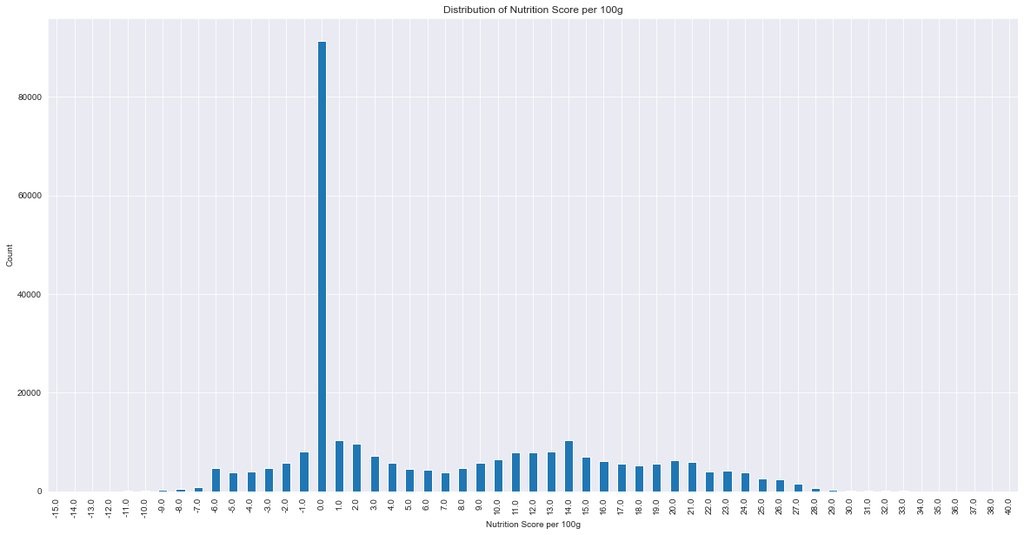

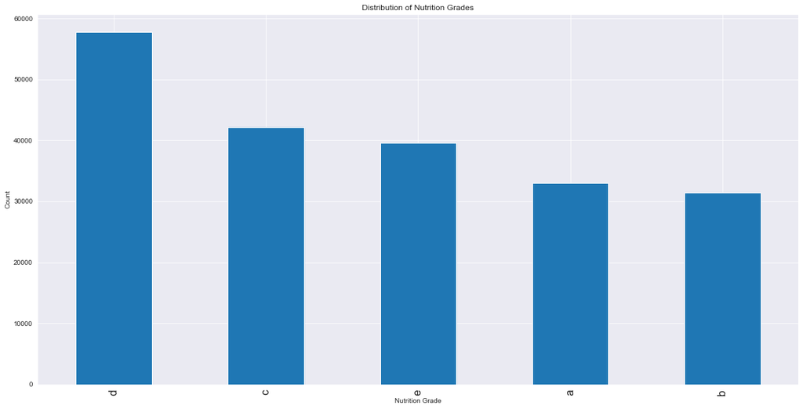

```
    nutrition_score_fr_100g predicted_grade
0                     -15.0               A
1                     -14.0               A
2                     -13.0               A
3                     -12.0               A
4                     -11.0               A
5                     -10.0               A
6                      -9.0               A
7                      -8.0               A
8                      -7.0               A
9                      -6.0               A
10                     -5.0               A
11                     -4.0               A
12                     -3.0               A
13                     -2.0               A
```

[output cut: 48 more lines]

```python
import pandas as pd
import matplotlib.pyplot as plt

# Assuming 'data' is your DataFrame
# Display distribution of 'nutrition_score_fr_100g'
plt.figure(figsize=(20, 10))
data['nutrition_score_fr_100g'].value_counts().sort_index().plot(kind='bar')
plt.title('Distribution of Nutrition Score per 100g')
plt.xlabel('Nutrition Score per 100g')
plt.ylabel('Count')
plt.show()

# Display distribution of 'nutrition_grade_fr'
plt.figure(figsize=(20, 10))
data['nutrition_grade_fr'].value_counts().plot(kind='bar')
plt.title('Distribution of Nutrition Grades')
plt.xlabel('Nutrition Grade')
plt.ylabel('Count')
plt.xticks(fontsize=16)
plt.show()

# Logic to summarize nutrition score to grade
def score_to_grade(score):
    # Adjusted based on detailed data analysis
    if score <= -1:
        return 'A'  # From very low scores up to -1
    elif score <= 2:
        return 'B'  # Covers slightly negative to 2
    elif score <= 10:
        return 'C'  # From 3 to 10
    elif score <= 18:
        return 'D'  # From 11 to 18
    else:
        return 'E'  # Above 18

# Example of how to display unique outcomes without altering DataFrame
unique_scores = data['nutrition_score_fr_100g'].unique()  # Extract unique scores
unique_scores.sort()  # Sort the scores for better visibility

# Map each unique score to its grade
predicted_grades = [score_to_grade(score) for score in unique_scores]

# Create and display a DataFrame for showing these unique mappings
predicted_outcomes = pd.DataFrame({
    'nutrition_score_fr_100g': unique_scores,
    'predicted_grade': predicted_grades
})
print(predicted_outcomes.sort_values('nutrition_score_fr_100g'))

# Explanation of grades based on score ranges
print("\nNutrition Grade Interpretation:")
print("Grade A: Nutrition score ≤ -1")
print("Grade B: Nutrition score between 0 and 2")
print("Grade C: Nutrition score between 3 and 10")
print("Grade D: Nutrition score between 11 and 18")
print("Grade E: Nutrition score > 18")
```

Observation: The Nutri-Score calculation is based on the 'nutrition_score_fr_100g' variable, which is then mapped to the 'nutrition_grade_fr' variable. The score ranges for each grade are as follows:

- Grade A: ≤ -1
- Grade B: 0 to 2
- Grade C: 3 to 10
- Grade D: 11 to 18
- Grade E: > 18
- Problem :
- Reevaluation of the Data: Nutrition Scores Distribution (First Image): The histogram shows a dominant peak at score 0, which would imply that many products fall within this score. Nutrition Grades Distribution (Second Image): Contrary to what would typically be expected, grade B appears to be the least frequent, despite the large number of products that have a score of 0.
- The discrepancy between the expected distribution of grades and the actual distribution of scores suggests that the current data may not accurately reflect the Nutri-Score calculation criteria. This discrepancy could be due to missing or incorrect data in the variables used for the Nutri-Score calculation. Further analysis is required to identify and address these issues.
- Understanding Nutri-Score Discrepancies Across Food Categories

The Nutri-Score system assigns a letter grade from A to E based on the nutritional quality of food and beverages, which can help explain discrepancies in grade distributions observed in the data. Here's a breakdown of how the scoring varies across different food categories:

- Solid Foods:

- Fats (Animal and Vegetable Fats, Nuts, Seeds):

  ```
    Score -6 to Minimum: Grade A
    Score -5 to 2: Grade B
    Score 3 to 10: Grade C
    Score 11 to 18: Grade D
    Score 19 to Maximum: Grade E
  ```

- Beverages:

  ```
    Water: Grade A
    Minimum to 2: Grade B for other beverages
    Score 3 to 6: Grade C for non-water beverages
    Score 7 to 9: Grade D for non-water beverages
    Score 10 to Maximum: Grade E for non-water beverages
  ```

-Key Points:

Category-Specific Scoring: Nutri-Score ranges are specifically adapted to different types of foods and beverages, reflecting their unique nutritional characteristics. Impact on Grade Distribution: These category-specific scores might lead to uneven distributions of Nutri-Score grades across the dataset. For example, solid foods and fats have a lower threshold for achieving a higher grade compared to beverages. Understanding Discrepancies: The observed discrepancies in grade distributions, especially the prevalence of certain grades, could be significantly influenced by the distribution of product types (solids, fats, or beverages) within the dataset.

This categorization clearly illustrates that the distribution of Nutri-Score grades is heavily influenced by the type of product being scored, which is crucial for interpreting any aggregate data analysis involving Nutri-Scores.

# Nutri-Score Calculation Analysis

To calculate the Nutri-Score of food products in France, we focus on a specific set of essential nutritional variables as per the scoring system. The Nutri-Score is calculated based on certain nutritional components of the foods, with points being assigned based on defined thresholds. Below are the main variables used for the Nutri-Score calculation:

1. **Energy (kJ or kcal)** - directly affects the score.
2. **Sugars** - amount of total sugars present in the food.
3. **Saturated Fats** - amount of saturated fats present in the food.
4. **Sodium** - amount of sodium, which is calculated from salt (salt is converted into sodium).
5. **Dietary Fiber** - fiber content of the food.
6. **Proteins** - protein content of the food.
7. **Fruits, Vegetables, Nuts, and Rapeseed/Walnut/Olive Oils** - percentage of these ingredients in the food.

Based on the description of the data structure, here is how we can map them in the DataFrame:

- `energy_100g` : Energy expressed in kilojoules or kilocalories.
- `sugars_100g` : Total sugars amount.
- `saturated_fat_100g` : Amount of saturated fats.
- `sodium_100g` : Amount of sodium.
- `fiber_100g` : Fiber content.
- `proteins_100g` : Protein content.
- `fruits_vegetables_nuts_100g` : Estimated percentage of fruits, vegetables, and nuts.

From your comprehensive description of the DataFrame columns, the following columns are thus essential for the Nutri-Score calculation and should be retained:

- `energy_100g`
- `sugars_100g`
- `saturated_fat_100g`
- `sodium_100g`
- `fiber_100g`
- `proteins_100g`
- `fruits_vegetables_nuts_100g`

All other columns could be removed if your goal is solely to calculate the Nutri-Score and to streamline your DataFrame for analysis specific to this calculation. However, it's important to consider that some of this information might be useful for other analyses or verifications, such as information on allergens, countries of origin, or other nutritional components that could be relevant for more detailed dietary assessments.

[figure not shown]

```python
# list of columns to keep for Nutri-Score calculation
nutri_score_columns = ['nutrition_grade_fr', 'nutrition_score_fr_100g','energy_100g', 'sugars_100g', 'saturated_fat_100g', 'sodium_100g', 'fiber_100g', 'proteins_100g', 'fruits_vegetables_nuts_100g']
# drop irrelevant columns
data_cleaned = data[nutri_score_columns]
# display the first few rows of the cleaned data
data_cleaned.head(20)
```

|  | nutrition_grade_fr | nutrition_score_fr_100g | energy_100g | sugars_100g | saturated_fat_100g | sodium_100g | fiber_100g | proteins_100g | fruits_vegetables_nuts_100g |
| --- | --- | --- | --- | --- | --- | --- | --- | --- | --- |
| 0 | NaN | 0.0 | 0.0 | 0.00 | 0.00 | 0.000 | 0.0 | 0.00 | 0.0 |
| 1 | d | 14.0 | 2243.0 | 14.29 | 28.57 | 0.000 | 3.6 | 3.57 | 0.0 |
| 2 | b | 0.0 | 1941.0 | 17.86 | 0.00 | 0.250 | 7.1 | 17.86 | 0.0 |
| 3 | d | 12.0 | 2540.0 | 3.57 | 5.36 | 0.482 | 7.1 | 17.86 | 0.0 |
| 4 | NaN | 0.0 | 1552.0 | 0.00 | 0.00 | 0.000 | 5.7 | 8.57 | 0.0 |
| 5 | NaN | 0.0 | 1933.0 | 11.54 | 1.92 | 0.000 | 7.7 | 13.46 | 0.0 |
| 6 | NaN | 0.0 | 1490.0 | 0.00 | 0.00 | 0.000 | 0.0 | 8.89 | 0.0 |
| 7 | c | 7.0 | 1833.0 | 15.62 | 4.69 | 0.055 | 9.4 | 14.06 | 0.0 |
| 8 | NaN | 0.0 | 2406.0 | 42.50 | 22.50 | 0.000 | 7.5 | 5.00 | 0.0 |
| 9 | NaN | 0.0 | 3586.0 | 0.00 | 7.14 | 0.000 | 0.0 | 0.00 | 0.0 |
| 10 | NaN | 0.0 | 1393.0 | 0.00 | 0.00 | 0.000 | 12.5 | 22.92 | 0.0 |
| 11 | NaN | 0.0 | 1540.0 | 0.00 | 0.00 | 0.000 | 1.8 | 14.04 | 0.0 |
| 12 | d | 12.0 | 2230.0 | 3.33 | 5.00 | 0.633 | 6.7 | 16.67 | 0.0 |
| 13 | NaN | 0.0 | 2590.0 | 0.00 | 4.76 | 0.038 | 38.1 | 19.05 | 0.0 |
| 14 | NaN | 0.0 | 2536.0 | 0.00 | 9.09 | 0.227 | 15.2 | 30.30 | 0.0 |
| 15 | b | 0.0 | 1824.0 | 21.82 | 1.82 | 0.009 | 9.1 | 14.55 | 0.0 |
| 16 | b | 0.0 | 2632.0 | 3.57 | 3.57 | 0.004 | 10.7 | 14.29 | 0.0 |
| 17 | NaN | 0.0 | 2092.0 | 16.67 | 23.33 | 0.000 | 3.3 | 3.33 | 0.0 |
| 18 | NaN | 0.0 | 1582.0 | 2.22 | 0.00 | 0.000 | 2.2 | 8.89 | 0.0 |
| 19 | a | -6.0 | 1096.0 | 2.38 | 1.19 | 0.010 | 9.5 | 16.67 | 0.0 |

```python
data_cleaned.shape # display the shape of the cleaned data  (rows, columns)
print( "number of products after removing duplicates and irrelevant columns: ", data_cleaned.shape[0])
```

```
number of products after removing duplicates and irrelevant columns:  283629
```

### 2.2 Code for Removing Irrelevant Variables according to usual Data Cleaning (non-domain-specific)

```python
data.describe() # display summary statistics of the data
```

|  | no_nutriments | additives_n | ingredients_from_palm_oil_n | ingredients_from_palm_oil | ingredients_that_may_be_from_palm_oil_n | ingredients_that_may_be_from_palm_oil | nutrition_grade_uk | energy_100g | energy_from_fat_100g | fat_100g | ... | ph_100g | fruits_vegetables_nuts_100g | collagen_meat_protein_ratio_100g | cocoa_100g | chlorophyl_100g | carbon_footprint_100g | nutrition_score_fr_100g | nutrition_score_uk_100g | glycemic_index_100g | water_hardness_100g |
| --- | --- | --- | --- | --- | --- | --- | --- | --- | --- | --- | --- | --- | --- | --- | --- | --- | --- | --- | --- | --- | --- |
| count | 0.0 | 228981.000000 | 228981.000000 | 0.0 | 228981.000000 | 0.0 | 0.0 | 2.836290e+05 | 799.000000 | 222891.000000 | ... | 39.000000 | 283629.000000 | 162.000000 | 913.000000 | 0.0 | 253.000000 | 283629.000000 | 203931.000000 | 0.0 | 0.0 |
| mean | NaN | 1.932671 | 0.019622 | NaN | 0.055987 | NaN | NaN | 9.661433e+02 | 570.726083 | 12.676289 | ... | 6.437251 | 0.326523 | 15.419753 | 49.769003 | NaN | 350.562253 | 6.579073 | 9.046570 | NaN | NaN |
| std | NaN | 2.510138 | 0.140449 | NaN | 0.271883 | NaN | NaN | 6.191852e+03 | 695.899837 | 17.379025 | ... | 2.012432 | 4.553835 | 3.787407 | 18.676788 | NaN | 424.591953 | 8.713704 | 9.190249 | NaN | NaN |
| min | NaN | 0.000000 | 0.000000 | NaN | 0.000000 | NaN | NaN | 0.000000e+00 | 0.000000 | 0.000000 | ... | 0.000000 | 0.000000 | 8.000000 | 6.000000 | NaN | 0.000000 | -15.000000 | -15.000000 | NaN | NaN |
| 25% | NaN | 0.000000 | 0.000000 | NaN | 0.000000 | NaN | NaN | 1.720000e+02 | 51.850000 | 0.000000 | ... | 6.250000 | 0.000000 | 12.000000 | 32.000000 | NaN | 119.700000 | 0.000000 | 1.000000 | NaN | NaN |
| 50% | NaN | 1.000000 | 0.000000 | NaN | 0.000000 | NaN | NaN | 8.370000e+02 | 300.000000 | 5.080000 | ... | 7.000000 | 0.000000 | 15.000000 | 50.000000 | NaN | 200.750000 | 2.000000 | 9.000000 | NaN | NaN |
| 75% | NaN | 3.000000 | 0.000000 | NaN | 0.000000 | NaN | NaN | 1.590000e+03 | 896.000000 | 20.000000 | ... | 7.450000 | 0.000000 | 15.000000 | 65.000000 | NaN | 395.000000 | 14.000000 | 16.000000 | NaN | NaN |
| max | NaN | 31.000000 | 2.000000 | NaN | 6.000000 | NaN | NaN | 3.251373e+06 | 3830.000000 | 714.290000 | ... | 8.400000 | 100.000000 | 25.000000 | 100.000000 | NaN | 2842.000000 | 40.000000 | 40.000000 | NaN | NaN |

8 rows × 106 columns

### 2.3 Conduct a Detailed Univariate Analysis of Each Variable in the Dataset

#### 2.3.1 Statistical Indicators for Quantitative Variables

```python
# Display summary statistics of the quantitative variables only
quantitative_data = data.select_dtypes(include=['number'])  # Select only numeric columns
summary_statistics = quantitative_data.describe()  # Generate descriptive statistics
summary_statistics
```

|  | no_nutriments | additives_n | ingredients_from_palm_oil_n | ingredients_from_palm_oil | ingredients_that_may_be_from_palm_oil_n | ingredients_that_may_be_from_palm_oil | nutrition_grade_uk | energy_100g | energy_from_fat_100g | fat_100g | ... | ph_100g | fruits_vegetables_nuts_100g | collagen_meat_protein_ratio_100g | cocoa_100g | chlorophyl_100g | carbon_footprint_100g | nutrition_score_fr_100g | nutrition_score_uk_100g | glycemic_index_100g | water_hardness_100g |
| --- | --- | --- | --- | --- | --- | --- | --- | --- | --- | --- | --- | --- | --- | --- | --- | --- | --- | --- | --- | --- | --- |
| count | 0.0 | 228981.000000 | 228981.000000 | 0.0 | 228981.000000 | 0.0 | 0.0 | 2.836290e+05 | 799.000000 | 222891.000000 | ... | 39.000000 | 283629.000000 | 162.000000 | 913.000000 | 0.0 | 253.000000 | 283629.000000 | 203931.000000 | 0.0 | 0.0 |
| mean | NaN | 1.932671 | 0.019622 | NaN | 0.055987 | NaN | NaN | 9.661433e+02 | 570.726083 | 12.676289 | ... | 6.437251 | 0.326523 | 15.419753 | 49.769003 | NaN | 350.562253 | 6.579073 | 9.046570 | NaN | NaN |
| std | NaN | 2.510138 | 0.140449 | NaN | 0.271883 | NaN | NaN | 6.191852e+03 | 695.899837 | 17.379025 | ... | 2.012432 | 4.553835 | 3.787407 | 18.676788 | NaN | 424.591953 | 8.713704 | 9.190249 | NaN | NaN |
| min | NaN | 0.000000 | 0.000000 | NaN | 0.000000 | NaN | NaN | 0.000000e+00 | 0.000000 | 0.000000 | ... | 0.000000 | 0.000000 | 8.000000 | 6.000000 | NaN | 0.000000 | -15.000000 | -15.000000 | NaN | NaN |
| 25% | NaN | 0.000000 | 0.000000 | NaN | 0.000000 | NaN | NaN | 1.720000e+02 | 51.850000 | 0.000000 | ... | 6.250000 | 0.000000 | 12.000000 | 32.000000 | NaN | 119.700000 | 0.000000 | 1.000000 | NaN | NaN |
| 50% | NaN | 1.000000 | 0.000000 | NaN | 0.000000 | NaN | NaN | 8.370000e+02 | 300.000000 | 5.080000 | ... | 7.000000 | 0.000000 | 15.000000 | 50.000000 | NaN | 200.750000 | 2.000000 | 9.000000 | NaN | NaN |
| 75% | NaN | 3.000000 | 0.000000 | NaN | 0.000000 | NaN | NaN | 1.590000e+03 | 896.000000 | 20.000000 | ... | 7.450000 | 0.000000 | 15.000000 | 65.000000 | NaN | 395.000000 | 14.000000 | 16.000000 | NaN | NaN |
| max | NaN | 31.000000 | 2.000000 | NaN | 6.000000 | NaN | NaN | 3.251373e+06 | 3830.000000 | 714.290000 | ... | 8.400000 | 100.000000 | 25.000000 | 100.000000 | NaN | 2842.000000 | 40.000000 | 40.000000 | NaN | NaN |

8 rows × 106 columns

```python
# number of modalities for qualitative variables by descending order
data.describe(include='object').T.sort_values('unique', ascending=False)['unique']
```

```
code                                          283628
url                                           283628
product_name                                  221344
ingredients_text                              193922
additives                                     185716
created_t                                     168450
created_datetime                              168448
last_modified_t                               159590
last_modified_datetime                        159590
image_url                                      67655
image_small_url                                67655
brands                                         58784
brands_tags                                    50253
additives_tags                                 39892
additives_fr                                   39892
generic_name                                   37776
categories                                     36105
serving_size                                   24632
categories_fr                                  20755
categories_tags                                20753
labels                                         17609
packaging                                      14135
quantity                                       13358
labels_fr                                      13327
labels_tags                                    13326
allergens                                      12652
packaging_tags                                 11717
emb_codes                                       8329
traces                                          8190
emb_codes_tags                                  8032
manufacturing_places                            7167
manufacturing_places_tags                       6624
purchase_places                                 4984
origins                                         4745
origins_tags                                    4287
traces_tags                                     3517
traces_fr                                       3517
main_category_fr                                3442
main_category                                   3441
creator                                         3329
stores                                          3178
cities_tags                                     2547
first_packaging_code_geo                        1590
countries                                       1319
states                                           865
states_tags                                      865
states_fr                                        865
countries_tags                                   665
countries_fr                                     663
ingredients_that_may_be_from_palm_oil_tags       159
pnns_groups_2                                     42
ingredients_from_palm_oil_tags                    14
pnns_groups_1                                     10
nutrition_grade_fr                                 5
allergens_fr                                       1
cities                                             1
Name: unique, dtype: object
```

#### 2.3.2 Statistical Indicators for Qualitative Variables

```python
# Display summary statistics of the qualitative variables only
qualitative_data = data.select_dtypes(include=['object'])  # Select only object columns
summary_statistics_qualitative = qualitative_data.describe()  # Generate descriptive statistics
summary_statistics_qualitative
```

|  | code | url | creator | created_t | created_datetime | last_modified_t | last_modified_datetime | product_name | generic_name | quantity | ... | nutrition_grade_fr | pnns_groups_1 | pnns_groups_2 | states | states_tags | states_fr | main_category | main_category_fr | image_url | image_small_url |
| --- | --- | --- | --- | --- | --- | --- | --- | --- | --- | --- | --- | --- | --- | --- | --- | --- | --- | --- | --- | --- | --- |
| count | 283628 | 283628 | 283628 | 283629 | 283627 | 283629 | 283629 | 282487 | 50620 | 99976 | ... | 203931 | 283629 | 283629 | 283606 | 283606 | 283606 | 80343 | 283629 | 67655 | 67655 |
| unique | 283628 | 283628 | 3329 | 168450 | 168448 | 159590 | 159590 | 221344 | 37776 | 13358 | ... | 5 | 10 | 42 | 865 | 865 | 865 | 3441 | 3442 | 67655 | 67655 |
| top | 0000000003087 | http://world-fr.openfoodfacts.org/produit/0000... | usda-ndb-import | 1489055829 | 2017-03-09T10:37:09Z | 1439141742 | 2015-08-09T17:35:42Z | Extra Virgin Olive Oil | Pâtes alimentaires au blé dur de qualité supér... | 500 g | ... | d | unknown | unknown | en:to-be-completed, en:nutrition-facts-complet... | en:to-be-completed,en:nutrition-facts-complete... | A compléter,Informations nutritionnelles compl... | en:beverages | unknown | http://fr.openfoodfacts.org/images/products/00... | http://fr.openfoodfacts.org/images/products/00... |
| freq | 1 | 1 | 154589 | 19 | 19 | 31 | 31 | 197 | 190 | 4421 | ... | 57760 | 217927 | 215184 | 153744 | 153744 | 153744 | 5662 | 203286 | 1 | 1 |

4 rows × 56 columns

```python
import numpy as np

# Modalities list for qualitative variables
for col in data.select_dtypes(include='object').columns:
    unique_modalities = data[col].unique()
    # Uncomment the following line to display all unique modalities
    # unique_modalities = data[col].unique()
    if len(unique_modalities) > 5:
        unique_modalities = np.append(unique_modalities[:5], 'all')
    print(f'{col} : {unique_modalities}')
```

```
code : ['0000000003087' '0000000004530' '0000000004559' '0000000016087'
 '0000000016094' 'all']
url : ['http://world-fr.openfoodfacts.org/produit/0000000003087/farine-de-ble-noir-ferme-t-y-r-nao'
 'http://world-fr.openfoodfacts.org/produit/0000000004530/banana-chips-sweetened-whole'
 'http://world-fr.openfoodfacts.org/produit/0000000004559/peanuts-torn-glasser'
 'http://world-fr.openfoodfacts.org/produit/0000000016087/organic-salted-nut-mix-grizzlies'
 'http://world-fr.openfoodfacts.org/produit/0000000016094/organic-polenta-bob-s-red-mill'
 'all']
creator : ['openfoodfacts-contributors' 'usda-ndb-import' 'date-limite-app'
 'canieatthis-app' 'tacinte' 'all']
created_t : ['1474103866' '1489069957' '1489055731' '1489055653' '1489055651' 'all']
created_datetime : ['2016-09-17T09:17:46Z' '2017-03-09T14:32:37Z' '2017-03-09T10:35:31Z'
 '2017-03-09T10:34:13Z' '2017-03-09T10:34:11Z' 'all']
last_modified_t : ['1474103893' '1489069957' '1489055731' '1489055653' '1489055651' 'all']
last_modified_datetime : ['2016-09-17T09:18:13Z' '2017-03-09T14:32:37Z' '2017-03-09T10:35:31Z'
 '2017-03-09T10:34:13Z' '2017-03-09T10:34:11Z' 'all']
product_name : ['Farine de blé noir' 'Banana Chips Sweetened (Whole)' 'Peanuts'
 'Organic Salted Nut Mix' 'Organic Polenta' 'all']
generic_name : [nan 'Laitue en salade' 'Pâtisserie ' 'Flute' 'Pâtisserie' 'all']
quantity : ['1kg' nan '2.46 kg' '230g' '500g' 'all']
packaging : [nan 'plastique' 'Frais' 'Paper,plastic film' 'Frais,plastique' 'all']
packaging_tags : [nan 'plastique' 'frais' 'paper,plastic-film' 'frais,plastique' 'all']
brands : ["Ferme t'y R'nao" nan 'Torn & Glasser' 'Grizzlies' "Bob's Red Mill" 'all']
brands_tags : ['ferme-t-y-r-nao' nan 'torn-glasser' 'grizzlies' 'bob-s-red-mill' 'all']
categories : [nan 'Filet de bœuf' 'Légumes-feuilles'
 'Snacks sucrés,Biscuits et gâteaux,Pâtisseries'
 'Plant-based foods and beverages,Plant-based foods,Cereals and potatoes,Breads'
 'all']
categories_tags : [nan 'fr:filet-de-boeuf'
 'en:plant-based-foods-and-beverages,en:plant-based-foods,en:fresh-foods,en:fruits-and-vegetables-based-foods,en:fresh-plant-based-foods,en:vegetables-based-foods,en:fresh-vegetables,en:leaf-vegetables'
 'en:sugary-snacks,en:biscuits-and-cakes,en:pastries'
 'en:plant-based-foods-and-beverages,en:plant-based-foods,en:cereals-and-potatoes,en:breads'
 'all']
categories_fr : ['unknown' 'Filet-de-boeuf'
 "Aliments et boissons à base de végétaux,Aliments d'origine végétale,Frais,Aliments à base de fruits et de légumes,Aliments à base de plantes frais,Légumes et dérivés,Légumes frais,Légumes-feuilles"
 'Snacks sucrés,Biscuits et gâteaux,Pâtisseries'
 "Aliments et boissons à base de végétaux,Aliments d'origine végétale,Céréales et pommes de terre,Pains"
 'all']
origins : [nan 'Québec' 'France' 'United Kingdom' 'Germany' 'all']
origins_tags : [nan 'quebec' 'france' 'united-kingdom' 'germany' 'all']
```

[output cut: 90 more lines]

```
main_category : [nan 'fr:filet-de-boeuf' 'en:fresh-vegetables' 'en:pastries' 'en:breads'
 'all']
main_category_fr : ['unknown' 'Filet-de-boeuf' 'Légumes frais' 'Pâtisseries' 'Pains' 'all']
image_url : [nan
 'http://fr.openfoodfacts.org/images/products/000/000/002/4600/front.3.400.jpg'
 'http://fr.openfoodfacts.org/images/products/000/000/002/7205/front.3.400.jpg'
 'http://fr.openfoodfacts.org/images/products/000/000/003/6252/front.4.400.jpg'
 'http://fr.openfoodfacts.org/images/products/000/000/003/9259/front.6.400.jpg'
 'all']
image_small_url : [nan
 'http://fr.openfoodfacts.org/images/products/000/000/002/4600/front.3.200.jpg'
 'http://fr.openfoodfacts.org/images/products/000/000/002/7205/front.3.200.jpg'
 'http://fr.openfoodfacts.org/images/products/000/000/003/6252/front.4.200.jpg'
 'http://fr.openfoodfacts.org/images/products/000/000/003/9259/front.6.200.jpg'
 'all']
```

### 2.3.4 Modalities count for qualitative variables

```python
# Modalities count for qualitative variables
for col in data.select_dtypes(include='object').columns:
    print(f'{col} modalities count:')
    print(data[col].value_counts())
    print('\n')  # Adds a newline for better readability between columns
```

```
code modalities count:
code
0000000003087    1
3256220523424    1
3256220610605    1
3256220610544    1
3256220610520    1
                ..
0086854046487    1
0086854047132    1
0086854053645    1
0086854053652    1
999990026839     1
Name: count, Length: 283628, dtype: int64


url modalities count:
url
http://world-fr.openfoodfacts.org/produit/0000000003087/farine-de-ble-noir-ferme-t-y-r-nao             1
http://world-fr.openfoodfacts.org/produit/3256220523424/tomates-farcies-riz-cuisine-u                  1
http://world-fr.openfoodfacts.org/produit/3256220610605/chocolat-noir-noisettes-entieres-u             1
http://world-fr.openfoodfacts.org/produit/3256220610544/chocolat-lait-noisettes-entieres-u             1
http://world-fr.openfoodfacts.org/produit/3256220610520/chocolat-au-lait-croustillant-u                1
                                                                                                      ..
http://world-fr.openfoodfacts.org/produit/0086854046487/harvest-treats-ingles-markets-inc              1
http://world-fr.openfoodfacts.org/produit/0086854047132/juice-from-concentrate-laura-lynn              1
http://world-fr.openfoodfacts.org/produit/0086854053645/club-soda-laura-lynn                           1
http://world-fr.openfoodfacts.org/produit/0086854053652/tonic-water-laura-lynn                         1
http://world-fr.openfoodfacts.org/produit/999990026839/sugar-free-drink-mix-peach-tea-market-pantry    1
Name: count, Length: 283628, dtype: int64


creator modalities count:
creator
usda-ndb-import               154589
openfoodfacts-contributors     32723
kiliweb                        13602
date-limite-app                 8795
openfood-ch-import              8116
                               ...
```

[output cut: 846 more lines]

```

image_small_url modalities count:
image_small_url
http://fr.openfoodfacts.org/images/products/000/000/002/4600/front.3.200.jpg     1
http://fr.openfoodfacts.org/images/products/376/011/376/5605/front.3.200.jpg     1
http://fr.openfoodfacts.org/images/products/376/010/952/8184/front.6.200.jpg     1
http://fr.openfoodfacts.org/images/products/376/010/952/8245/front.21.200.jpg    1
http://fr.openfoodfacts.org/images/products/376/010/952/8306/front.5.200.jpg     1
                                                                                ..
http://fr.openfoodfacts.org/images/products/325/622/002/1210/front.29.200.jpg    1
http://fr.openfoodfacts.org/images/products/325/622/002/3924/front.9.200.jpg     1
http://fr.openfoodfacts.org/images/products/325/622/002/3931/front.5.200.jpg     1
http://fr.openfoodfacts.org/images/products/325/622/002/4020/front.15.200.jpg    1
http://fr.openfoodfacts.org/images/products/997/022/950/1521/front.3.200.jpg     1
Name: count, Length: 67655, dtype: int64
```

## 3 Missing Values Treatment Strategies - CE2

*Overview of strategies used to handle missing data.*

- Step 1: Infer variables with missing values that are necessary for the calculation of nutrition_score_fr_100g (Nutri-Score).
- Step 2: Infer target variable (nutrition_score_fr_100g) only for those with missing values (i.e.nutrition_score_fr_100g) using imputation techniques.

### 3.1 Analyse products that do not have nutrition_score_fr_100g (Nutri-Score) - we will infere the missing values in a second step for the Nutri-Score only for the nutrition_score_fr_100g that have NaN

```python
# Check for missing values in Nutri-Score related columns when 'nutrition_score_fr_100g' is missing
missing_nutri_score = data[data['nutrition_score_fr_100g'].isnull()]

# Calculate the sum of missing values in the specified Nutri-Score related columns
missing_values_count = missing_nutri_score[nutri_score_columns].isnull().sum()

# Print the number of missing values
print(f"Number of missing values in Nutri-Score related columns when 'nutrition_score_fr_100g' is missing: {missing_values_count}")
```

```
Number of missing values in Nutri-Score related columns when 'nutrition_score_fr_100g' is missing: nutrition_grade_fr             0
nutrition_score_fr_100g        0
energy_100g                    0
sugars_100g                    0
saturated_fat_100g             0
sodium_100g                    0
fiber_100g                     0
proteins_100g                  0
fruits_vegetables_nuts_100g    0
dtype: int64
```

```python
import pandas as pd

# Assuming 'data' is your original DataFrame
# List of all qualitative and quantitative variables that must be present
required_columns = [
    'categories_fr', 'pnns_groups_1', 'pnns_groups_2', 'main_category_fr',
    'nutrition_grade_fr', 'nutrition_score_fr_100g', 'energy_100g', 'sugars_100g',
    'saturated_fat_100g', 'sodium_100g', 'fiber_100g', 'proteins_100g',
    'fruits_vegetables_nuts_100g'
]

# Creating a copy of the DataFrame where all specified columns are not null
complete_data = data.dropna(subset=required_columns)

# Displaying the shape of the new DataFrame to verify the number of complete cases
print("Shape of the DataFrame with all required columns present:", complete_data.shape)

# Shape of the DataFrame with all required columns present: (new_rows, new_columns)
complete_data.shape
```

```
Shape of the DataFrame with all required columns present: (203931, 162)
```

```
(203931, 162)
```

```python
# Suppose df is your DataFrame
# You can use the following code to find both the number of unique values and the total count of entities for the column 'nutrition_score_fr_100g'

modalities_count = data['nutrition_score_fr_100g'].value_counts()
num_modalities = len(modalities_count)
total_entities = data['nutrition_score_fr_100g'].count()

print("Number of unique modalities for 'nutrition_score_fr_100g':", num_modalities)
print("Total count of entities for 'nutrition_score_fr_100g':", total_entities)
```

```
Number of unique modalities for 'nutrition_score_fr_100g': 55
Total count of entities for 'nutrition_score_fr_100g': 283629
```

```python
data.shape # display the shape of the data  (rows, columns)
```

```
(283629, 162)
```

```python
# display the count of missing values in each column descending order
data.isnull().sum().sort_values(ascending=False)
```

```
water_hardness_100g                      283629
no_nutriments                            283629
ingredients_from_palm_oil                283629
ingredients_that_may_be_from_palm_oil    283629
nutrition_grade_uk                       283629
                                          ...
sodium_100g                                   0
categories_fr                                 0
pnns_groups_2                                 0
pnns_groups_1                                 0
main_category_fr                              0
Length: 162, dtype: int64
```

### 3.2 Analyze the extent and patterns of missing data across different variables.

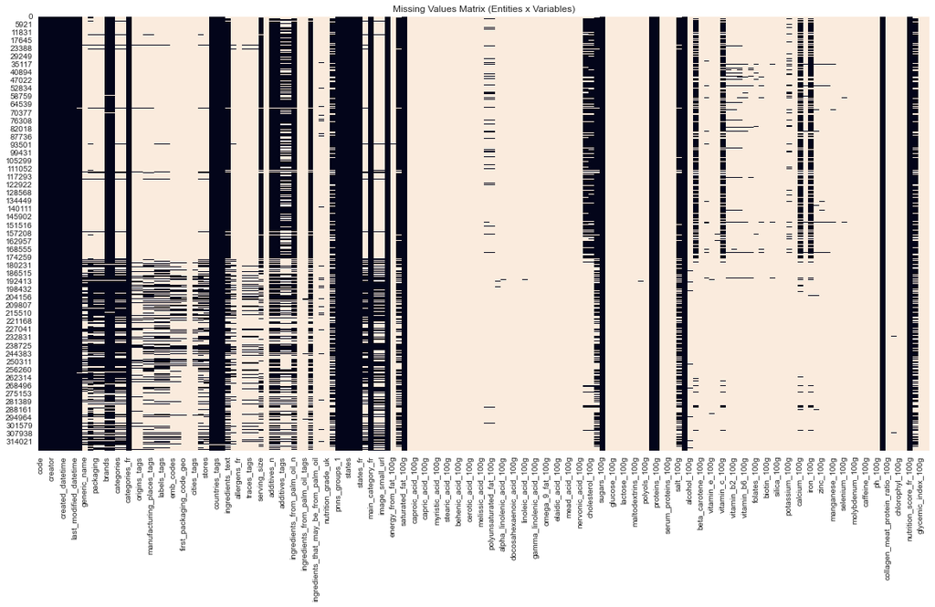

```python
# display missing values in a matrix form (Entities x Variables)
plt.figure(figsize=(20, 10)) # set the figure size
plt.title('Missing Values Matrix (Entities x Variables)') # set the title of the plot
sns.heatmap(data.isna(), cbar=False) # plot the heatmap of missing values, cbar=False to remove color bar, data.isna() to check missing values
plt.show()
```

```python
# display the percentage of missing values in each column and the number of missing values
missing_values = data.isnull().sum() # count the missing values
missing_values = missing_values[missing_values > 0] # select columns with missing values
missing_values_percentage = missing_values / len(data) * 100 # calculate the percentage of missing values
missing_values_df = pd.DataFrame({'Missing Values': missing_values, 'Percentage': missing_values_percentage}) # create a DataFrame
missing_values_df.sort_values(by='Missing Values', ascending=False) # sort the DataFrame by the number of missing values
```

|  | Missing Values | Percentage |
| --- | --- | --- |
| water_hardness_100g | 283629 | 100.000000 |
| no_nutriments | 283629 | 100.000000 |
| mead_acid_100g | 283629 | 100.000000 |
| gondoic_acid_100g | 283629 | 100.000000 |
| elaidic_acid_100g | 283629 | 100.000000 |
| ... | ... | ... |
| states_fr | 23 | 0.008109 |
| created_datetime | 2 | 0.000705 |
| url | 1 | 0.000353 |
| creator | 1 | 0.000353 |
| code | 1 | 0.000353 |

147 rows × 2 columns

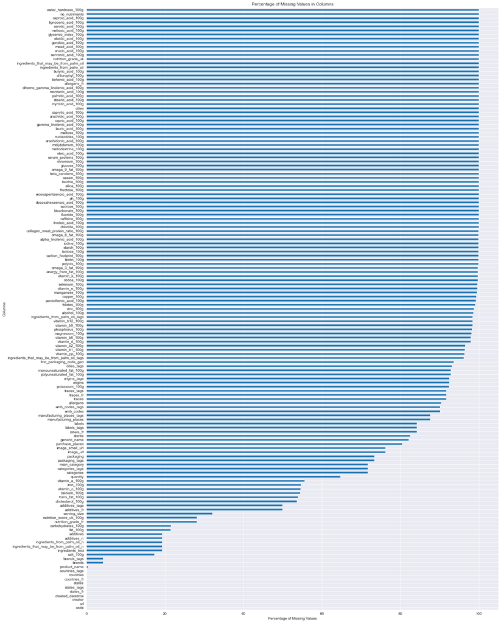

```python
# display the percentage of missing values
plt.figure(figsize=(20, 30)) # set the figure size
plt.title('Percentage of Missing Values in Columns') # set the title of the plot
missing_values_percentage.sort_values().plot(kind='barh') # plot the horizontal bar chart of missing values percentage
plt.xlabel('Percentage of Missing Values') # set the label for x-axis
plt.ylabel('Columns') # set the label for y-axis
plt.show()
```

#### 3.3 Reminder of the columns to keep for Nutri-Score calculation: 'nutrition_score_fr_100g ','energy_100g', 'sugars_100g', 'saturated_fat_100g', 'sodium_100g', 'fiber_100g', 'proteins_100g', 'fruits_vegetables_nuts_100g'

```python
# import matplotlib.pyplot as plt
#
# # Assurez-vous que missing_values_percentage est un DataFrame avec les bonnes colonnes
# # Par exemple:
# # missing_values_percentage = pd.DataFrame({
# #     'column': ['nutrition_grade_fr', 'nutrition_score_fr_100g', 'energy_100g', 'sugars_100g',
# #                'saturated_fat_100g', 'sodium_100g', 'fiber_100g', 'proteins_100g',
# #                'fruits_vegetables_nuts_100g', 'code', 'product_name', 'brands'],
# #     'missing_percentage': [25, 15, 10, 5, 20, 0, 30, 45, 50, 1, 2, 3]
# # }).set_index('column')
#
# # Définissez les colonnes à afficher
# columns_to_display = ['code', 'product_name', 'brands', 'nutrition_grade_fr', 'nutrition_score_fr_100g',
#                       'energy_100g', 'sugars_100g', 'saturated_fat_100g', 'sodium_100g', 'fiber_100g',
#                       'proteins_100g', 'fruits_vegetables_nuts_100g']
#
# # Filtrer pour obtenir seulement les pourcentages de valeurs manquantes pour les colonnes spécifiées
# missing_values_percentage_filtered = missing_values_percentage.loc[columns_to_display]
#
# # Trier les valeurs
# missing_values_percentage_sorted = missing_values_percentage_filtered.sort_values()
#
# # Créer la figure
# plt.figure(figsize=(20, 10))
# plt.title('Percentage of Missing Values in Columns')
#
# # Tracer les barres
# bars = plt.barh(missing_values_percentage_sorted.index, missing_values_percentage_sorted.values, color='blue')
#
# # Colorer certaines barres en rouge
# nutri_score_columns = set(['nutrition_grade_fr', 'nutrition_score_fr_100g', 'energy_100g', 'sugars_100g',
#                            'saturated_fat_100g', 'sodium_100g', 'fiber_100g', 'proteins_100g',
#                            'fruits_vegetables_nuts_100g'])
# for bar, label in zip(bars, missing_values_percentage_sorted.index):
#     if label in nutri_score_columns:
#         bar.set_color('red')
#
# # Ajouter les étiquettes des axes
# plt.xlabel('Percentage of Missing Values')
# plt.ylabel('Columns')
#
# # Afficher le graphique
# plt.show()
```

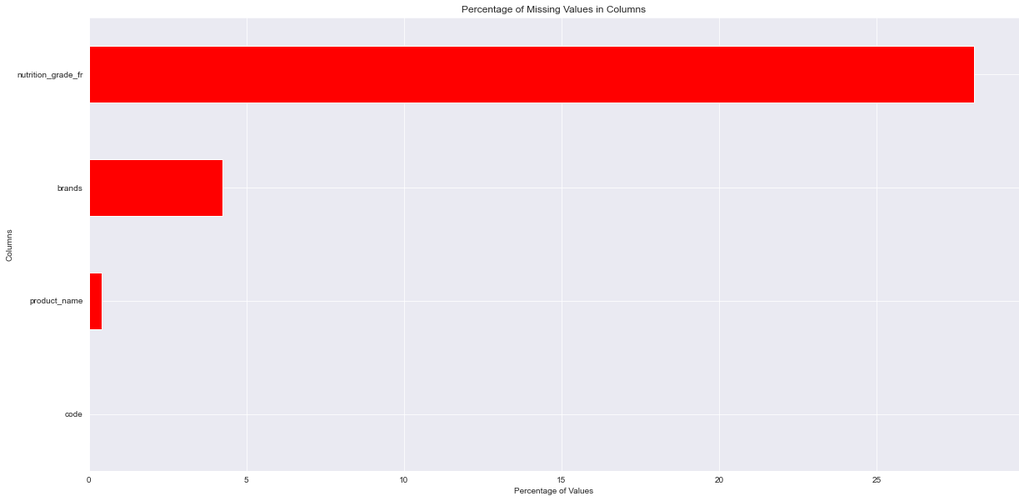

```python
# columns to display in the plot
nutri_score_columns = ['nutrition_grade_fr', 'nutrition_score_fr_100g','energy_100g', 'sugars_100g', 'saturated_fat_100g', 'sodium_100g', 'fiber_100g', 'proteins_100g', 'fruits_vegetables_nuts_100g']
columns_to_display = ['code', 'product_name', 'brands'] + nutri_score_columns

# Filter missing values percentage for the specified columns
missing_values_percentage_filtered = missing_values_percentage[missing_values_percentage.index.isin(columns_to_display)]

# Sort the percentages of missing values from lowest to highest
missing_values_percentage_sorted = missing_values_percentage_filtered.sort_values()

# Create a figure
plt.figure(figsize=(20, 10))

# Title of the plot
plt.title('Percentage of Missing Values in Columns')

# Plot the percentages of missing values
bars = missing_values_percentage_sorted.plot(kind='barh', color='red') # horizontal bar chart with blue bars

# Highlight columns from nutri_score_columns in red
for bar in bars.patches: # iterate over the bars
    if missing_values_percentage_sorted.index[bar.get_x()] in nutri_score_columns: # check if the column is in nutri_score_columns
        bar.set_color('red') # set the color of the bar to red if it's in nutri_score_columns

# Label for the x-axis
plt.xlabel('Percentage of Values')

# Label for the y-axis
plt.ylabel('Columns')

# Show the plot
plt.show()
```

```python
# display the count of missing values in each row of the variables to keep for Nutri-Score calculation
modalities_count = data['nutrition_score_fr_100g'].value_counts()
num_modalities = len(modalities_count)
total_entities = data['nutrition_score_fr_100g'].count()

print("Number of unique modalities for 'nutrition_score_fr_100g':", num_modalities)
print("Total count of entities for 'nutrition_score_fr_100g':", total_entities)
```

```
Number of unique modalities for 'nutrition_score_fr_100g': 55
Total count of entities for 'nutrition_score_fr_100g': 283629
```

### 3.3.1 Analysis of Missing Data for Nutri-Score Calculation Variables

```python
# Assuming 'data' is your DataFrame containing all your data.
# nutri_score_columns is the list of columns necessary for Nutri-Score calculation, excluding 'nutrition_score_fr_100g' since it is used as a base.

nutri_score_columns = [
    'energy_100g', 'sugars_100g', 'saturated_fat_100g',
    'sodium_100g', 'fiber_100g', 'proteins_100g', 'fruits_vegetables_nuts_100g'
]

# Filter the data to include only rows where 'nutrition_score_fr_100g' is not null
data_with_nutrition_grade = data[data['nutrition_score_fr_100g'].notna()]

# Display the count of missing values in each of the other Nutri-Score related columns
missing_counts = data_with_nutrition_grade[nutri_score_columns].isna().sum().sort_values(ascending=False)

# Print the results
print("Missing values count for each Nutri-Score variable when 'nutrition_score_fr_100g' is present:")
print(missing_counts)
```

```
Missing values count for each Nutri-Score variable when 'nutrition_score_fr_100g' is present:
energy_100g                    0
sugars_100g                    0
saturated_fat_100g             0
sodium_100g                    0
fiber_100g                     0
proteins_100g                  0
fruits_vegetables_nuts_100g    0
dtype: int64
```

### 3.3.2 Analyse Data Completeness for Nutri-Score Calculation

```python
# Assuming 'data' is your DataFrame containing all your data.
# nutri_score_columns is the list of columns necessary for Nutri-Score calculation.

nutri_score_columns = [
    'energy_100g', 'sugars_100g',
    'saturated_fat_100g', 'sodium_100g', 'fiber_100g',
    'proteins_100g', 'fruits_vegetables_nuts_100g'
]

# Check the completeness of data for the Nutri-Score calculation.
# This will give us the number of instances in the dataframe where none of the values are NaN.

complete_cases_count = data.dropna(subset=nutri_score_columns).shape[0]

# Print the result.
print(f"Number of complete instances for Nutri-Score calculation: {complete_cases_count}")
```

```
Number of complete instances for Nutri-Score calculation: 283629
```

## Observations

### Conclusions:

The chart underscores the necessity for complete and reliable data to ensure the accuracy of Nutri-Score calculations and subsequent health assessments.

### 3.3.3 Display missing values in a matrix form (Entities x Variables) for all columns

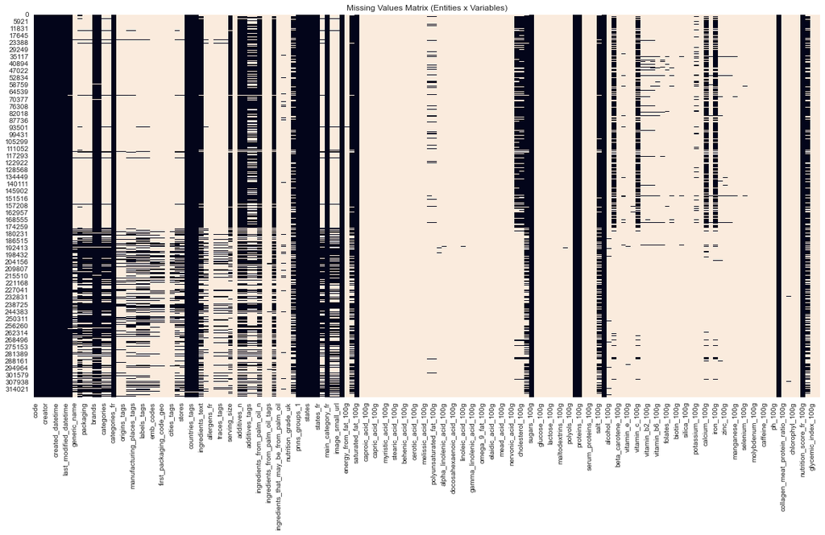

```
Features considered for the prediction model (less than 50% missing values):
['code', 'url', 'creator', 'created_t', 'created_datetime', 'last_modified_t', 'last_modified_datetime', 'product_name', 'brands', 'brands_tags', 'categories_fr', 'countries', 'countries_tags', 'countries_fr', 'ingredients_text', 'serving_size', 'additives_n', 'additives', 'additives_tags', 'additiv…
```

```python
# Display missing values in a matrix form (Entities x Variables)
plt.figure(figsize=(20, 10)) # set the figure size
plt.title('Missing Values Matrix (Entities x Variables)') # set the title of the plot
sns.heatmap(data.isna(), cbar=False) # plot the heatmap of missing values, cbar=False to remove color bar
plt.show()

# Calculate the percentage of missing values for each feature
missing_percentage = data.isna().mean() * 100

# Filter the features that have less than 50% missing values
features_to_consider = missing_percentage[missing_percentage < 50].index.tolist()

# Print the features to consider for further analysis
print(f"Features considered for the prediction model (less than 50% missing values):\n{features_to_consider}")
```

### 3.3.4 Features potentially to considered for the prediction model (with less than 50% missing values) and Nutri-Score features used in the calculation

## Feature Selection for Nutri-Score Calculation and Beyond

This documentation outlines the selected features for the predictive model of the Nutri-Score and discusses the rationale behind retaining additional dataset features. The primary goal is to ensure the Nutri-Score is calculated accurately, hence the inclusion of essential features with less than 50% missing values. Beyond the fundamental Nutri-Score calculation, other features are preserved for their potential to yield valuable insights in further analytical exploration.

```python
# Features considered for the prediction model (with less than 50% missing values)
features_considered = [
    'code', 'url', 'creator', 'created_t', 'created_datetime',
    'last_modified_t', 'last_modified_datetime', 'product_name', 'brands', 'brands_tags',
    'countries', 'countries_tags', 'countries_fr', 'ingredients_text', 'serving_size',
    'additives_n', 'additives', 'additives_tags', 'additives_fr',
    'ingredients_from_palm_oil_n', 'ingredients_that_may_be_from_palm_oil_n',
    'nutrition_grade_fr', 'states', 'states_tags', 'states_fr', 'energy_100g',
    'fat_100g', 'saturated_fat_100g', 'trans_fat_100g', 'cholesterol_100g',
    'carbohydrates_100g', 'sugars_100g', 'fiber_100g', 'proteins_100g',
    'salt_100g', 'sodium_100g', 'vitamin_a_100g', 'vitamin_c_100g',
    'calcium_100g', 'iron_100g', 'nutrition_score_fr_100g', 'nutrition_score_uk_100g'
]

# Features used in Nutri-Score calculation
nutriscore_features = [
    'energy_100g', 'sugars_100g', 'saturated_fat_100g', 'sodium_100g',
    'fiber_100g', 'proteins_100g', 'fruits_vegetables_nuts_100g'
]

# Check if the features considered are part of the Nutri-Score calculation
nutriscore_related = [feature for feature in features_considered if feature in nutriscore_features]

# Create a list of remaining features to consider if they should be kept
remaining_features = [feature for feature in features_considered if feature not in nutriscore_features]

# Print the results
print(f"Features related to Nutri-Score calculation in features considered:\n{nutriscore_related}")
print(f"\nFeatures to reconsider keeping:\n{remaining_features}")
```

```
Features related to Nutri-Score calculation in features considered:
['energy_100g', 'saturated_fat_100g', 'sugars_100g', 'fiber_100g', 'proteins_100g', 'sodium_100g']

Features to reconsider keeping:
['code', 'url', 'creator', 'created_t', 'created_datetime', 'last_modified_t', 'last_modified_datetime', 'product_name', 'brands', 'brands_tags', 'countries', 'countries_tags', 'countries_fr', 'ingredients_text', 'serving_size', 'additives_n', 'additives', 'additives_tags', 'additives_fr', 'ingredie…
```

### 4.Handling Outliers - CE3

- Graphical methods and corresponding code for outlier detection.
- Business analysis of outlier values for Nutri-Score variables.
- Detect outliers using statistical methods or visualizations.
- Determine whether outliers are due to data entry errors or are genuine extreme values.

#### 4.1 Visualizations for Outlier Detection in the domain of Nutri-Score Calculation

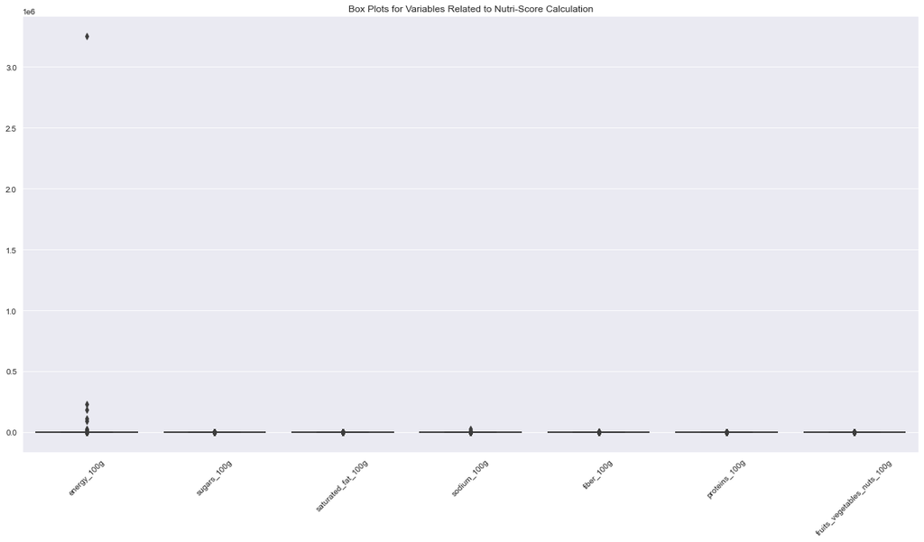

```python
# Display box plots for the variables to keep for Nutri-Score calculation
plt.figure(figsize=(20, 10)) # set the figure size
plt.title('Box Plots for Variables Related to Nutri-Score Calculation') # set the title of the plot
sns.boxplot(data=data[nutri_score_columns]) # plot the box plots for the variables related to Nutri-Score calculation
plt.xticks(rotation=45) # rotate the x-axis labels for better visibility
plt.show() # show the plot
```

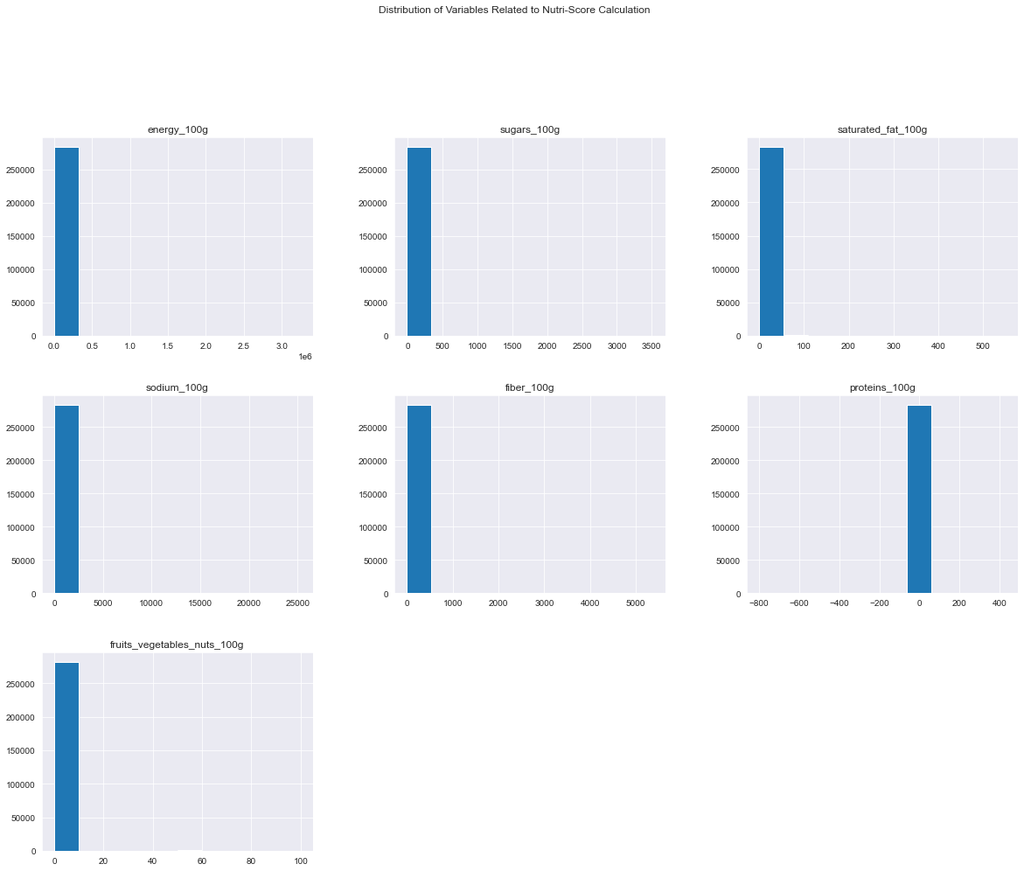

```python
# Display the distribution of the variables using histograms
data[nutri_score_columns].hist(figsize=(20, 15)) # plot histograms for the variables related to Nutri-Score calculation
plt.suptitle('Distribution of Variables Related to Nutri-Score Calculation', y=1.02) # set the title of the plot
plt.show() # show the plot
```

### 4.1.1 Business Analysis of Outlier Values for Nutri-Score Variables

#### Business Study: Based on internet research and industry standards:

- **Energy (energy_100g)**:
  - The most calorific source, fats, contain about 3700 kJ per 100g.
  - **Outliers**: Values exceeding this threshold can be considered outliers.
- **Sugars (sugars_100g)**:
  - A product cannot contain more than 100g of sugars per 100g (theoretically possible but highly improbable, except for pure sugar products).
  - **Outliers**: Values exceeding 100g per 100g.
- **Saturated Fat (saturated_fat_100g)**:
  - It is rare for saturated fats to exceed 100g per 100g, even in very fatty foods.
  - **Outliers**: Values exceeding 100g per 100g.
- **Sodium (sodium_100g)**:
  - Very high concentrations of sodium are unusual. WHO recommendations suggest less than 2g of sodium per day, which is approximately 5g of salt.
  - **Outliers**: Values exceeding 5g per 100g (extremely rare and potentially unviable).
- **Fiber (fiber_100g)**:
  - The fiber content logically cannot exceed 100g per 100g.
  - **Outliers**: Values exceeding 100g per 100g.
- **Proteins (proteins_100g)**:
  - Similar to other macronutrients, the protein content cannot exceed 100g per 100g.
  - **Outliers**: Values exceeding 100g per 100g.
- **Fruits, Vegetables, Nuts (fruits_vegetables_nuts_100g)**:
  - For mixes or processed products, it is rare for this value to exceed 100%.
  - **Outliers**: Values exceeding 100%, which would indicate a data entry or calculation error.

#### Recommendations:

- Values identified as outliers should be individually verified and corrected or excluded from the analysis depending on the context.
- Collaboration with nutrition experts is recommended to validate these thresholds and understand their impact on Nutri-Score analysis.

### 4.1.2 Cleaning Outliers in Nutri-Score Variables from a Business Perspective

```python
# Optionally, check the data types to confirm all are numeric
print(data[nutri_score_columns].dtypes)
```

```
energy_100g                    float64
sugars_100g                    float64
saturated_fat_100g             float64
sodium_100g                    float64
fiber_100g                     float64
proteins_100g                  float64
fruits_vegetables_nuts_100g    float64
dtype: object
```

### 4.1.3 Box Plot Visualization for Outlier Detection for energy_100g since it has a significantly higher range than other variables

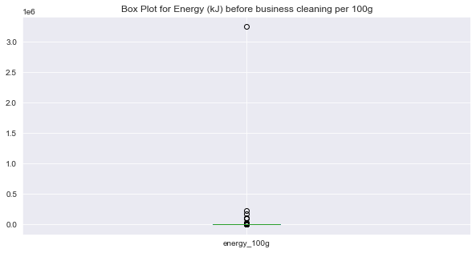

```python
## boxplot for energy_100g
data['energy_100g'].plot.box(figsize=(10, 5))
plt.title('Box Plot for Energy (kJ) before business cleaning per 100g')
plt.show()
```

### 4.1.4 Definition of Maximum Thresholds for Nutri-Score Variables According to Business Study

```python
# Define maximum thresholds and minimum threshold of 0 for each variable according to business study
thresholds = {
    'energy_100g': 3700,  # max energy from fats in kJ
    'sugars_100g': 100,   # max sugar content in g
    'saturated_fat_100g': 100,  # max saturated fat in g
    'sodium_100g': 5,     # equivalent to about 12.5g of salt
    'fiber_100g': 100,    # max fiber content in g
    'proteins_100g': 100, # max protein content in g
    'fruits_vegetables_nuts_100g': 100  # max percentage for fruits, veggies, nuts
}

# Function to clean outliers with both upper and lower bounds
def clean_outliers(df, column, upper_threshold):
    df[column] = df[column].clip(lower=0, upper=upper_threshold)  # Using clip to set both min (0) and max thresholds
    return df

# Apply cleaning of outliers for each specified column
for column, upper_threshold in thresholds.items():
    data = clean_outliers(data, column, upper_threshold)

# Print min, max, and mean values for each column after cleaning
for column in thresholds.keys():
    min_val = data[column].min()
    max_val = data[column].max()
    mean_val = data[column].mean()
    print(f"{column}: Min={min_val}, Max={max_val}, Mean={mean_val:.2f}")

# Define the path for saving the cleaned data in the 'data' subfolder
save_path = os.path.join(base_path, 'data/')  # Ensure this path points to the data directory

# Save the cleaned data to a new CSV file in the 'data' subfolder
output_file_path = os.path.join(save_path, 'cleaned_data_from_business_outlier.csv')
data.to_csv(output_file_path, index=False)
```

```
energy_100g: Min=0.0, Max=3700.0, Mean=951.19
sugars_100g: Min=0.0, Max=100.0, Mean=12.60
saturated_fat_100g: Min=0.0, Max=100.0, Mean=3.82
sodium_100g: Min=0.0, Max=5.0, Mean=0.38
fiber_100g: Min=0.0, Max=100.0, Mean=1.86
proteins_100g: Min=0.0, Max=100.0, Mean=5.98
fruits_vegetables_nuts_100g: Min=0.0, Max=100.0, Mean=0.33
```

## Automation of Data Cleaning Process - CE5

In the project section titled "Definition of Maximum Thresholds for Nutri-Score Variables According to Business Study," we have implemented an automation process using appropriate functions and methods to clean outliers in the dataset.

The provided code defines maximum thresholds for Nutri-Score variables based on a business study and applies a cleaning function to remove outliers beyond these thresholds.

### Key Steps:

- **Threshold Definition**: Maximum thresholds are defined for Nutri-Score variables such as energy content, sugar content, saturated fat, sodium, fiber, proteins, and percentage of fruits, vegetables, and nuts.
- **Cleaning Function**: A custom function is created to clean outliers in each specified column using upper bounds defined by the thresholds.
- **Automation**: The cleaning function is applied iteratively to each column in the dataset, ensuring consistency and efficiency in outlier removal.
- **Result Validation**: After cleaning, summary statistics including minimum, maximum, and mean values are printed for each column to verify the effectiveness of the cleaning process.
- **Data Export**: The cleaned dataset is saved to a new CSV file for further analysis and use in the project.

This automation of the data cleaning process demonstrates the application of functions and methods to efficiently handle data preprocessing tasks, ensuring data quality and consistency in accordance with project requirements.

```python
#Display data.shape in data.to_csv('../data/cleaned_data_from_business_outlier.csv', index=False)
data.shape
```

```
(283629, 162)
```

### 4.1.5 Visualizations for Outlier Detection in Nutri-Score Variables after Business Cleaning -The 'energy_100g' column is omitted from the nutri_score_columns list. This adjustment ensures better visualization since 'energy_100g' has a significantly higher range than other variables, which can distort the box plot visualization.

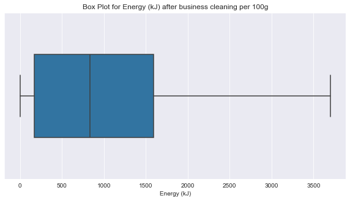

```python
### boxplot for energy_100g after business cleaning
plt.figure(figsize=(10, 5))  # Set figure size before plotting
sns.boxplot(x=data['energy_100g'], width=0.5)  # Plot boxplot with seaborn
plt.title('Box Plot for Energy (kJ) after business cleaning per 100g')
plt.xlabel('Energy (kJ)')
plt.show()
```

### 4.1.6 Box Plots for Nutri-Score Variables After Business Outlier Cleaning excluding 'energy_100g'

```
../data\cleaned_data_from_business_outlier.csv
```

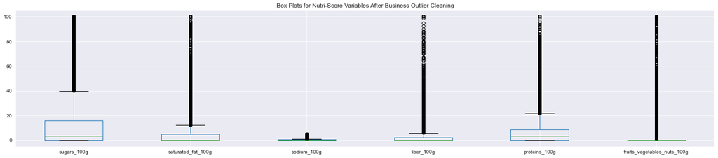

```python
# Assuming 'base_path' is already defined somewhere in your notebook as the root folder path
data_path = os.path.join(base_path, 'data', 'cleaned_data_from_business_outlier.csv')

print(data_path)

# Load your dataset using the correct path
data = pd.read_csv(data_path, low_memory=False)  # Use the variable 'data_path'

# Define the columns relevant to Nutri-Score calculations, excluding 'energy_100g'
nutri_score_columns = [
    'sugars_100g', 'saturated_fat_100g',
    'sodium_100g', 'fiber_100g', 'proteins_100g',
    'fruits_vegetables_nuts_100g'
]

# Create boxplots for the specified Nutri-Score columns
data[nutri_score_columns].boxplot(figsize=(25, 5))

# Set the title for the boxplots
plt.title('Box Plots for Nutri-Score Variables After Business Outlier Cleaning')

# Show the plot
plt.show()
```

### 4.1.7 Statistical Treatment

#### Ensure Consistent Data Types for Nutri-Score Columns only for checking the data types

```python
# Construct the full path to the dataset
data_path = os.path.join(base_path, 'data', 'cleaned_data_from_business_outlier.csv')

# Load your dataset with the low_memory option set to False to better handle mixed data types
data = pd.read_csv(data_path, low_memory=False)

# Define the columns relevant to Nutri-Score calculations
nutri_score_columns = [
    'energy_100g', 'sugars_100g', 'saturated_fat_100g',
    'sodium_100g', 'fiber_100g', 'proteins_100g',
    'fruits_vegetables_nuts_100g'
]

# Convert all specified columns to numeric, handling non-numeric entries
for column in nutri_score_columns:
    data[column] = pd.to_numeric(data[column], errors='coerce')  # Convert to numeric, coerce errors to NaN

# Optionally, check the data types to confirm all are numeric
print(data[nutri_score_columns].dtypes)  # Display the data types of the Nutri-Score columns

# Save the cleaned data back to a CSV file in the 'data' directory
output_path = os.path.join(base_path, 'data', 'cleaned_data_from_business_outlier.csv')
data.to_csv(output_path, index=False)  # Save the data to the same file or specify a new file

print(f"Data with consistent types for Nutri-Score columns saved to '{output_path}'")
```

```
energy_100g                    float64
sugars_100g                    float64
saturated_fat_100g             float64
sodium_100g                    float64
fiber_100g                     float64
proteins_100g                  float64
fruits_vegetables_nuts_100g    float64
dtype: object
Data with consistent types for Nutri-Score columns saved to '../data\cleaned_data_from_business_outlier.csv'
```

```python
data.shape
```

```
(283629, 162)
```

#### Outlier Cleaning Using the IQR Method

```python
import os
import pandas as pd

# Construct the full path to the cleaned data file
data_path = os.path.join(base_path, 'data', 'cleaned_data_from_business_outlier.csv')

# Load the cleaned data
data = pd.read_csv(data_path, low_memory=False)

# Create a copy of the DataFrame to work on
data_copy = data.copy()

# Define Nutri-Score relevant columns
nutri_score_columns = [
    'energy_100g', 'sugars_100g', 'saturated_fat_100g',
    'sodium_100g', 'fiber_100g', 'proteins_100g',
    'fruits_vegetables_nuts_100g'
]

# Checking for NaN values in the dataset
print("NaN counts in Nutri-Score columns before any operations:")
print(data_copy[nutri_score_columns].isna().sum())

# Initialize a mask for rows to keep, the mask is used to filter out the outliers
mask = pd.Series(True, index=data_copy.index)

# Calculate IQR for each column and update the mask to filter out the outliers
for column in nutri_score_columns:
    Q1 = data_copy[column].quantile(0.25)
    Q3 = data_copy[column].quantile(0.75)
    IQR = Q3 - Q1
    lower_bound = Q1 - 1.5 * IQR  # Adjusting the multiplier to 1.5
    upper_bound = Q3 + 1.5 * IQR  # Adjusting the multiplier to 1.5
    column_mask = (data_copy[column] >= lower_bound) & (data_copy[column] <= upper_bound)
    mask &= column_mask

# Apply the mask to the dataframe copy
filtered_data = data_copy[mask]

# Display the number of original and filtered rows
print(f"Original data rows: {data.shape[0]}, Filtered data rows: {filtered_data.shape[0]}")
```

```
NaN counts in Nutri-Score columns before any operations:
energy_100g                    0
sugars_100g                    0
saturated_fat_100g             0
sodium_100g                    0
fiber_100g                     0
proteins_100g                  0
fruits_vegetables_nuts_100g    0
dtype: int64
Original data rows: 283629, Filtered data rows: 186919
```

```python
# Display data.shape and check if the code above change the dataframe
data.shape
```

```
(283629, 162)
```

### Alternative Statistical Method for Outlier Detection

Given these observations, exploring an alternative statistical method for outlier detection seems necessary. Using the median and standard deviation could be more appropriate for this dataset. This approach typically provides a more robust handling of outliers, especially in distributions that are not severely skewed. It tends to be less sensitive to extreme values, thus preserving more of the dataset while still effectively filtering out true outliers.

#### Outlier cleaning based on the median and standard deviation

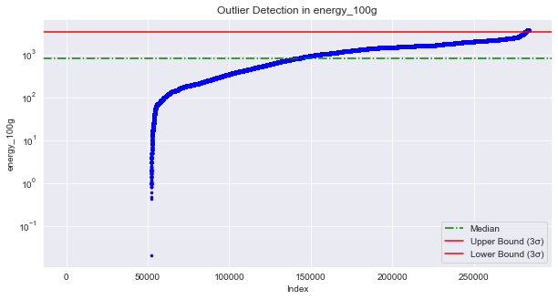

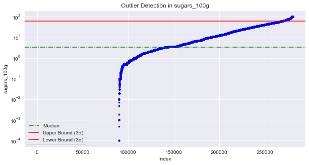

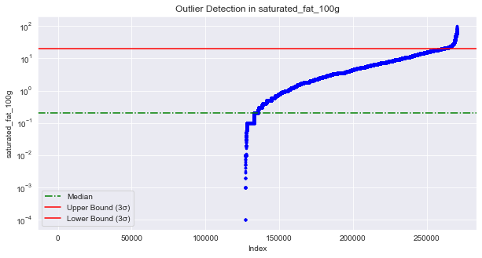

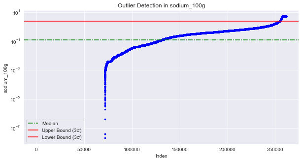

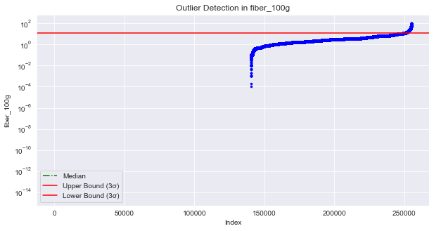

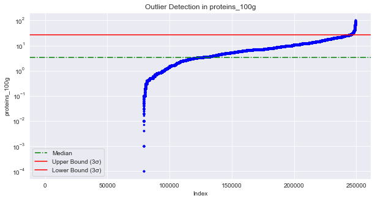

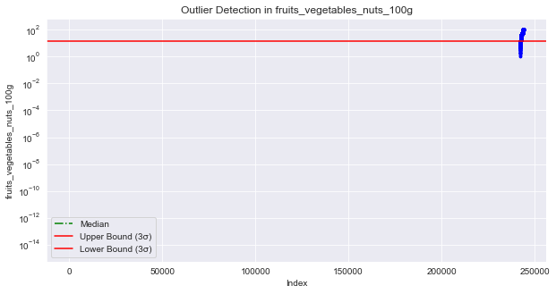

```
Remaining data rows after outlier removal: 242477
```

```python
import pandas as pd
import numpy as np
import matplotlib.pyplot as plt

# Assuming data is loaded into a DataFrame `data`
# Create a copy of the DataFrame to preserve the original data
data_copy = data.copy()

# Define the features for which you want to detect outliers
sigma_features = [
    'energy_100g', 'sugars_100g', 'saturated_fat_100g',
    'sodium_100g', 'fiber_100g', 'proteins_100g',
    'fruits_vegetables_nuts_100g'
]

# Initialize lists to store the median and standard deviation for each feature
medians = []
sigmas = []

# Calculate median and trimmed standard deviation for each feature
for feature in sigma_features:
    valid_data = data_copy[feature].dropna()  # Work with non-NA values for accurate calculations
    median = valid_data.median()
    sorted_data = valid_data.sort_values()
    sigma = np.std(sorted_data[:-25])  # Exclude top 25 extreme values for std calculation

    medians.append(median)
    sigmas.append(sigma)

    # Visualization
    plt.figure(figsize=(10, 5))
    plt.plot(sorted_data.values, 'b.', markersize=5)
    plt.axhline(y=median, color='g', linestyle='dashdot', label='Median')
    plt.axhline(y=median + 3 * sigma, color='r', linestyle='-', label='Upper Bound (3σ)')
    plt.axhline(y=median - 3 * sigma, color='r', linestyle='-', label='Lower Bound (3σ)')
    plt.title(f'Outlier Detection in {feature}')
    plt.xlabel('Index')
    plt.ylabel(feature)
    plt.yscale('log')  # Use logarithmic scale if data range is large
    plt.legend()
    plt.grid(True)
    plt.show()

    # Apply the calculated bounds to filter outliers
    data_copy = data_copy[(data_copy[feature] >= (median - 3 * sigma)) & (data_copy[feature] <= (median + 3 * sigma))]

# Print the remaining rows in the data copy after outlier removal
print(f"Remaining data rows after outlier removal: {data_copy.shape[0]}")
```

### Analysis of Outlier Removal Results with Median and Standard Deviation Method

```python
# Display data.shape
data.shape
```

```
(283629, 162)
```

### 5 Impute Missing Values: Strategies - CE2

*Overview of strategies used to handle missing data.*

- Step 1: Infer variables with missing values that are necessary for the calculation of nutrition_score_fr_100g (Nutri-Score).
- Step 2: Infer target variable (nutrition_score_fr_100g) only for those with missing values.

```python
# Calculate the total percentage of missing values in the dataset
total_percentage_missing_value = (data.isna().sum().sum() / data.size)
print("Total percentage of missing values in the dataset =", total_percentage_missing_value)
```

```
Total percentage of missing values in the dataset = 0.7217236357580492
```

```python
# Display the percentage and number of missing values for 'nutrition_score_fr_100g' in the dataset from the previous step 'cleaned_data_from_business_outliers.csv'
missing_values_percentage = data['nutrition_score_fr_100g'].isnull().mean() * 100
missing_values_count = data['nutrition_score_fr_100g'].isnull().sum()
print (f"Percentage of missing values for 'nutrition_score_fr_100g': {missing_values_percentage:.2f}%")
print (f"Number of missing values for 'nutrition_score_fr_100g': {missing_values_count}")
```

```
Percentage of missing values for 'nutrition_score_fr_100g': 0.00%
Number of missing values for 'nutrition_score_fr_100g': 0
```

### Implementation Sequence and Considerations

- **Median**: Best for numerical data that is not heavily skewed.
- **Zero**: Useful for categorical data encoded as numbers or counters where zero is a valid value.
- **KNN Imputation**: Effective when the dataset is sufficiently large and missing values are relatively few. Good for complex patterns but computationally expensive.
- **Iterative Imputer**: Useful for multivariate data where each attribute helps predict others. Assumes linear relationships.
- **Deletion**: Simplest, but only viable when missing data is minimal and randomly distributed.

Each method should be chosen based on the nature of the data and the specific requirements of the analysis or the predictive modeling to be performed.

```python
# Assuming 'data' is your DataFrame containing all your data.
# nutri_score_columns is the list of columns necessary for Nutri-Score calculation, excluding 'nutrition_score_fr_100g' since it is used as a base.

nutri_score_columns = [
    'energy_100g', 'sugars_100g', 'saturated_fat_100g',
    'sodium_100g', 'fiber_100g', 'proteins_100g', 'fruits_vegetables_nuts_100g'
]

# Filter the data to include only rows where 'nutrition_score_fr_100g' is not null
data_with_nutrition_grade = data[data['nutrition_score_fr_100g'].notna()]

# Display the count of missing values in each of the other Nutri-Score related columns
# Sort the counts of missing values from highest to lowest
missing_counts = data_with_nutrition_grade[nutri_score_columns].isna().sum().sort_values(ascending=False)

# Print the results
print("Missing values count for each Nutri-Score variable when 'nutrition_score_fr_100g' is present, sorted from highest to lowest:")
print(missing_counts)
```

```
Missing values count for each Nutri-Score variable when 'nutrition_score_fr_100g' is present, sorted from highest to lowest:
energy_100g                    0
sugars_100g                    0
saturated_fat_100g             0
sodium_100g                    0
fiber_100g                     0
proteins_100g                  0
fruits_vegetables_nuts_100g    0
dtype: int64
```

```python
data.shape # display the shape of the data  (rows, columns)
```

```
(283629, 162)
```

### 5.1 Imputation Based on Median Values - CE2 - Median Imputation on data Where Nutri-Score Is not Present

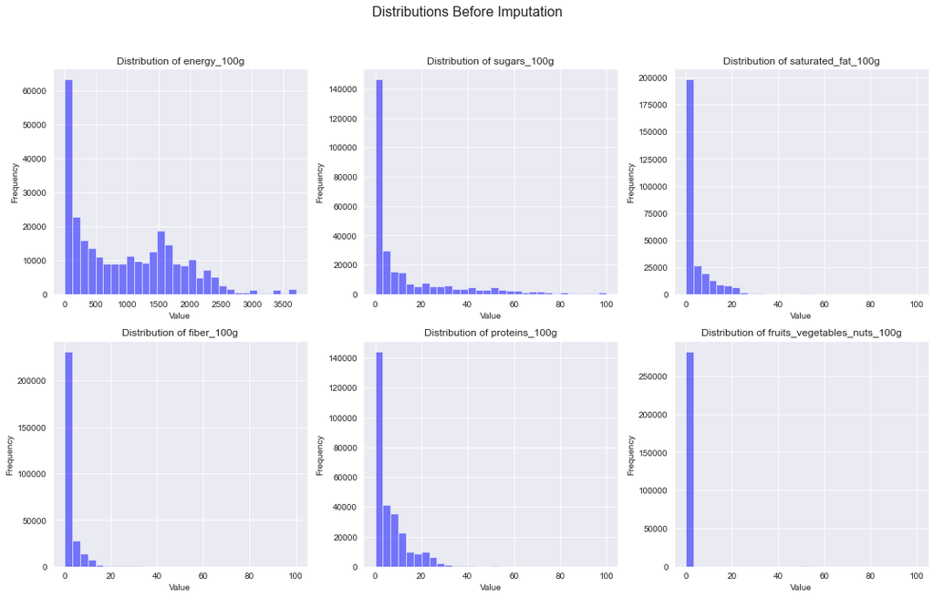

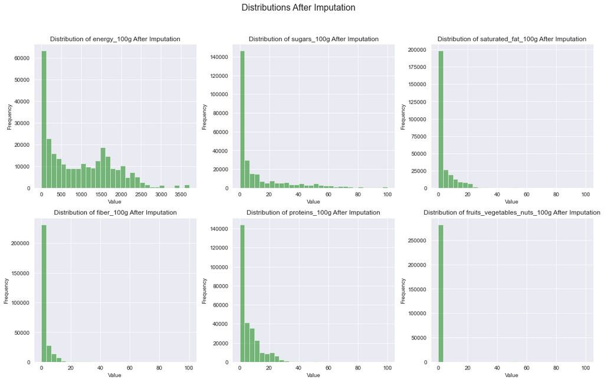

```
         energy_100g    sugars_100g  saturated_fat_100g     fiber_100g  \
count  283629.000000  283629.000000       283629.000000  283629.000000
mean      951.190138      12.599222            3.821814       1.857766
std       834.743876      19.823769            7.221325       3.982990
min         0.000000       0.000000            0.000000       0.000000
25%       172.000000       0.000000            0.000000       0.000000
50%       837.000000       3.230000            0.200000       0.000000
75%      1590.000000      16.000000            5.000000       2.400000
max      3700.000000     100.000000          100.000000     100.000000

       proteins_100g  fruits_vegetables_nuts_100g
count  283629.000000                283629.000000
mean        5.984046                     0.326523
std         7.903332                     4.553835
min         0.000000                     0.000000
25%         0.000000                     0.000000
50%         3.330000                     0.000000
75%         8.770000                     0.000000
max       100.000000                   100.000000
```

```python
import pandas as pd

# Define the group keys in hierarchical order
hierarchy = [
    ['categories_fr', 'main_category_fr', 'pnns_groups_1', 'pnns_groups_2'],  # Most specific level
    ['categories_fr', 'main_category_fr', 'pnns_groups_1'],  # Slightly more general
    ['categories_fr', 'main_category_fr'],  # More general
    ['categories_fr'],  # Most general category only
]

# Quantitative columns to impute
quantitative_columns = [
    'energy_100g', 'sugars_100g', 'saturated_fat_100g',
    'fiber_100g', 'proteins_100g', 'fruits_vegetables_nuts_100g'
]

# Define the columns relevant to Nutri-Score calculation
nutri_score_columns = [
    'energy_100g', 'sugars_100g', 'saturated_fat_100g',
    'fiber_100g', 'proteins_100g', 'fruits_vegetables_nuts_100g'
]

# Visualize distributions before imputation
fig, axes = plt.subplots(nrows=2, ncols=3, figsize=(15, 10))  # Adjusted subplot grid size to match number of columns
fig.suptitle('Distributions Before Imputation', fontsize=16)
for ax, column in zip(axes.flatten(), nutri_score_columns): # Use nutri_score_columns for consistency
    data[column].hist(ax=ax, bins=30, alpha=0.5, color='blue') # Use data[column] for consistency
    ax.set_title(f'Distribution of {column}') # Use f-string for consistency
    ax.set_xlabel('Value') # Use consistent axis labels
    ax.set_ylabel('Frequency') # Use consistent axis labels
plt.tight_layout(rect=[0, 0.03, 1, 0.95]) # Adjusted layout for better spacing
plt.show() # Display the plot


# Prepare to store medians in a DataFrame that we'll use for imputation
medians = pd.DataFrame() # Initialize an empty DataFrame

for level in hierarchy:
    # Compute medians for current grouping level in base_data_for_method
    group_medians = base_data_for_method.groupby(level)[quantitative_columns].median().reset_index()

    # Rename median columns to indicate their level (makes it easier to understand the source level of imputation)
    group_medians.columns = [col if col in level else f'{col}_median_level_{len(level)}' for col in group_medians.columns]

    # Merge these medians with the main data DataFrame if medians are not already defined
    if medians.empty:
        medians = group_medians
    else:
        # Merge only where medians are not already available (NaNs will be filled progressively)
        medians = pd.merge(medians, group_medians, on=level, how='left') # Left join to keep all rows in medians

# Apply the hierarchical medians to the main data DataFrame
data = pd.merge(data, medians, on=['categories_fr', 'main_category_fr', 'pnns_groups_1', 'pnns_groups_2'], how='left') # Left join to keep all rows in data

# Condition where nutrition_score_fr_100g is NaN
condition = data['nutrition_score_fr_100g'].isnull() # Define the condition for missing values in the target column

# Impute missing values from the most specific to the most general median available
for column in quantitative_columns: # Iterate over the quantitative columns
    data.loc[condition, column] = data.apply( # Impute missing values based on condition
        lambda row: row[f'{column}_median_level_4'] if pd.isna(row[column]) else ( # Use the highest level median if NaN
            row[f'{column}_median_level_3'] if pd.isna(row[column]) else ( # Use the next level median if NaN
                row[f'{column}_median_level_2'] if pd.isna(row[column]) else ( # Use the next level median if NaN
                    row[f'{column}_median_level_1'] if pd.isna(row[column]) else row[column] # Use the lowest level median if NaN
                )
            )
        ),
        axis=1 # Apply the lambda function row-wise
    )

# Visualize distributions after imputation
fig, axes = plt.subplots(nrows=2, ncols=3, figsize=(15, 10))  # Keep consistent layout with pre-imputation plot
fig.suptitle('Distributions After Imputation', fontsize=16) # Set the title for the plot
for ax, column in zip(axes.flatten(), nutri_score_columns): # Use nutri_score_columns for consistency
    data[column].hist(ax=ax, bins=30, alpha=0.5, color='green') # Use data[column] for consistency
    ax.set_title(f'Distribution of {column} After Imputation') # Use f-string for consistency
    ax.set_xlabel('Value') # Use consistent axis labels
    ax.set_ylabel('Frequency') # Use consistent axis labels
plt.tight_layout(rect=[0, 0.03, 1, 0.95]) # Adjusted layout for better spacing
plt.show() # Display the plot


# Clean up: Remove the temporary median columns
data.drop(columns=[col for col in data.columns if 'median_level_' in col], inplace=True) # Drop the median columns from the data

# Optionally show some results to verify
print(data[quantitative_columns].describe()) # Display summary statistics for the quantitative columns
```

```
Data preview before imputation for Nutri-Score variables:
   energy_100g  sugars_100g  saturated_fat_100g  sodium_100g  fiber_100g  \
0          0.0         0.00                0.00        0.000         0.0
1       2243.0        14.29               28.57        0.000         3.6
2       1941.0        17.86                0.00        0.250         7.1
3       2540.0         3.57                5.36        0.482         7.1
4       1552.0         0.00                0.00        0.000         5.7

   proteins_100g  fruits_vegetables_nuts_100g
0           0.00                          0.0
1           3.57                          0.0
2          17.86                          0.0
3          17.86                          0.0
4           8.57                          0.0
Statistical summary before imputation:
         energy_100g    sugars_100g  saturated_fat_100g    sodium_100g  \
count  283629.000000  283629.000000       283629.000000  283629.000000
mean      951.190138      12.599222            3.821814       0.375620
std       834.743876      19.823769            7.221325       0.746312
min         0.000000       0.000000            0.000000       0.000000
25%       172.000000       0.000000            0.000000       0.000000
50%       837.000000       3.230000            0.200000       0.098000
75%      1590.000000      16.000000            5.000000       0.464000
max      3700.000000     100.000000          100.000000       5.000000

          fiber_100g  proteins_100g  fruits_vegetables_nuts_100g
count  283629.000000  283629.000000                283629.000000
mean        1.857766       5.984046                     0.326523
std         3.982990       7.903332                     4.553835
min         0.000000       0.000000                     0.000000
25%         0.000000       0.000000                     0.000000
50%         0.000000       3.330000                     0.000000
75%         2.400000       8.770000                     0.000000
max       100.000000     100.000000                   100.000000
```

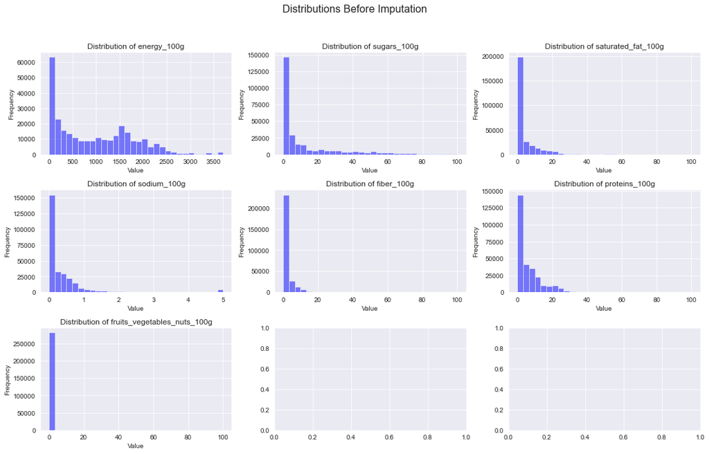

```
Data preview after complete imputation for Nutri-Score variables:
   energy_100g  sugars_100g  saturated_fat_100g  sodium_100g  fiber_100g  \
0          0.0         0.00                0.00        0.000         0.0
1       2243.0        14.29               28.57        0.000         3.6
2       1941.0        17.86                0.00        0.250         7.1
3       2540.0         3.57                5.36        0.482         7.1
4       1552.0         0.00                0.00        0.000         5.7

   proteins_100g  fruits_vegetables_nuts_100g
0           0.00                          0.0
1           3.57                          0.0
2          17.86                          0.0
3          17.86                          0.0
4           8.57                          0.0
Statistical summary after imputation:
         energy_100g    sugars_100g  saturated_fat_100g    sodium_100g  \
count  283629.000000  283629.000000       283629.000000  283629.000000
mean      951.190138      12.599222            3.821814       0.375620
std       834.743876      19.823769            7.221325       0.746312
min         0.000000       0.000000            0.000000       0.000000
25%       172.000000       0.000000            0.000000       0.000000
50%       837.000000       3.230000            0.200000       0.098000
75%      1590.000000      16.000000            5.000000       0.464000
max      3700.000000     100.000000          100.000000       5.000000

          fiber_100g  proteins_100g  fruits_vegetables_nuts_100g
count  283629.000000  283629.000000                283629.000000
mean        1.857766       5.984046                     0.326523
std         3.982990       7.903332                     4.553835
min         0.000000       0.000000                     0.000000
25%         0.000000       0.000000                     0.000000
50%         0.000000       3.330000                     0.000000
75%         2.400000       8.770000                     0.000000
max       100.000000     100.000000                   100.000000
```

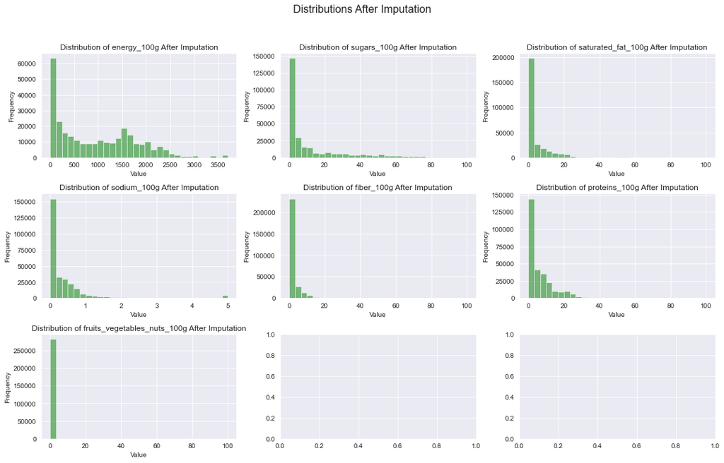

```python
import pandas as pd
import matplotlib.pyplot as plt

# Assuming 'data' is your DataFrame
# Define the target variable for visualization
target_variable = 'nutrition_score_fr_100g'

# Define the columns relevant to Nutri-Score calculation
nutri_score_columns = [
    'energy_100g', 'sugars_100g', 'saturated_fat_100g',
    'sodium_100g', 'fiber_100g', 'proteins_100g',
    'fruits_vegetables_nuts_100g'
]

# Display data before imputation
print("Data preview before imputation for Nutri-Score variables:")
print(data[nutri_score_columns].head())

# Show statistical summary before imputation
print("Statistical summary before imputation:")
print(data[nutri_score_columns].describe())

# Visualize distributions before imputation
fig, axes = plt.subplots(nrows=3, ncols=3, figsize=(15, 10))
fig.suptitle('Distributions Before Imputation', fontsize=16)
for ax, column in zip(axes.flatten()[:len(nutri_score_columns)], nutri_score_columns):
    data[column].hist(ax=ax, bins=30, alpha=0.5, color='blue')
    ax.set_title(f'Distribution of {column}')
    ax.set_xlabel('Value')
    ax.set_ylabel('Frequency')
plt.tight_layout(rect=[0, 0.03, 1, 0.95])
plt.show()

# Impute missing values in Nutri-Score related columns
# Note: Using median imputation as it is less sensitive to outliers in data
medians = data[nutri_score_columns].median()
data[nutri_score_columns] = data[nutri_score_columns].fillna(medians)

# Display data after imputation
print("Data preview after complete imputation for Nutri-Score variables:")
print(data[nutri_score_columns].head())

# Show statistical summary after imputation
print("Statistical summary after imputation:")
print(data[nutri_score_columns].describe())

# Visualize distributions after imputation
fig, axes = plt.subplots(nrows=3, ncols=3, figsize=(15, 10))
fig.suptitle('Distributions After Imputation', fontsize=16)
for ax, column in zip(axes.flatten()[:len(nutri_score_columns)], nutri_score_columns):
    data[column].hist(ax=ax, bins=30, alpha=0.5, color='green')
    ax.set_title(f'Distribution of {column} After Imputation')
    ax.set_xlabel('Value')
    ax.set_ylabel('Frequency')
plt.tight_layout(rect=[0, 0.03, 1, 0.95])
plt.show()
```

```
Data preview before imputation for Nutri-Score variables:
   energy_100g  sugars_100g  saturated_fat_100g  sodium_100g  fiber_100g  \
0          0.0         0.00                0.00        0.000         0.0
1       2243.0        14.29               28.57        0.000         3.6
2       1941.0        17.86                0.00        0.250         7.1
3       2540.0         3.57                5.36        0.482         7.1
4       1552.0         0.00                0.00        0.000         5.7

   proteins_100g  fruits_vegetables_nuts_100g
0           0.00                          0.0
1           3.57                          0.0
2          17.86                          0.0
3          17.86                          0.0
4           8.57                          0.0
Statistical summary before imputation:
         energy_100g    sugars_100g  saturated_fat_100g    sodium_100g  \
count  283629.000000  283629.000000       283629.000000  283629.000000
mean      951.190138      12.599222            3.821814       0.375620
std       834.743876      19.823769            7.221325       0.746312
min         0.000000       0.000000            0.000000       0.000000
25%       172.000000       0.000000            0.000000       0.000000
50%       837.000000       3.230000            0.200000       0.098000
75%      1590.000000      16.000000            5.000000       0.464000
max      3700.000000     100.000000          100.000000       5.000000

          fiber_100g  proteins_100g  fruits_vegetables_nuts_100g
count  283629.000000  283629.000000                283629.000000
mean        1.857766       5.984046                     0.326523
std         3.982990       7.903332                     4.553835
min         0.000000       0.000000                     0.000000
25%         0.000000       0.000000                     0.000000
50%         0.000000       3.330000                     0.000000
75%         2.400000       8.770000                     0.000000
max       100.000000     100.000000                   100.000000
```

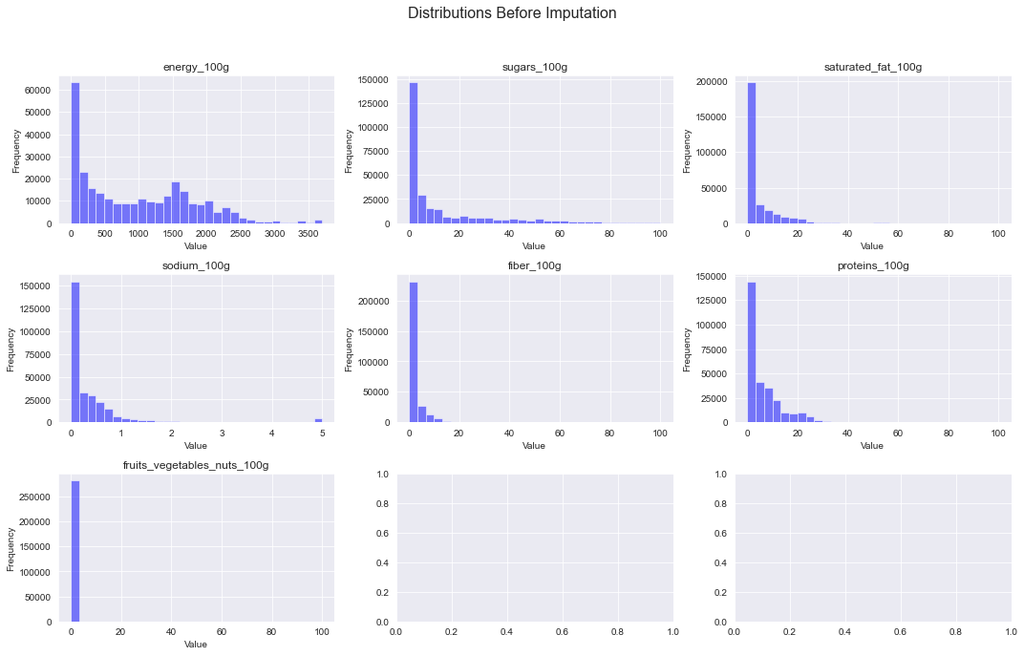

```
Data preview after complete imputation for Nutri-Score variables:
   energy_100g  sugars_100g  saturated_fat_100g  sodium_100g  fiber_100g  \
0          0.0         0.00                0.00        0.000         0.0
1       2243.0        14.29               28.57        0.000         3.6
2       1941.0        17.86                0.00        0.250         7.1
3       2540.0         3.57                5.36        0.482         7.1
4       1552.0         0.00                0.00        0.000         5.7

   proteins_100g  fruits_vegetables_nuts_100g
0           0.00                          0.0
1           3.57                          0.0
2          17.86                          0.0
3          17.86                          0.0
4           8.57                          0.0
Statistical summary after imputation:
         energy_100g    sugars_100g  saturated_fat_100g    sodium_100g  \
count  283629.000000  283629.000000       283629.000000  283629.000000
mean      951.190138      12.599222            3.821814       0.375620
std       834.743876      19.823769            7.221325       0.746312
min         0.000000       0.000000            0.000000       0.000000
25%       172.000000       0.000000            0.000000       0.000000
50%       837.000000       3.230000            0.200000       0.098000
75%      1590.000000      16.000000            5.000000       0.464000
max      3700.000000     100.000000          100.000000       5.000000

          fiber_100g  proteins_100g  fruits_vegetables_nuts_100g
count  283629.000000  283629.000000                283629.000000
mean        1.857766       5.984046                     0.326523
std         3.982990       7.903332                     4.553835
min         0.000000       0.000000                     0.000000
25%         0.000000       0.000000                     0.000000
50%         0.000000       3.330000                     0.000000
75%         2.400000       8.770000                     0.000000
max       100.000000     100.000000                   100.000000
```

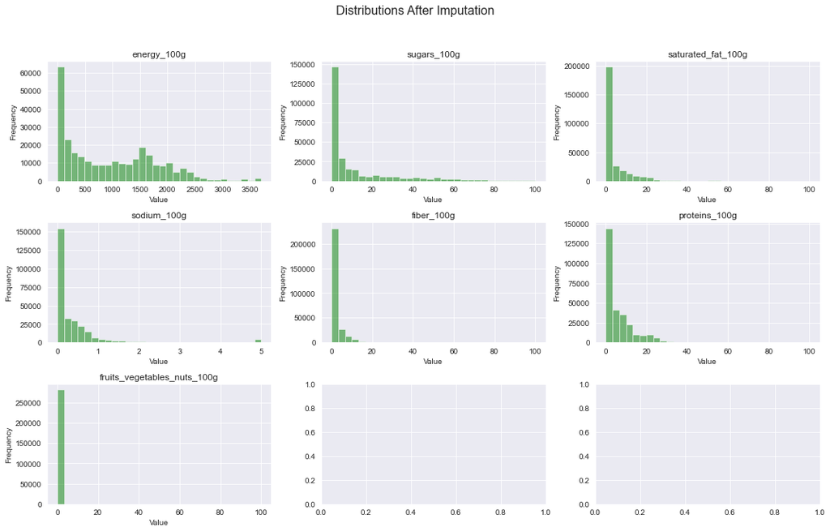

```python
import pandas as pd
import matplotlib.pyplot as plt

# Assuming 'data' is your DataFrame
# Define the target variable
target_variable = 'nutrition_score_fr_100g'

# Define the columns relevant to Nutri-Score calculation
nutri_score_columns = [
    'energy_100g', 'sugars_100g', 'saturated_fat_100g',
    'sodium_100g', 'fiber_100g', 'proteins_100g',
    'fruits_vegetables_nuts_100g'
]

# Optional: Uncomment the following if filtering is desired
# data = data[data[target_variable].notna()]

# Display data before imputation
print("Data preview before imputation for Nutri-Score variables:")
print(data[nutri_score_columns].head())

# Show statistical summary before imputation
print("Statistical summary before imputation:")
print(data[nutri_score_columns].describe())

# Visualize before imputation
fig, axes = plt.subplots(nrows=3, ncols=3, figsize=(15, 10))
fig.suptitle('Distributions Before Imputation', fontsize=16)
for ax, column in zip(axes.flatten(), nutri_score_columns):
    data[column].hist(ax=ax, bins=30, alpha=0.5, color='blue')
    ax.set_title(column)
    ax.set_xlabel('Value')
    ax.set_ylabel('Frequency')
plt.tight_layout(rect=[0, 0.03, 1, 0.95])
plt.show()

# Impute missing values in Nutri-Score related columns
numeric_columns = data[nutri_score_columns].select_dtypes(include='number')
median_values = numeric_columns.median()  # Calculate median for each column
numeric_columns_filled = numeric_columns.fillna(median_values)  # Fill missing values with the respective medians
data.update(numeric_columns_filled)

# Display data after imputation
print("Data preview after complete imputation for Nutri-Score variables:")
print(data[nutri_score_columns].head())

# Show statistical summary after imputation
print("Statistical summary after imputation:")
print(data[nutri_score_columns].describe())

# Visualize after imputation
fig, axes = plt.subplots(nrows=3, ncols=3, figsize=(15, 10))
fig.suptitle('Distributions After Imputation', fontsize=16)
for ax, column in zip(axes.flatten(), nutri_score_columns):
    data[column].hist(ax=ax, bins=30, alpha=0.5, color='green')
    ax.set_title(column)
    ax.set_xlabel('Value')
    ax.set_ylabel('Frequency')
plt.tight_layout(rect=[0, 0.03, 1, 0.95])
plt.show()
```

```python
# Assuming 'data' is your original DataFrame
# Create a copy of the DataFrame to avoid modifying the original data
data_median = data.copy()

# Define the target variable and check only rows where it is not null
target_variable = 'nutrition_score_fr_100g'

# Define the columns relevant to Nutri-Score calculation
nutri_score_columns = [
    'energy_100g', 'sugars_100g', 'saturated_fat_100g',
    'sodium_100g', 'fiber_100g', 'proteins_100g',
    'fruits_vegetables_nuts_100g'
]
# Filter the DataFrame to include only rows where the target variable 'nutrition_score_fr_100g' is not null
data_median = data[data[target_variable].notna()]

# Select only the numeric columns for median calculation
numeric_columns = data_median[nutri_score_columns].select_dtypes(include='number')

# Calculate the median values for each numeric column
median_values = numeric_columns.median()

# Fill missing values with the median values
numeric_columns_filled = numeric_columns.fillna(median_values)

# Combine the filled numeric columns with the original DataFrame
data_median.update(numeric_columns_filled)

# Display the median values for Nutri-Score variables
print("Median values for Nutri-Score variables:")
print(median_values)

# Check the null values count for each Nutri-Score variable after imputation
null_counts_after_imputation = data_median[nutri_score_columns].isnull().sum()

# Check if there are any null values remaining after imputation
assert null_counts_after_imputation.sum() == 0, "There are still null values in some Nutri-Score columns!"

# Print the null values count for each Nutri-Score variable after imputation
print("Null values count for each Nutri-Score variable after median imputation:")
print(null_counts_after_imputation)

# Display the first few rows of the updated data to verify the imputed values
print("Data preview after median imputation:")
print(data_median[nutri_score_columns].head())
```

```
Median values for Nutri-Score variables:
energy_100g                    837.000
sugars_100g                      3.230
saturated_fat_100g               0.200
sodium_100g                      0.098
fiber_100g                       0.000
proteins_100g                    3.330
fruits_vegetables_nuts_100g      0.000
dtype: float64
Null values count for each Nutri-Score variable after median imputation:
energy_100g                    0
sugars_100g                    0
saturated_fat_100g             0
sodium_100g                    0
fiber_100g                     0
proteins_100g                  0
fruits_vegetables_nuts_100g    0
dtype: int64
Data preview after median imputation:
   energy_100g  sugars_100g  saturated_fat_100g  sodium_100g  fiber_100g  \
0          0.0         0.00                0.00        0.000         0.0
1       2243.0        14.29               28.57        0.000         3.6
2       1941.0        17.86                0.00        0.250         7.1
3       2540.0         3.57                5.36        0.482         7.1
4       1552.0         0.00                0.00        0.000         5.7

   proteins_100g  fruits_vegetables_nuts_100g
0           0.00                          0.0
1           3.57                          0.0
2          17.86                          0.0
3          17.86                          0.0
4           8.57                          0.0
```

```python
data.shape # display the shape of the data  (rows, columns)
```

```
(283629, 162)
```

```python
# import pandas as pd

# Assuming 'data' is your original DataFrame
# Create a copy of the DataFrame to avoid modifying the original data
data_mean = data.copy()

# Define the target variable and check only rows where it is not null
target_variable = 'nutrition_score_fr_100g'

# Define the columns relevant to Nutri-Score calculation
nutri_score_columns = [
    'energy_100g', 'sugars_100g', 'saturated_fat_100g',
    'sodium_100g', 'fiber_100g', 'proteins_100g',
    'fruits_vegetables_nuts_100g'
]

# Filter the DataFrame to include only rows where the target variable 'nutrition_score_fr_100g' is not null
data_mean = data_mean[data_mean[target_variable].notna()]

# Select only the numeric columns for mean calculation
numeric_columns = data_mean[nutri_score_columns].select_dtypes(include='number')

# Calculate the mean values for each numeric column
mean_values = numeric_columns.mean()

# Fill missing values with the mean values
numeric_columns_filled = numeric_columns.fillna(mean_values)

# Combine the filled numeric columns with the original DataFrame
data_mean.update(numeric_columns_filled)

# Display the mean values for Nutri-Score variables
print("Mean values for Nutri-Score variables:")
print(mean_values)

# Check the null values count for each Nutri-Score variable after imputation
null_counts_after_imputation = data_mean[nutri_score_columns].isnull().sum()

# Check if there are any null values remaining after imputation
assert null_counts_after_imputation.sum() == 0, "There are still null values in some Nutri-Score columns!"

# Print the null values count for each Nutri-Score variable after imputation
print("Null values count for each Nutri-Score variable after mean imputation:")
print(null_counts_after_imputation)

# Display the first few rows of the updated data to verify the imputed values
print("Data preview after mean imputation:")
print(data_mean[nutri_score_columns].head())
```

```
Mean values for Nutri-Score variables:
energy_100g                    951.190138
sugars_100g                     12.599222
saturated_fat_100g               3.821814
sodium_100g                      0.375620
fiber_100g                       1.857766
proteins_100g                    5.984046
fruits_vegetables_nuts_100g      0.326523
dtype: float64
Null values count for each Nutri-Score variable after mean imputation:
energy_100g                    0
sugars_100g                    0
saturated_fat_100g             0
sodium_100g                    0
fiber_100g                     0
proteins_100g                  0
fruits_vegetables_nuts_100g    0
dtype: int64
Data preview after mean imputation:
   energy_100g  sugars_100g  saturated_fat_100g  sodium_100g  fiber_100g  \
0          0.0         0.00                0.00        0.000         0.0
1       2243.0        14.29               28.57        0.000         3.6
2       1941.0        17.86                0.00        0.250         7.1
3       2540.0         3.57                5.36        0.482         7.1
4       1552.0         0.00                0.00        0.000         5.7

   proteins_100g  fruits_vegetables_nuts_100g
0           0.00                          0.0
1           3.57                          0.0
2          17.86                          0.0
3          17.86                          0.0
4           8.57                          0.0
```

```python
data.shape # display the shape of the data  (rows, columns)
```

```
(283629, 162)
```

### 5.3 Zero Imputation for Missing Values - CE1 - Imputation on Filtered Data Where Nutri-Score Is Present

```python
data_zero_filled = data.copy()

# Define the target variable for Nutri-Score calculation
target_variable = 'nutrition_score_fr_100g'

# Define the columns relevant to Nutri-Score calculation
nutri_score_columns = [
    'energy_100g', 'sugars_100g', 'saturated_fat_100g',
    'sodium_100g', 'fiber_100g', 'proteins_100g',
    'fruits_vegetables_nuts_100g'
]

# Filter the DataFrame to include only rows where the target variable 'nutrition_score_fr_100g' is not null
data_zero_filled = data_zero_filled[data_zero_filled[target_variable].notna()]

# Fill missing values with zero in the Nutri-Score calculation columns
data_zero_filled[nutri_score_columns] = data_zero_filled[nutri_score_columns].fillna(0)

# Check the filled data by displaying the first few rows of the DataFrame focusing only on imputed columns
print("Filled with zeros where 'nutrition_score_fr_100g' exists:")
print(data_zero_filled[nutri_score_columns].head())

# Additional print statement to give a more focused preview of the imputed data
print("Data preview after zero imputation:")
print(data_zero_filled[nutri_score_columns].head())
```

```
Filled with zeros where 'nutrition_score_fr_100g' exists:
   energy_100g  sugars_100g  saturated_fat_100g  sodium_100g  fiber_100g  \
0          0.0         0.00                0.00        0.000         0.0
1       2243.0        14.29               28.57        0.000         3.6
2       1941.0        17.86                0.00        0.250         7.1
3       2540.0         3.57                5.36        0.482         7.1
4       1552.0         0.00                0.00        0.000         5.7

   proteins_100g  fruits_vegetables_nuts_100g
0           0.00                          0.0
1           3.57                          0.0
2          17.86                          0.0
3          17.86                          0.0
4           8.57                          0.0
Data preview after zero imputation:
   energy_100g  sugars_100g  saturated_fat_100g  sodium_100g  fiber_100g  \
0          0.0         0.00                0.00        0.000         0.0
1       2243.0        14.29               28.57        0.000         3.6
2       1941.0        17.86                0.00        0.250         7.1
3       2540.0         3.57                5.36        0.482         7.1
4       1552.0         0.00                0.00        0.000         5.7

   proteins_100g  fruits_vegetables_nuts_100g
0           0.00                          0.0
1           3.57                          0.0
2          17.86                          0.0
3          17.86                          0.0
4           8.57                          0.0
```

```python
data.shape # display the shape of the data  (rows, columns)
```

```
(283629, 162)
```

### 5.4 KNN Imputation for Missing Values - CE1 - Imputation on Filtered Data Where Nutri-Score Is Present

```python
#from sklearn.impute import KNNImputer

# Create a copy for KNN imputation
data_knn_filled = data.copy()

# Define the target variable and the columns relevant to Nutri-Score calculation
target_variable = 'nutrition_score_fr_100g'
nutri_score_columns = [
    'energy_100g', 'sugars_100g', 'saturated_fat_100g',
    'sodium_100g', 'fiber_100g', 'proteins_100g',
    'fruits_vegetables_nuts_100g'
]

# Filter the DataFrame to include only rows where the target variable 'nutrition_score_fr_100g' is not null
data_knn_filled = data_knn_filled[data_knn_filled[target_variable].notna()]

# Initialize the KNN imputer, K can be adjusted based on the dataset size and nature
imputer = KNNImputer(n_neighbors=5)

# Assuming all nutri_score_columns are numeric, if not, use select_dtypes to filter numeric columns
# This ensures that KNN imputation is applied correctly
numeric_columns = data_knn_filled[nutri_score_columns].select_dtypes(include='number')
data_knn_filled[numeric_columns.columns] = imputer.fit_transform(numeric_columns)

# Check the filled data
print("Filled with KNN imputer where 'nutrition_score_fr_100g' exists:")
print(data_knn_filled.head())
# Display the first few rows of the updated data to verify
print("Data preview after median imputation:")
print(data_knn_filled[nutri_score_columns].head())
```

```
Filled with KNN imputer where 'nutrition_score_fr_100g' exists:
            code                                                url  \
0  0000000003087  http://world-fr.openfoodfacts.org/produit/0000...
1  0000000004530  http://world-fr.openfoodfacts.org/produit/0000...
2  0000000004559  http://world-fr.openfoodfacts.org/produit/0000...
3  0000000016087  http://world-fr.openfoodfacts.org/produit/0000...
4  0000000016094  http://world-fr.openfoodfacts.org/produit/0000...

                      creator   created_t      created_datetime  \
0  openfoodfacts-contributors  1474103866  2016-09-17T09:17:46Z
1             usda-ndb-import  1489069957  2017-03-09T14:32:37Z
2             usda-ndb-import  1489069957  2017-03-09T14:32:37Z
3             usda-ndb-import  1489055731  2017-03-09T10:35:31Z
4             usda-ndb-import  1489055653  2017-03-09T10:34:13Z

```

[output cut: 50 more lines]

```python
data.shape # display the shape of the data  (rows, columns)
```

```
(283629, 162)
```

### 5.5 Iterative Imputer (Advanced Linear Models) - CE1 - Applied to Filtered Data Where Nutri-Score Is Present

```python
# from sklearn.experimental import enable_iterative_imputer
# import numpy as np
# from sklearn.impute import IterativeImputer

# Create a copy for iterative imputation
data_iter_filled = data.copy()

# Define the target variable and the columns relevant to Nutri-Score calculation
target_variable = 'nutrition_score_fr_100g'
nutri_score_columns = [
    'energy_100g', 'sugars_100g', 'saturated_fat_100g',
    'sodium_100g', 'fiber_100g', 'proteins_100g',
    'fruits_vegetables_nuts_100g'
]

# Filter the DataFrame to include only rows where the target variable 'nutrition_score_fr_100g' is not null
data_iter_filled = data_iter_filled[data_iter_filled[target_variable].notna()]

# Initialize the iterative imputer
iter_imputer = IterativeImputer()

# Apply imputation only on the filtered dataset
# Ensure all columns in nutri_score_columns are numeric; if not, filter by select_dtypes
numeric_columns = data_iter_filled[nutri_score_columns].select_dtypes(include=np.number)
data_iter_filled[numeric_columns.columns] = iter_imputer.fit_transform(numeric_columns)

# Check the filled data by displaying the first few rows of the DataFrame focusing only on imputed columns
print("Filled with Iterative Imputer where 'nutrition_score_fr_100g' exists:")
print(data_iter_filled[numeric_columns.columns].head())

# Display the first few rows of the updated data to verify the imputed values
print("Data preview after iterative imputation:")
print(data_iter_filled[nutri_score_columns].head())
```

```
Filled with Iterative Imputer where 'nutrition_score_fr_100g' exists:
   energy_100g  sugars_100g  saturated_fat_100g  sodium_100g  fiber_100g  \
0          0.0         0.00                0.00        0.000         0.0
1       2243.0        14.29               28.57        0.000         3.6
2       1941.0        17.86                0.00        0.250         7.1
3       2540.0         3.57                5.36        0.482         7.1
4       1552.0         0.00                0.00        0.000         5.7

   proteins_100g  fruits_vegetables_nuts_100g
0           0.00                          0.0
1           3.57                          0.0
2          17.86                          0.0
3          17.86                          0.0
4           8.57                          0.0
Data preview after iterative imputation:
   energy_100g  sugars_100g  saturated_fat_100g  sodium_100g  fiber_100g  \
0          0.0         0.00                0.00        0.000         0.0
1       2243.0        14.29               28.57        0.000         3.6
2       1941.0        17.86                0.00        0.250         7.1
3       2540.0         3.57                5.36        0.482         7.1
4       1552.0         0.00                0.00        0.000         5.7

   proteins_100g  fruits_vegetables_nuts_100g
0           0.00                          0.0
1           3.57                          0.0
2          17.86                          0.0
3          17.86                          0.0
4           8.57                          0.0
```

```python
data.shape # display the shape of the data  (rows, columns)
```

```
(283629, 162)
```

## Understanding and Using Iterative Imputer in Nutri-Score Calculation

### Background on Iterative Imputer

The **Iterative Imputer** is an advanced statistical method used to impute missing values by modeling each feature with missing values as a function of other features. This approach is done iteratively over each feature in a round-robin fashion.

### Pre-Requisites and Limitations

#### Pre-Requisites

- **Statistical Relationships**: A deep understanding of the statistical relationships between features is crucial. The Iterative Imputer assumes that the missing values can reasonably be estimated using the other available features.
- **Data Structure Knowledge**: Before applying this method, one must have a robust understanding of the dataset's structure, potential correlations, and the nature of missingness (random or systematic).

#### Limitations

- **Computational Expense**: This method can be computationally intensive, particularly with large datasets.
- **Bias Risk**: If the assumptions about data relationships are incorrect, the imputation might introduce bias, potentially leading to misleading results.
- **Performance Issues**: The performance can degrade if the missing data is too extensive or not sufficiently random.

### Application in Nutri-Score Project

In this project, the Iterative Imputer is used to manage missing data for critical nutritional components such as `energy_100g`, `sugars_100g`, and others involved in calculating the Nutri-Score. Key considerations include:

- **Targeted Imputation**: Imputation is carefully applied only to rows where `nutrition_score_fr_100g` is not null. This ensures that the Nutri-Score, which relies on this variable, is calculated from the most accurate data.
- **Focus on Numeric Data**: Imputation is restricted to numeric columns to ensure that the mathematical models used in the imputation are valid.
- **Data Integrity**: By focusing imputation on well-understood parts of the dataset, the integrity and accuracy of the Nutri-Score calculations are preserved.

### Conclusion

Employing an Iterative Imputer in the Nutri-Score project showcases a sophisticated approach to handling missing data. It requires careful consideration of the dataset's characteristics and an informed approach to its application, ensuring that the imputation enhances the dataset's utility without compromising its reliability.

### 5.6 filling missing values with the most frequent value in each column

```python
# Create a copy for the most frequent values method
data_most_frequent_value = data.copy()

# Define the columns you want to impute
columns_to_impute = [
    'energy_100g', 'sugars_100g', 'saturated_fat_100g',
    'sodium_100g', 'fiber_100g', 'proteins_100g',
    'fruits_vegetables_nuts_100g'
]

# Perform mode imputation for each specified column
for column in columns_to_impute:
    mode_value = data_most_frequent_value[column].mode()[0]  # Calculate the mode
    data_most_frequent_value[column] = data_most_frequent_value[column].fillna(mode_value)  # Direct assignment

# Check the results by displaying the first few rows of the DataFrame focusing only on imputed columns
print(data_most_frequent_value[columns_to_impute].head())
```

```
   energy_100g  sugars_100g  saturated_fat_100g  sodium_100g  fiber_100g  \
0          0.0         0.00                0.00        0.000         0.0
1       2243.0        14.29               28.57        0.000         3.6
2       1941.0        17.86                0.00        0.250         7.1
3       2540.0         3.57                5.36        0.482         7.1
4       1552.0         0.00                0.00        0.000         5.7

   proteins_100g  fruits_vegetables_nuts_100g
0           0.00                          0.0
1           3.57                          0.0
2          17.86                          0.0
3          17.86                          0.0
4           8.57                          0.0
```

```python
data.shape # display the shape of the data  (rows, columns)
```

```
(283629, 162)
```

### 5.7 Verification of Data Completeness After Imputation Methods - CE1

```python
# Define the columns relevant to Nutri-Score calculation
nutri_score_columns = [
    'energy_100g', 'sugars_100g', 'saturated_fat_100g',
    'sodium_100g', 'fiber_100g', 'proteins_100g',
    'fruits_vegetables_nuts_100g'
]

# List of DataFrames to check
dataframes = {
    'Median Imputation': data_median,
    'Mean Imputation': data_mean,
    'Zero Imputation': data_zero_filled,
    'KNN Imputation': data_knn_filled,
    'Iterative Imputation': data_iter_filled,
    'Most Frequent Value Imputation': data_most_frequent_value
}

# Check and print missing values for each method
for method, df in dataframes.items():
    print(f"\n{method}:")
    # Check if there are any missing values left in the columns related to Nutri-Score calculation
    missing_values = df[nutri_score_columns].isnull().sum()
    print("Missing values count for each Nutri-Score variable after imputation:")
    print(missing_values)

    # Verify that all entries for Nutri-Score calculation variables are complete
    all_columns_filled = df[nutri_score_columns].notnull().all(axis=1)
    print(f"All Nutri-Score calculation variables are complete for {all_columns_filled.sum()} out of {df.shape[0]} entries.")

    # Assert to ensure no missing values are left in the Nutri-Score columns
    assert df[nutri_score_columns].notnull().all().all(), f"There are still missing values in the Nutri-Score calculation columns for {method}!"
```

```
Median Imputation:
Missing values count for each Nutri-Score variable after imputation:
energy_100g                    0
sugars_100g                    0
saturated_fat_100g             0
sodium_100g                    0
fiber_100g                     0
proteins_100g                  0
fruits_vegetables_nuts_100g    0
dtype: int64
All Nutri-Score calculation variables are complete for 283629 out of 283629 entries.

Mean Imputation:
Missing values count for each Nutri-Score variable after imputation:
energy_100g                    0
sugars_100g                    0
saturated_fat_100g             0
sodium_100g                    0
fiber_100g                     0
proteins_100g                  0
fruits_vegetables_nuts_100g    0
dtype: int64
All Nutri-Score calculation variables are complete for 283629 out of 283629 entries.

Zero Imputation:
Missing values count for each Nutri-Score variable after imputation:
energy_100g                    0
sugars_100g                    0
saturated_fat_100g             0
sodium_100g                    0
fiber_100g                     0
proteins_100g                  0
fruits_vegetables_nuts_100g    0
dtype: int64
All Nutri-Score calculation variables are complete for 283629 out of 283629 entries.

KNN Imputation:
Missing values count for each Nutri-Score variable after imputation:
energy_100g                    0
sugars_100g                    0
```

[output cut: 16 more lines]

```
fruits_vegetables_nuts_100g    0
dtype: int64
All Nutri-Score calculation variables are complete for 283629 out of 283629 entries.

Most Frequent Value Imputation:
Missing values count for each Nutri-Score variable after imputation:
energy_100g                    0
sugars_100g                    0
saturated_fat_100g             0
sodium_100g                    0
fiber_100g                     0
proteins_100g                  0
fruits_vegetables_nuts_100g    0
dtype: int64
All Nutri-Score calculation variables are complete for 283629 out of 283629 entries.
```

## Explanation of the Code

- **Nutri-Score Columns**: A list of the variables involved in calculating the Nutri-Score, which are crucial for the analysis.
- **DataFrames Dictionary**: A mapping of each imputation method to its corresponding DataFrame. This setup facilitates systematic verification across different data handling strategies.
- **Loop and Checks**: For each method, the script prints a detailed count of any remaining missing values and confirms the completeness of each entry in the relevant Nutri-Score calculation columns.
- **Assertions**: The script includes assertions to programmatically ensure that no missing values remain, providing a fail-safe mechanism that alerts to any remaining data issues.

This approach is a first step for verification process. It helps to confirm that the imputation methods have effectively handled missing values in the dataset, ensuring the integrity of the data for subsequent analyses or modeling tasks.

### 5.8 Saving the Imputed Data to a New CSV File - CE1 using the median imputation method

```python
# Define the path for saving data, ensuring it points to the 'data' directory
save_path = os.path.join(base_path, 'data/')  # Ensure this path points to the data directory

# Save the data with median imputation to a new CSV file
data_median.to_csv(os.path.join(save_path, 'median_imputed_data.csv'), index=False)
print("Data with median imputation saved to 'median_imputed_data.csv'")
```

```
Data with median imputation saved to 'median_imputed_data.csv'
```

```python
# # Save the data with mean imputation to a new CSV file
# data_median.to_csv('../data/median_imputed_data.csv', index=False)
# print("Data with mean imputation saved to 'mean_imputed_data.csv'")
```

```python
# Display data.shape in data.to_csv('../data/median_imputed_data.csv', index=False)
data.shape
```

```
(283629, 162)
```

### 5.9 RGPD Compliance and Data Protection Considerations - CE1

#### 5.9.1 General Overview of GDPR Principles

The General Data Protection Regulation (GDPR) is a comprehensive data protection framework designed to safeguard the rights and freedoms of individuals regarding the processing of their personal data. Here's a summary of the key principles of GDPR:

### 1. Lawfulness, Fairness, and Transparency

- Personal data must be processed lawfully, fairly, and transparently. Individuals should be informed of the purposes of data processing and their rights regarding their personal data.

### 2. Purpose Limitation

- Personal data should be collected for specified, explicit, and legitimate purposes and not further processed in a manner incompatible with those purposes.

### 3. Data Minimization

- Data collection should be limited to what is necessary for the intended purposes. Organizations should minimize the amount of personal data collected and processed.

### 4. Accuracy

- Personal data must be accurate and kept up to date. Organizations are responsible for taking reasonable steps to ensure the accuracy of personal data and correcting any inaccuracies.

### 5. Storage Limitation

- Personal data should be kept in a form that permits identification of data subjects for no longer than is necessary for the purposes for which the personal data are processed.

### 6. Integrity and Confidentiality

- Personal data must be processed in a manner that ensures appropriate security, including protection against unauthorized or unlawful processing and accidental loss, destruction, or damage.

### 7. Accountability and Transparency

- Organizations are accountable for complying with GDPR principles and must be able to demonstrate compliance. They should implement appropriate measures and policies to ensure GDPR compliance and be transparent about their data processing activities.

### 8. Data Subject Rights

- GDPR grants individuals certain rights over their personal data, including the right to access, rectify, erase, restrict processing, and data portability. Organizations must facilitate the exercise of these rights by data subjects.

These principles form the foundation of GDPR and guide organizations in the responsible and ethical processing of personal data, promoting trust and confidence in data handling practices.

#### 5.9.2 Data Cleaning Process and GDPR Compliance

In the context of our project, adhering to the General Data Protection Regulation (GDPR) is essential, particularly concerning data cleaning processes. The GDPR mandates that personal data be processed lawfully, fairly, and transparently, with specific provisions ensuring the accuracy and integrity of the data. Here, we discuss how our data cleaning process aligns with GDPR principles:

##### 5 Principles of GDPR and Data Cleaning Process

1. **Lawfulness, Fairness, and Transparency**: Our data cleaning process ensures that all data processing activities are conducted lawfully, fairly, and transparently. We adhere to legal requirements and maintain clear documentation of our data cleaning procedures.
2. **Purpose Limitation**: We process personal data only for specified, explicit, and legitimate purposes, ensuring that our data cleaning activities are aligned with the objectives of our project. Any data cleaning steps are undertaken with a clear purpose and relevance to the project goals.
3. **Data Minimization**: We minimize the collection and processing of personal data to what is necessary for the intended purposes. Our data cleaning process focuses on retaining only relevant data and discarding or anonymizing unnecessary information.
4. **Accuracy**: A key principle of the GDPR is the accuracy of personal data. Companies are required to ensure that the data they hold is accurate and, if necessary, to update it. When imputing missing data, they must ensure that the methods used do not compromise the accuracy of the data.
5. **Storage Limitation**: Personal data should be kept in a form that permits identification of data subjects for no longer than is necessary for the purposes for which the personal data are processed. Our data cleaning process includes measures to anonymize or pseudonymize data and establish appropriate retention periods.

##### Compliance with GDPR Principles

Our data cleaning process incorporates mechanisms to ensure compliance with GDPR principles:

- Imputation methods for missing data are carefully selected to maintain the accuracy of the dataset.
- Documentation of data cleaning activities includes justification for each step taken, ensuring transparency and accountability.
- Personal data is stored and processed securely, with access restricted to authorized personnel only.
- Regular reviews of data cleaning procedures are conducted to assess compliance with GDPR requirements and identify areas for improvement.

By aligning our data cleaning process with GDPR principles, we prioritize the protection of individuals' rights and ensure the integrity and reliability of the data used in our project.

## 6. Bivariate and Multivariate Statistical Analysis

### 6.1 Bivariate Analysis Graphics - CE5

*Presentation of bivariate graphical analysis, including code for generating such graphics.*

#### 6.1.1 Matrix of correlation between Nutri-Score variables

```
                                 energy_100g  sugars_100g  saturated_fat_100g  \
energy_100g                         1.000000     0.387706            0.585819
sugars_100g                         0.387706     1.000000            0.123954
saturated_fat_100g                  0.585819     0.123954            1.000000
sodium_100g                         0.081066    -0.101268            0.029399
fiber_100g                          0.308325     0.039336            0.052782
proteins_100g                       0.394226    -0.132186            0.248655
fruits_vegetables_nuts_100g        -0.035573     0.024403           -0.029629
nutrition_score_fr_100g_encoded     0.635283     0.439186            0.615063

                                 sodium_100g  fiber_100g  proteins_100g  \
energy_100g                         0.081066    0.308325       0.394226
sugars_100g                        -0.101268    0.039336      -0.132186
saturated_fat_100g                  0.029399    0.052782       0.248655
sodium_100g                         1.000000    0.015167       0.190355
fiber_100g                          0.015167    1.000000       0.276959
proteins_100g                       0.190355    0.276959       1.000000
fruits_vegetables_nuts_100g        -0.025224   -0.010303      -0.036586
nutrition_score_fr_100g_encoded     0.215368   -0.012798       0.252896

                                 fruits_vegetables_nuts_100g  \
energy_100g                                        -0.035573
sugars_100g                                         0.024403
saturated_fat_100g                                 -0.029629
sodium_100g                                        -0.025224
fiber_100g                                         -0.010303
proteins_100g                                      -0.036586
fruits_vegetables_nuts_100g                         1.000000
nutrition_score_fr_100g_encoded                    -0.022558

                                 nutrition_score_fr_100g_encoded
energy_100g                                             0.635283
sugars_100g                                             0.439186
saturated_fat_100g                                      0.615063
sodium_100g                                             0.215368
fiber_100g                                             -0.012798
proteins_100g                                           0.252896
fruits_vegetables_nuts_100g                            -0.022558
nutrition_score_fr_100g_encoded                         1.000000
```

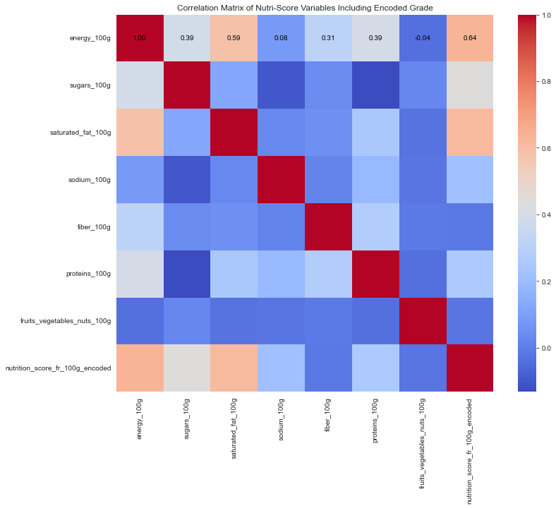

```python
# Full path to the dataset
data_path = os.path.join(base_path, 'data', 'median_imputed_data.csv')

# Load your dataset
data = pd.read_csv(data_path)

# Define the columns relevant to Nutri-Score calculation
nutri_score_columns = [
    'energy_100g', 'sugars_100g', 'saturated_fat_100g',
    'sodium_100g', 'fiber_100g', 'proteins_100g',
    'fruits_vegetables_nuts_100g'
]

# Ensure that only numeric columns are considered
numeric_columns = data[nutri_score_columns].select_dtypes(include='number').columns.tolist()

# Assuming 'nutrition_score_fr_100g' is the column with categorical grades
# We need to encode these grades numerically for correlation analysis
label_encoder = LabelEncoder()
data['nutrition_score_fr_100g_encoded'] = label_encoder.fit_transform(data['nutrition_score_fr_100g'])

# Append the encoded nutritional grade to your numeric columns list
numeric_columns.append('nutrition_score_fr_100g_encoded')

# Calculate the correlation matrix for the Nutri-Score variables including the encoded Nutri-Score
correlation_matrix = data[numeric_columns].corr()

# Print the correlation matrix
print(correlation_matrix)

# Plot the correlation matrix as a heatmap
plt.figure(figsize=(12, 10))  # Adjust size to ensure annotations fit
sns.heatmap(correlation_matrix, annot=True, cmap='coolwarm', fmt=".2f", square=True, annot_kws={'size': 10, 'color': 'black'})  # Ensure annot_kws color contrast
plt.title('Correlation Matrix of Nutri-Score Variables Including Encoded Grade')
plt.tight_layout()  # Adjust layout to fit
plt.show()
```

## Correlation Analysis Observations

**Important Points to Consider:**

- Exercise caution when interpreting correlations in bivariate analysis, as correlation does not imply causation.
- Ensure a thorough understanding of the context of your problem and your data to interpret the results of the analysis correctly.

**Note:** While correlation provides insights into possible relationships, it does not establish causation. These findings should be substantiated with domain expertise and additional statistical tests for definitive conclusions.

### 6.1.2 Scatter Plots for Bivariate Analysis between sugar_100g and energy_100g

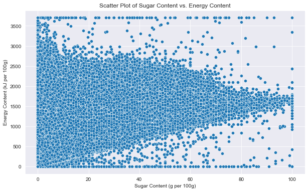

```python
# Scatter plot for sugar_100g and energy_100g using mean_imputed_data.csv
plt.figure(figsize=(10, 6))
sns.scatterplot(data=data, x='sugars_100g', y='energy_100g')
plt.title('Scatter Plot of Sugar Content vs. Energy Content')
plt.xlabel('Sugar Content (g per 100g)')
plt.ylabel('Energy Content (kJ per 100g)')
plt.show()
```

## Scatter Plot Analysis: Sugar Content vs. Energy Content per 100g

Further detailed analysis would be needed to understand the intricate dynamics between these two variables better.

> **Note**: While the scatter plot provides a general trend, it represents aggregate data where each point corresponds to an individual product, and broad conclusions should be approached with careful consideration of the context.

### 6.1.3 Scatter Plots for Bivariate Analysis between several Nutri-Score variables

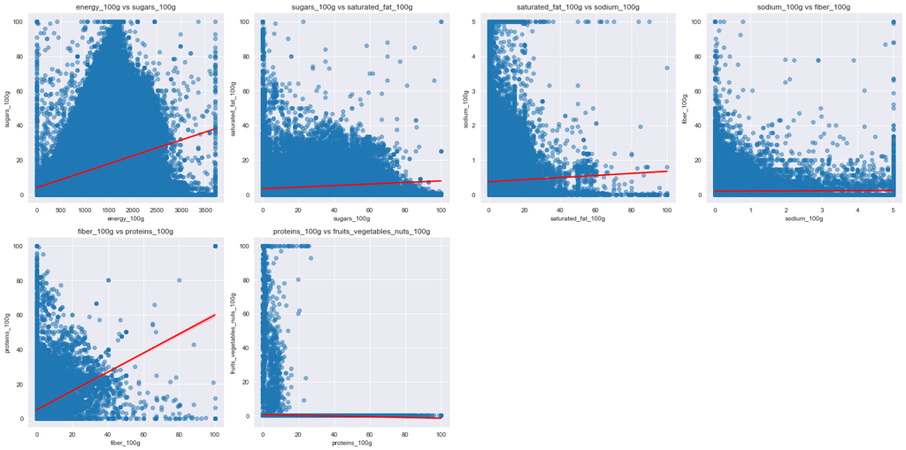

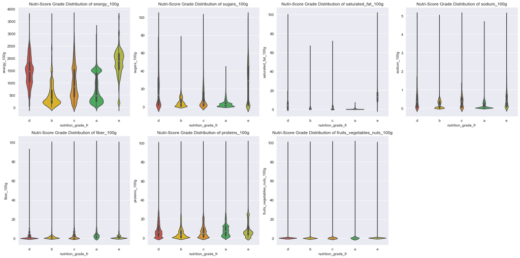

```python
# import pandas as pd
# import seaborn as sns
# import matplotlib.pyplot as plt
from sklearn.preprocessing import LabelEncoder

# Full path to the dataset
data_path = os.path.join(base_path, 'data', 'median_imputed_data.csv')

# Load your dataset
data = pd.read_csv(data_path)

# Check if 'nutrition_score_fr_100g' column exists
if 'nutrition_score_fr_100g' not in data.columns:
    raise KeyError("Column 'nutrition_score_fr_100g' does not exist in DataFrame.")

# Define color palette for Nutri-Score grades
palette = {
    'a': '#3cba54',  # Green for best grade
    'b': '#f4c20d',  # Yellow
    'c': '#f09819',  # Orange
    'd': '#db4437',  # Red-orange
    'e': '#c0ca33'   # Red for worst grade
}

# Define the LabelEncoder and encode Nutri-Score grades
label_encoder = LabelEncoder()
data['nutrition_score_fr_100g_encoded'] = label_encoder.fit_transform(data['nutrition_score_fr_100g'])

# Create scatter plots with regression lines
fig, axs = plt.subplots(2, 4, figsize=(20, 10))
axs = axs.flatten()
for i in range(len(nutri_score_columns)-1):
    sns.regplot(
        x=nutri_score_columns[i],
        y=nutri_score_columns[i+1],
        data=data,
        ax=axs[i],
        scatter_kws={'alpha': 0.5},
        line_kws={'color': 'red'}
    )
    axs[i].set_title(f'{nutri_score_columns[i]} vs {nutri_score_columns[i+1]}')

# Hide unused subplots
for ax in axs[len(nutri_score_columns)-1:]:
    ax.set_visible(False)

plt.tight_layout()
plt.show()

# Create violin plots with Nutri-Score grades
fig, axs = plt.subplots((len(nutri_score_columns) + 3) // 4, 4, figsize=(20, 10))
axs = axs.flatten()
for i, column in enumerate(nutri_score_columns):
    sns.violinplot(
        x='nutrition_grade_fr',
        y=column,
        data=data,
        ax=axs[i],
        palette=palette
    )
    axs[i].set_title(f'Nutri-Score Grade Distribution of {column}')

# Hide unused subplots
for ax in axs[len(nutri_score_columns):]:
    ax.set_visible(False)

plt.tight_layout()
plt.show()
```

## 7. Explanatory Multivariate Analysis Methods - CE7

- Discussion of multivariate analysis techniques used for explanatory purposes.

Before starting this step, I need to ensure that my data is clean, with no missing values or outliers. To confirm that the data is clean, without any missing or aberrant values

```python
# Check for missing values in the data for nutriscore variables
data[nutri_score_columns].isnull().sum()
```

```
energy_100g                    0
sugars_100g                    0
saturated_fat_100g             0
sodium_100g                    0
fiber_100g                     0
proteins_100g                  0
fruits_vegetables_nuts_100g    0
dtype: int64
```

```python
data.shape
```

```
(283629, 163)
```

Problem with shape of data!!!!!!!!!!

### 7.1 Principal Component Analysis (PCA) for Dimensionality Reduction - CE7

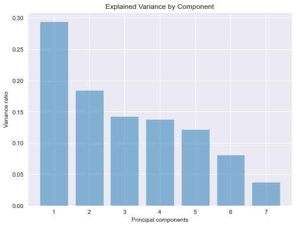

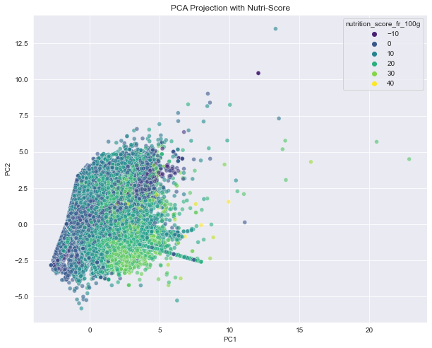

```python
# Construct the full path to the dataset
data_path = os.path.join(base_path, 'data', 'median_imputed_data.csv')

# Load your dataset with the low_memory option set to False to better handle mixed data types
data = pd.read_csv(data_path, low_memory=False)

# Define the columns for analysis
nutri_score_columns = [
    'energy_100g', 'sugars_100g', 'saturated_fat_100g',
    'sodium_100g', 'fiber_100g', 'proteins_100g',
    'fruits_vegetables_nuts_100g'
]

# Filter the data to keep only rows without missing values for the relevant analyses
data_pca = data[nutri_score_columns].dropna()

# Normalize the data
scaler = StandardScaler()
data_normalized = scaler.fit_transform(data_pca)

# Initialize and fit PCA
pca = PCA()
pca.fit(data_normalized)

# Obtain eigenvalues and eigenvectors (principal components)
explained_variance = pca.explained_variance_ratio_

# Visualize the explained variance by each principal component
plt.figure(figsize=(8, 6))
plt.bar(range(1, len(explained_variance) + 1), explained_variance, alpha=0.5, align='center')
plt.ylabel('Variance ratio')
plt.xlabel('Principal components')
plt.title('Explained Variance by Component')
plt.show()

# Optionally: Visualize the PCA scores for the first two principal components
pca_scores = PCA(n_components=2).fit_transform(data_normalized)
pca_df = pd.DataFrame(data=pca_scores, columns=['PC1', 'PC2'])

# Merge the PCA scores with the initial data to visualize by Nutri-Score
pca_df = pca_df.join(data['nutrition_score_fr_100g'])

# Plot a scatter plot of the first two principal components
plt.figure(figsize=(10, 8))
sns.scatterplot(x='PC1', y='PC2', hue='nutrition_score_fr_100g', data=pca_df, palette='viridis', alpha=0.6)
plt.title('PCA Projection with Nutri-Score')
plt.show()
```

## PCA Script Breakdown

**This script accomplishes the following tasks:**

- **Data Loading:** Data is loaded from a CSV file.
- **Filtering:** Data is filtered to remove rows with missing values in the columns of interest.
- **Normalization:** Data is normalized so that each feature contributes equally to the analysis.
- **PCA Application:** PCA is applied to reduce the dimensionality of the data while retaining as much information as possible.
- **Visualization:** Results are visualized to interpret the variance explained by the principal components and to examine the relationships among the observations in the reduced feature space.

**Utility of PCA:**

PCA is particularly useful for identifying underlying patterns in the data and for visualizing the complex structure of data in reduced dimensions.

# Display the explained variance ratio for each principal component

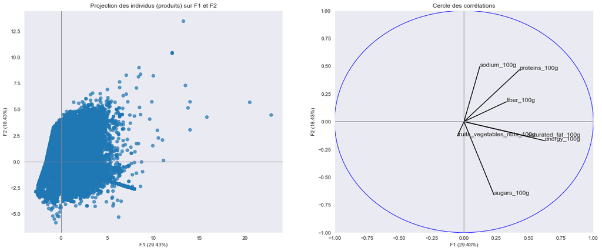

```python
import pandas as pd
import numpy as np
import matplotlib.pyplot as plt
from sklearn.decomposition import PCA
from sklearn.preprocessing import StandardScaler


# Your DataFrame with the specified columns for analysis
# Ensure that the data is cleaned to remove NaN values, etc.

nutri_score_columns = [
    'energy_100g', 'sugars_100g', 'saturated_fat_100g',
    'sodium_100g', 'fiber_100g', 'proteins_100g',
    'fruits_vegetables_nuts_100g'
]

# Selection of columns for PCA
X = data[nutri_score_columns]

# Normalisation of the data using StandardScaler
X_scaled = StandardScaler().fit_transform(X)

# Create a PCA object with 2 components
pca = PCA(n_components=2)

# Fit and transform the data
X_pca = pca.fit_transform(X_scaled)

# Create a DataFrame for the PCA results
pca_df = pd.DataFrame(data=X_pca, columns=['F1', 'F2'])

# Set the figure size and create subplots
plt.figure(figsize=(20, 8))

# First subplot for the individuals
plt.subplot(1, 2, 1) # ligne 1, column 2, position 1
plt.scatter(pca_df['F1'], pca_df['F2'], alpha=0.7)
plt.xlabel(f'F1 ({pca.explained_variance_ratio_[0]:.2%})')
plt.ylabel(f'F2 ({pca.explained_variance_ratio_[1]:.2%})')
plt.title("Projection des individus (produits) sur F1 et F2")
plt.axvline(x=0, color='grey', lw=1)
plt.axhline(y=0, color='grey', lw=1)
plt.grid()

# Second subplot for the correlation circle
plt.subplot(1, 2, 2)  # ligne 1, column 2, position 2
circle = plt.Circle((0, 0), 1, color='blue', fill=False)
plt.gca().add_artist(circle)
for i, (x, y) in enumerate(zip(pca.components_[0], pca.components_[1])):
    plt.plot([0, x], [0, y], color='k')
    plt.text(x, y, nutri_score_columns[i], fontsize=12)

plt.xlim(-1, 1)
plt.ylim(-1, 1)
plt.xlabel(f'F1 ({pca.explained_variance_ratio_[0]:.2%})')
plt.ylabel(f'F2 ({pca.explained_variance_ratio_[1]:.2%})')
plt.title('Cercle des corrélations')
plt.axvline(x=0, color='grey', lw=1)
plt.axhline(y=0, color='grey', lw=1)
plt.grid()

# Display the figure with the two subplots
plt.show()
```

### 7.2 ANOVA for Multivariate Analysis - CE7

### ANOVA is a statistical technique used to compare the means of two or more groups to determine if there are statistically significant differences between them. In the context of multivariate analysis, ANOVA can be applied to assess the impact of multiple independent variables on a dependent variable.

### The objective is to determine if there is a significant difference in the mean values of the quantitative variables (energy_100g, sugars_100g, saturated_fat_100g, sodium_100g, fiber_100g, proteins_100g, fruits_vegetables_nuts_100g) across different Nutri-Score grades (qualitative variable: nutrition_grade_fr.

```python
from scipy.stats import ttest_1samp # One-sample t-test for quantitative variable
from scipy.stats import f_oneway # ANOVA for one qualitative variable and one quantitative variable
from scipy.stats import chi2_contingency # Chi-square test to study two qualitative variables
from scipy.stats import chi2 # Chi-square distribution test to study the correlation between two qualitative variables
# from scipy.stats import pearsonr # Calculate the Pearson correlation coefficient to study the correlation between two quantitative variables
```

### 7.2.1 ANOVA for nutriscore_fr_100g (qualitative variable) and energy_100g (quantitative variable) (one way ANOVA)

## Convert the Target Variable to a Categorical Data Type:

Here, the variable `nutrition_grade_fr` is converted to a categorical data type. This conversion is significant because `nutrition_grade_fr` likely represents different nutritional grades in a qualitative (but ordered) manner, such as grades A, B, C, D, E. Converting this variable into a categorical type helps in treating it appropriately in statistical tests and can improve performance in data processing.

```python
# Define the target variable and check only rows where it is not null
print(df['nutrition_grade_fr'].dtype)
```

```
object
```

```python
# Convert the target variable to a categorical data type
df['nutrition_grade_fr'] = df['nutrition_grade_fr'].astype('category')

# Check the data type of the target variable after conversion
print(df['nutrition_grade_fr'].dtype)
```

```
category
```

```python
# List of columns to check
columns_to_check = [
    'energy_100g', 'sugars_100g', 'saturated_fat_100g',
    'sodium_100g', 'fiber_100g', 'proteins_100g',
    'fruits_vegetables_nuts_100g'
]

# Display data types for these columns
data[columns_to_check].dtypes
```

```
energy_100g                    float64
sugars_100g                    float64
saturated_fat_100g             float64
sodium_100g                    float64
fiber_100g                     float64
proteins_100g                  float64
fruits_vegetables_nuts_100g    float64
dtype: object
```

```python
import pandas as pd
from scipy.stats import f_oneway

# Check if the necessary columns are present in the DataFrame
if 'nutrition_score_fr_100g' in df.columns and 'energy_100g' in df.columns:
    # Prepare the data by dropping rows with missing values
    df_anova = df[['nutrition_score_fr_100g', 'energy_100g']].dropna()

    # Group energy values by Nutri-Score grade
    groups = df_anova.groupby('nutrition_score_fr_100g')['energy_100g'].apply(list)

    # Perform the ANOVA test to compare the mean energies across different Nutri-Score grades
    f_statistic, p_value = f_oneway(*groups)

    # Display grouped data for visual inspection
    print("Grouped Energy Values by Nutri-Score Grade:")
    for grade, values in groups.items():
        print(f"{grade}: {values[:5]}... [Total: {len(values)} values]")  # Show the first 5 values for each group

    # Display statistical results
    print(f"F-statistic: {f_statistic:.2f}")
    print(f"P-value: {p_value:.4f}")

    # Interpret the results
    if p_value < 0.05:
        print("Reject the null hypothesis - There is a significant difference in energy content across different Nutri-Score grades.")
    else:
        print("Fail to reject the null hypothesis - There is no significant difference in energy content across different Nutri-Score grades.")
else:
    print("Error: DataFrame does not contain the required columns 'nutrition_score_fr_100g' and 'energy_100g'. Please check your DataFrame.")
```

```
Grouped Energy Values by Nutri-Score Grade:
-15.0: [317.0]... [Total: 1 values]
-14.0: [293.0, 485.0, 437.0, 461.0, 547.0]... [Total: 5 values]
-13.0: [331.0, 460.0, 384.0, 347.0, 334.0]... [Total: 21 values]
-12.0: [284.0, 175.0, 209.0, 250.0, 293.0]... [Total: 44 values]
-11.0: [153.0, 148.0, 137.0, 186.0, 169.0]... [Total: 86 values]
-10.0: [151.0, 0.0, 0.0, 0.0, 151.0]... [Total: 149 values]
-9.0: [442.0, 590.0, 540.0, 619.0, 615.0]... [Total: 301 values]
-8.0: [699.0, 331.0, 151.0, 556.0, 477.0]... [Total: 543 values]
-7.0: [176.0, 356.0, 322.0, 1075.0, 1301.0]... [Total: 869 values]
-6.0: [1096.0, 983.0, 1494.0, 1464.0, 1393.0]... [Total: 4668 values]
-5.0: [222.0, 372.0, 1554.0, 272.0, 230.0]... [Total: 3795 values]
-4.0: [100.0, 100.0, 975.0, 354.0, 1088.0]... [Total: 4083 values]
-3.0: [75.0, 75.0, 1021.0, 235.0, 795.0]... [Total: 4709 values]
-2.0: [159.0, 619.0, 615.0, 448.0, 1071.0]... [Total: 5701 values]
-1.0: [1887.0, 1904.0, 1749.0, 983.0, 1071.0]... [Total: 8068 values]
0.0: [0.0, 1941.0, 1552.0, 1933.0, 1490.0]... [Total: 91362 values]
1.0: [1160.0, 1159.0, 941.0, 192.0, 192.0]... [Total: 10389 values]
2.0: [478.0, 1527.0, 192.0, 226.0, 192.0]... [Total: 9753 values]
3.0: [1176.0, 941.0, 1046.0, 418.0, 929.0]... [Total: 7242 values]
4.0: [954.0, 427.0, 402.0, 564.0, 761.0]... [Total: 5770 values]
5.0: [556.0, 397.0, 418.0, 473.0, 418.0]... [Total: 4527 values]
6.0: [1941.0, 1904.0, 1824.0, 1210.0, 1272.0]... [Total: 4293 values]
7.0: [1833.0, 1674.0, 1611.0, 1795.0, 1234.0]... [Total: 3855 values]
8.0: [1255.0, 1046.0, 2243.0, 1255.0, 1063.0]... [Total: 4758 values]
9.0: [1954.0, 1297.0, 1255.0, 1090.0, 1674.0]... [Total: 5846 values]
10.0: [1812.0, 1284.0, 1477.0, 1594.0, 2243.0]... [Total: 6446 values]
11.0: [2372.0, 2389.0, 2540.0, 2176.0, 2029.0]... [Total: 7986 values]
12.0: [2540.0, 2230.0, 2230.0, 2054.0, 2510.0]... [Total: 7941 values]
13.0: [2389.0, 177.0, 177.0, 1768.0, 1197.0]... [Total: 8108 values]
14.0: [2243.0, 1464.0, 2761.0, 2389.0, 2766.0]... [Total: 10347 values]
15.0: [2092.0, 2372.0, 2092.0, 2540.0, 1079.0]... [Total: 6998 values]
16.0: [2372.0, 1749.0, 1644.0, 1644.0, 2510.0]... [Total: 6097 values]
17.0: [1954.0, 1623.0, 1665.0, 1569.0, 1552.0]... [Total: 5561 values]
18.0: [1523.0, 1703.0, 1623.0, 1623.0, 1971.0]... [Total: 5264 values]
19.0: [2092.0, 1569.0, 1452.0, 1920.0, 1812.0]... [Total: 5645 values]
20.0: [1866.0, 1674.0, 1494.0, 1046.0, 1883.0]... [Total: 6404 values]
21.0: [1778.0, 2197.0, 2197.0, 2171.0, 2293.0]... [Total: 5928 values]
22.0: [1883.0, 1866.0, 2389.0, 1868.0, 1896.0]... [Total: 4096 values]
23.0: [2197.0, 2142.0, 2226.0, 2301.0, 2238.0]... [Total: 4145 values]
24.0: [2318.0, 2209.0, 2259.0, 2259.0, 2259.0]... [Total: 3835 values]
25.0: [1883.0, 2067.0, 2117.0, 2912.0, 2690.0]... [Total: 2645 values]
26.0: [2197.0, 2257.0, 1954.0, 2172.0, 2151.0]... [Total: 2390 values]
27.0: [2389.0, 2197.0, 1841.0, 2092.0, 1891.0]... [Total: 1548 values]
28.0: [2406.0, 2987.0, 1891.0, 2092.0, 2360.0]... [Total: 630 values]
29.0: [2238.0, 1992.0, 1812.0, 2038.0, 2092.0]... [Total: 263 values]
30.0: [2092.0, 2092.0, 1987.0, 1954.0, 1883.0]... [Total: 196 values]
31.0: [2301.0, 2092.0, 2243.0, 1883.0, 1954.0]... [Total: 78 values]
32.0: [1937.0, 1954.0, 1954.0, 1954.0, 1954.0]... [Total: 70 values]
33.0: [2230.0, 2230.0, 2230.0, 2230.0, 2230.0]... [Total: 97 values]
34.0: [1883.0, 2092.0, 2197.0, 2213.0, 1674.0]... [Total: 18 values]
35.0: [1954.0, 1954.0, 1954.0, 2092.0, 1954.0]... [Total: 32 values]
36.0: [2092.0, 2092.0, 2092.0, 2092.0, 2092.0]... [Total: 15 values]
37.0: [3138.0, 3138.0, 1786.0]... [Total: 3 values]
38.0: [3700.0]... [Total: 1 values]
40.0: [3700.0, 3700.0, 3700.0, 1603.0]... [Total: 4 values]
F-statistic: 4673.66
P-value: 0.0000
Reject the null hypothesis - There is a significant difference in energy content across different Nutri-Score grades.
```

### 7.2.3 Exploratory Data Analysis of Nutritional Information Across Nutrition Grades

### This section focuses on exploring the distribution of energy content across different Nutri-Score grades using a boxplot visualization. The boxplot provides insights into the central tendency, variability, and potential outliers in energy values for each Nutri-Score grade, enabling a comparative analysis of nutritional quality based on the grading system.

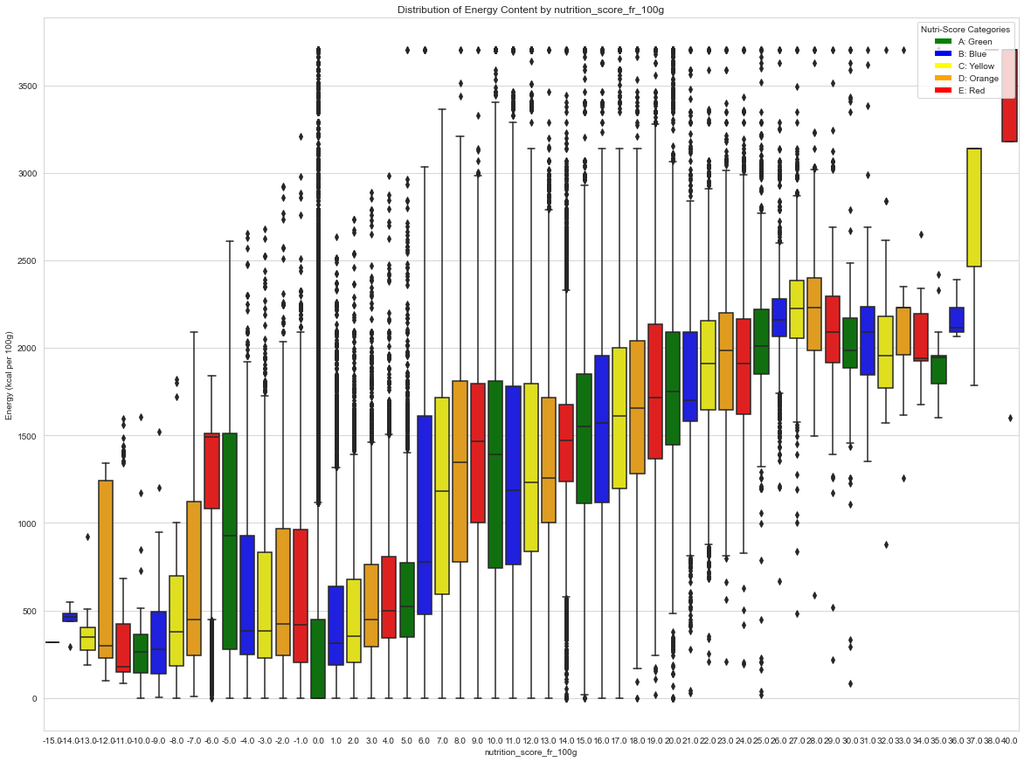

```python
import pandas as pd
import seaborn as sns
import matplotlib.pyplot as plt
from matplotlib.patches import Patch

# Construct the full path to the dataset
data_path = os.path.join(base_path, 'data', 'median_imputed_data.csv')

# Load your dataset with the low_memory option set to False to better handle mixed data types
df = pd.read_csv(data_path, low_memory=False)


# Ensure your data includes 'nutrition_score_fr_100g' and 'energy_100g' columns
# and drop rows with missing values
df = df[['nutrition_score_fr_100g', 'energy_100g']].dropna()

# Set the visual style of seaborn for better aesthetics
sns.set_style("whitegrid")

# Create the boxplot
plt.figure(figsize=(20,15))
boxplot = sns.boxplot(
    x='nutrition_score_fr_100g',
    y='energy_100g',
    data=df,
    palette=['green', 'blue', 'yellow', 'orange', 'red']  # Colors for Nutri-Scores A, B, C, D, E
)

# Create a legend for the colors, corresponding to Nutri-Score grades A, B, C, D, E
legend_labels = ['A: Green', 'B: Blue', 'C: Yellow', 'D: Orange', 'E: Red']
handles = [Patch(facecolor=color, label=label) for color, label in zip(['green', 'blue', 'yellow', 'orange', 'red'], legend_labels)]
plt.legend(handles=handles, title="Nutri-Score Categories", loc='upper right')

# Set the title and labels
plt.title('Distribution of Energy Content by nutrition_score_fr_100g')
plt.xlabel('nutrition_score_fr_100g')
plt.ylabel('Energy (kcal per 100g)')

# Display the plot
plt.show()
```

## Boxplot Analysis: Distribution of Energy Content by Nutri-Score Grade

### Interpretation Concerns

- **Scale and Units Misalignment**: The numerical values on the x-axis should ideally correspond to categorical Nutri-Score grades for accurate interpretation.
- **Possible Data Issues**: Unusual high and negative values suggest potential data quality issues that need to be addressed for reliable analysis.

### Suggestions for Improvement

1. **Data Verification**: Ensure data integrity by verifying and correcting Nutri-Score values and addressing anomalies in energy content.
2. **Plot Aesthetics**: Enhance plot aesthetics for better readability, including adjusting color contrast and font sizes.
3. **Analytical Approach**: Apply appropriate statistical techniques to handle outliers and interpret the distribution of energy content accurately.

### 7.3 Exploratory Data Analysis of Nutritional Information Across Nutrition Grades

```python
import pandas as pd
import seaborn as sns
import matplotlib.pyplot as plt
from ipywidgets import interact, Dropdown

# Assuming 'data' is your DataFrame and it's already loaded with appropriate data

# List of quantitative variables you want to explore
quantitative_vars = [
    'energy_100g', 'sugars_100g', 'saturated_fat_100g',
    'sodium_100g', 'fiber_100g', 'proteins_100g',
    'fruits_vegetables_nuts_100g', 'nutrition_score_fr_100g'
]

@interact
def interactive_boxplot(variable=Dropdown(options=quantitative_vars)):
    plt.figure(figsize=(15,10))
    ax = sns.boxplot(x="nutrition_grade_fr", y=variable, data=data, order=["a", "b", "c", "d", "e"])

    # Explicitly setting the color of all text elements and background for high contrast
    plt.rcParams['text.color'] = 'white'
    plt.rcParams['axes.labelcolor'] = 'white'
    plt.rcParams['xtick.color'] = 'white'
    plt.rcParams['ytick.color'] = 'white'
    plt.rcParams['axes.facecolor'] = '#303030'  # Dark background for better contrast
    plt.rcParams['figure.facecolor'] = '#303030'

    # Set the color and font size of title and labels directly using set_ methods
    ax.set_title(f'Distribution of {variable} across Nutrition Grades', fontsize=16)
    ax.set_xlabel('Nutrition Grade', fontsize=14)
    ax.set_ylabel(f'{variable} (units)', fontsize=14)

    # Improving tick parameters for better visibility
    ax.tick_params(axis='both', labelsize=12)  # Increase label size if needed

    plt.grid(True, linestyle='--', alpha=0.7)  # Add a grid with a light transparency for visibility
    plt.show()
```

```python
df.info()
```

```
<class 'pandas.core.frame.DataFrame'>
RangeIndex: 283629 entries, 0 to 283628
Data columns (total 2 columns):
 #   Column                   Non-Null Count   Dtype
---  ------                   --------------   -----
 0   nutrition_score_fr_100g  283629 non-null  float64
 1   energy_100g              283629 non-null  float64
dtypes: float64(2)
memory usage: 4.3 MB
```